# STAT5003 Evaluating National Quality Standard Rating Tiers

Group 02

# Introduction

Australian education and care services are assessed against the National Quality Standard (NQS) under the National Quality Framework by state and territory regulatory authorities (Australian Children's Education & Care Quality Authority [ACECQA], n.d.-a). ACECQA also publishes national registers containing information about services and providers (ACECQA, n.d.-b). Examining these records may provide useful information for regulatory planning, service improvement and policy research.

# Problem Framing & Research Question

This project is a multi-class classification task. Each observation represents an education and care service, and the outcome is its recorded NQS rating tier: Below NQS, Meeting NQS or Above NQS. Model predictions may support further investigation, but they cannot replace formal NQS assessments or establish causal relationships.

The research question is:

> To what extent can service type, service capacity, operating patterns, geographic location, and provider characteristics be used to classify an Australian education and care service’s recorded NQS rating tier as Below NQS, Meeting NQS, or Above NQS?

# Dataset & Justification

```r
source_dimensions <- read.csv('../outputs/source_dimensions.csv')
linkage_checks <- read.csv('../data/processed/acecqa_linkage_summary.csv')
analysis_data <- read.csv('../data/processed/acecqa_analysis.csv')
stopifnot(linkage_checks$value[linkage_checks$measure == 'Service rows unmatched to provider register'] == 0,
          !anyDuplicated(analysis_data$service_id),
          nrow(analysis_data) == 17160)
```

This project used two ACECQA national registers downloaded on 18 September 2026: the Education services register and the Approved providers register (ACECQA, n.d.-b). The services register contained 18,183 records and 98 variables, meeting the Large dataset requirement. The providers register contained 10,095 records and 10 variables. Missing ratings, capacity and operating schedules also made the data Messy.

Each observation represented a service. The two registers were linked by Provider Approval Number, meeting the Integrated dataset requirement. IDs were unique in their respective registers, and every service was matched to a provider. After removing 1,023 services without a rating, the final dataset contained 17,160 services from 6,885 providers and 28 candidate predictors. Using the published NQS rating levels (ACECQA, n.d.-a), we grouped ratings into three classes, meeting the Multi-class requirement: Significant Improvement Required and Working Towards NQS became Below NQS; Meeting NQS remained unchanged; and Exceeding NQS and Excellent became Above NQS.

# Exploratory Data Analysis (EDA)

## NQS Rating Distribution and Missing Values

The rating tiers were imbalanced: 74.3% of services were Meeting NQS, while 7.4% were Below NQS and 18.3% were Above NQS.

Missingness was high for schedule-specific weekly hours and may be related to which schedules a service offered. Approved capacity was missing for all 307 Family Day Care services. Maximum weekly hours were missing for 142 services; all recorded values were within 168 hours per week.

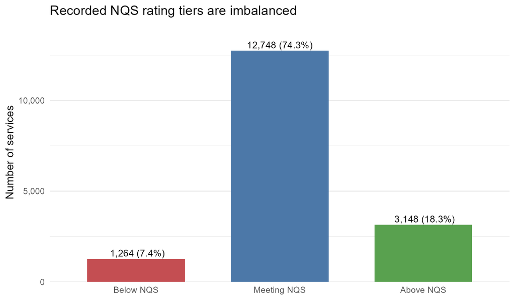

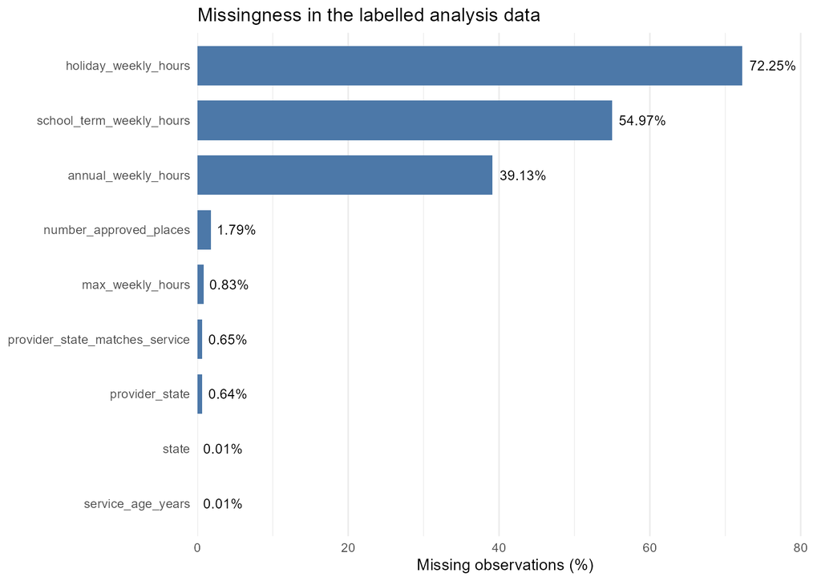

```r
rating_distribution <- read.csv('../outputs/rating_distribution.csv')
missingness <- read.csv('../outputs/missingness_selected.csv')
knitr::include_graphics(c('../figures/rating_tier_distribution.png',
                          '../figures/missingness_selected.png'))
```

*Rating-tier distribution and missingness in selected variables.*

## Categorical Variables

Centre-Based Care represented 98.2% of services. Standalone preschool, OSHC services, operating pattern and state showed the clearest relationships with rating tier. Standalone preschools and services without OSHC had a higher proportion of Above NQS ratings, although the groups still overlapped. The three OSHC variables were also strongly related to each other, and service state and provider state often contained similar information.

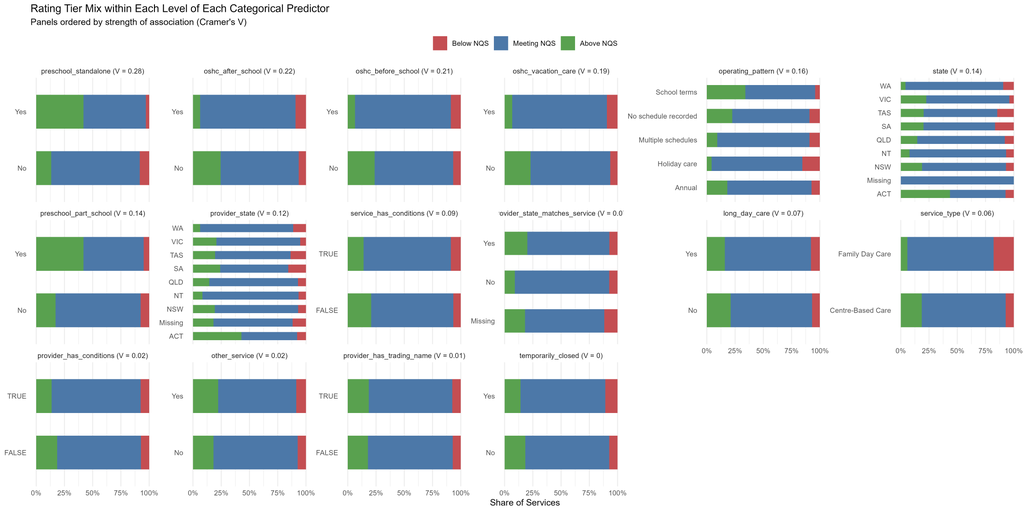

```r
categorical_counts <- read.csv('../outputs/categorical/categorical_vs_rating_crosstab.csv')
knitr::include_graphics('../figures/categorical_vs_rating_tier.png')
```

## Numerical and Operating Variables

Capacity and approval ages differed across rating tiers, but their distributions overlapped. Provider service count was strongly right-skewed: across service records, the median was 7 and the maximum was 611. Operating hours also differed by rating tier and service type. The Family Day Care group included only 18 Above NQS services, so comparisons within this group were less reliable. Most services (92.4%) recorded five open days per week.

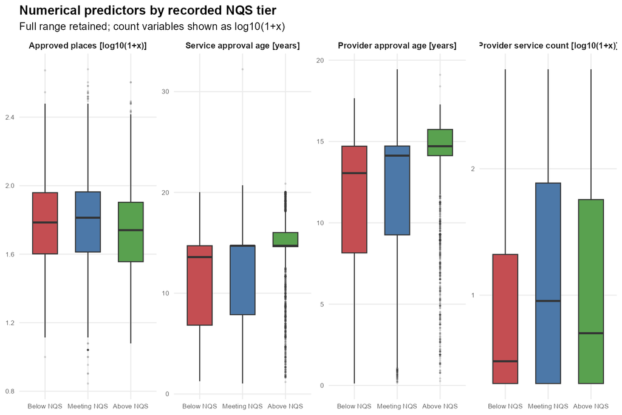

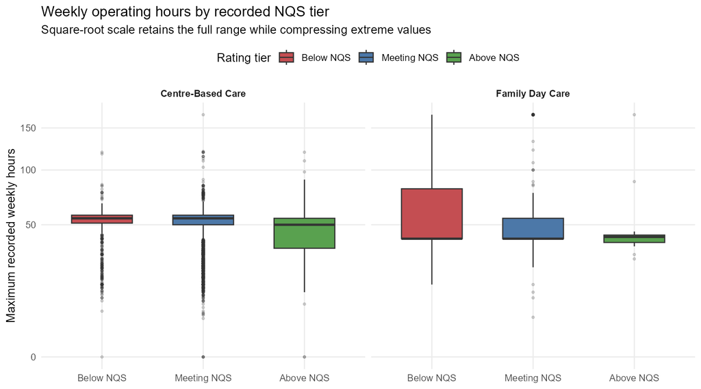

```r
numerical_summary <- read.csv('../outputs/numerical/by_tier.csv')
operating_summary <- read.csv('../outputs/operating/operating_by_tier.csv')
knitr::include_graphics(c('../figures/numerical_by_rating.png',
                          '../figures/operating_hours_by_rating.png'))
```

*Numerical predictors and weekly operating hours by rating tier.*

No single predictor clearly separated Below NQS, Meeting NQS and Above NQS services.

# Data Preprocessing

## Data Preparation and Splitting

Before splitting, approval dates and operating records were used to create age and operating-pattern variables. We also calculated provider service count and whether provider and service states matched. Service and provider IDs, the original rating and other rating-derived variables were excluded from model inputs.

Because a provider may operate several services, we split the data by provider, with approximately 80% for training and 20% for testing. The training set contained 13,497 services from 5,509 providers; the test set contained 3,663 services from 1,376 providers. Each provider’s most common rating tier was used for approximate stratification. Five-fold cross-validation also kept services from the same provider together. Preprocessing values were calculated using each fold’s training data and then applied to its validation data.

## Preprocessing Recipes

The shared preprocessing pipelines were implemented with `recipes` (Kuhn et al., 2026).

Missing values in numerical variables were replaced with the median calculated from the current training data. No separate missingness indicators were created for structural missing values. Missing values in categorical variables were labelled as Unknown. Categories that appeared for the first time in validation or test data were labelled as Novel. Categories representing less than 1% of the training data were grouped as Other.

Logical variables were converted to No/Yes categories, categorical variables were dummy encoded, and predictors with no or very little variation were removed.

kNN and SVM used the shared scaled recipe, which applied a $\log(x+1)$ transformation to provider_service_count and normalised numerical predictors. LDA used the same recipe and additionally removed linear combinations and numerical predictors with correlations above 0.9. Random Forest used the tree recipe, which also applied the log transformation but did not normalise numerical predictors.

MLR used a separate recipe with 19 selected predictors, normalisation and zero-variance removal. It did not apply the $\log(x+1)$ transformation to provider_service_count. Detailed code as follows.

```r
# Shared modelling workflow
# Creates the common outcome, predictor set, train/test split,
# resampling folds, preprocessing specification, and evaluation metrics.SS

required_packages <- c(
  "readr",
  "dplyr",
  "caret",
  "recipes"
)

missing_packages <- required_packages[
  !vapply(
    required_packages,
    requireNamespace,
    logical(1),
    quietly = TRUE
  )
]

if (length(missing_packages) > 0) {
  stop(
    "Install the following packages before running this script: ",
    paste(missing_packages, collapse = ", ")
  )
}

library(readr)
library(dplyr)
library(caret)
library(recipes)


model_data_raw <- read_csv(
  "data/processed/acecqa_analysis.csv",
  show_col_types = FALSE
)

required_columns <- c(
  "service_id",
  "provider_id",
  "rating_tier"
)

missing_columns <- setdiff(
  required_columns,
  names(model_data_raw)
)

if (length(missing_columns) > 0) {
  stop(
    "Required columns are missing: ",
    paste(missing_columns, collapse = ", ")
  )
}

model_data_raw <- model_data_raw |>
  mutate(
    rating_tier = factor(
      rating_tier,
      levels = c(
        "Below NQS",
        "Meeting NQS",
        "Above NQS"
      )
    )
  )

stopifnot(
  nrow(model_data_raw) > 0,
  !anyDuplicated(model_data_raw$service_id),
  !anyNA(model_data_raw$provider_id),
  !anyNA(model_data_raw$rating_tier)
)

# 80/20 train-test split

split_seed <- 5003L
training_fraction <- 0.80

# A provider may operate services in different rating tiers.
# Use its most frequent tier only as an approximate stratification label.
provider_split_frame <- model_data_raw |>
  count(provider_id, rating_tier, name = "n_services") |>
  group_by(provider_id) |>
  arrange(desc(n_services), rating_tier, .by_group = TRUE) |>
  slice(1L) |>
  ungroup() |>
  rename(provider_stratum = rating_tier)

set.seed(split_seed)

training_provider_rows <- createDataPartition(
  provider_split_frame$provider_stratum,
  p = training_fraction,
  list = FALSE
)

training_provider_ids <- provider_split_frame$provider_id[
  as.vector(training_provider_rows)
]

training_data <- model_data_raw |>
  filter(provider_id %in% training_provider_ids)

test_data <- model_data_raw |>
  filter(!(provider_id %in% training_provider_ids))

# Confirm that providers do not appear in both datasets.
stopifnot(
  length(intersect(
    unique(training_data$provider_id),
    unique(test_data$provider_id)
  )) == 0,
  nrow(training_data) + nrow(test_data) == nrow(model_data_raw)
)

# Inspect the realised split and outcome distributions.
split_distribution <- bind_rows(
  training_data |> mutate(split = "Training"),
  test_data |> mutate(split = "Test")
) |>
  count(split, rating_tier, name = "n_services") |>
  group_by(split) |>
  mutate(
    percentage = round(100 * n_services / sum(n_services), 1)
  ) |>
  ungroup()

print(split_distribution)



# Provider-grouped five-fold cross-validation



cv_seed <- 5004L
n_folds <- 5L

provider_cv_frame <- provider_split_frame |>
  filter(provider_id %in% training_provider_ids)

set.seed(cv_seed)

provider_validation_folds <- createFolds(
  provider_cv_frame$provider_stratum,
  k = n_folds,
  returnTrain = FALSE
)

# Convert provider-level folds into service-row indices.
cv_index_out <- lapply(
  provider_validation_folds,
  function(provider_rows) {
    validation_provider_ids <- provider_cv_frame$provider_id[provider_rows]

    which(training_data$provider_id %in% validation_provider_ids)
  }
)

# caret requires the complementary training indices.
all_training_rows <- seq_len(nrow(training_data))

cv_index <- lapply(
  cv_index_out,
  function(validation_rows) {
    setdiff(all_training_rows, validation_rows)
  }
)

names(cv_index) <- paste0("Fold", seq_len(n_folds))
names(cv_index_out) <- names(cv_index)

# Confirm that each service appears in exactly one validation fold
# and that no provider crosses training and validation within a fold.
stopifnot(
  all(
    tabulate(
      unlist(cv_index_out),
      nbins = nrow(training_data)
    ) == 1L
  )
)

for (fold_name in names(cv_index)) {
  analysis_providers <- unique(
    training_data$provider_id[cv_index[[fold_name]]]
  )

  validation_providers <- unique(
    training_data$provider_id[cv_index_out[[fold_name]]]
  )

  stopifnot(
    length(intersect(
      analysis_providers,
      validation_providers
    )) == 0
  )
}

cv_fold_summary <- bind_rows(
  lapply(
    names(cv_index_out),
    function(fold_name) {
      training_data[cv_index_out[[fold_name]], ] |>
        count(rating_tier, name = "n_services") |>
        mutate(fold = fold_name)
    }
  )
) |>
  group_by(fold) |>
  mutate(
    percentage = round(100 * n_services / sum(n_services), 1)
  ) |>
  ungroup() |>
  select(fold, rating_tier, n_services, percentage)

print(cv_fold_summary)

# -------------------------------------------------------------------
# Common outcome and predictor set
# -------------------------------------------------------------------

variable_dictionary <- read_csv(
  "data/processed/acecqa_variable_dictionary.csv",
  show_col_types = FALSE
)

predictor_names <- variable_dictionary |>
  filter(role == "Predictor") |>
  pull(variable)

missing_predictors <- setdiff(
  predictor_names,
  names(model_data_raw)
)

if (length(missing_predictors) > 0) {
  stop(
    "Predictor columns are missing: ",
    paste(missing_predictors, collapse = ", ")
  )
}

training_model_data <- training_data |>
  select(
    rating_tier,
    all_of(predictor_names)
  )

test_model_data <- test_data |>
  select(
    rating_tier,
    all_of(predictor_names)
  )

# Confirm that identifiers and rating-derived variables are excluded.
forbidden_predictors <- c(
  "service_id",
  "provider_id",
  "overall_rating_original"
)

stopifnot(
  !any(forbidden_predictors %in% names(training_model_data)),
  identical(
    names(training_model_data),
    names(test_model_data)
  ),
  ncol(training_model_data) == length(predictor_names) + 1L
)

cat(
  "\nOutcome: rating_tier",
  "\nNumber of predictors:", length(predictor_names),
  "\nTraining observations:", nrow(training_model_data),
  "\nTest observations:", nrow(test_model_data),
  "\n"
)

# -------------------------------------------------------------------
# Fold-wise preprocessing specifications
# -------------------------------------------------------------------

logical_predictors <- variable_dictionary |>
  filter(
    role == "Predictor",
    type == "Logical"
  ) |>
  pull(variable)

# Convert logical predictors using fixed, predefined levels.
training_model_data <- training_model_data |>
  mutate(
    across(
      all_of(logical_predictors),
      ~ factor(
        .x,
        levels = c(FALSE, TRUE),
        labels = c("No", "Yes")
      )
    )
  )

test_model_data <- test_model_data |>
  mutate(
    across(
      all_of(logical_predictors),
      ~ factor(
        .x,
        levels = c(FALSE, TRUE),
        labels = c("No", "Yes")
      )
    )
  )

# Operations shared by all five models.
base_recipe <- recipe(
  rating_tier ~ .,
  data = training_model_data
) |>
  step_string2factor(
    all_nominal_predictors()
  ) |>
  step_unknown(
    all_nominal_predictors(),
    new_level = "Unknown"
  ) |>
  step_novel(
    all_nominal_predictors(),
    new_level = "Novel"
  ) |>
  step_other(
    all_nominal_predictors(),
    threshold = 0.01,
    other = "Other"
  ) |>
  step_impute_median(
    all_numeric_predictors()
  ) |>
  step_log(
    provider_service_count,
    offset = 1
  )

# For multinomial logistic regression, LDA, kNN and SVM.
scaled_recipe <- base_recipe |>
  step_normalize(
    all_numeric_predictors()
  ) |>
  step_dummy(
    all_nominal_predictors()
  ) |>
  step_nzv(
    all_predictors()
  )

# For Random Forest, where scaling is unnecessary.
tree_recipe <- base_recipe |>
  step_dummy(
    all_nominal_predictors()
  ) |>
  step_nzv(
    all_predictors()
  )

print(scaled_recipe)
print(tree_recipe)

# -------------------------------------------------------------------
# Shared evaluation function and caret resampling control
# -------------------------------------------------------------------

macro_f1_summary <- function(data, lev = NULL, model = NULL) {
  if (is.null(lev)) {
    lev <- levels(data$obs)
  }

  f1_by_class <- vapply(
    lev,
    function(class_name) {
      true_positive <- sum(
        data$pred == class_name &
          data$obs == class_name
      )

      false_positive <- sum(
        data$pred == class_name &
          data$obs != class_name
      )

      false_negative <- sum(
        data$pred != class_name &
          data$obs == class_name
      )

      precision_denominator <- true_positive + false_positive
      recall_denominator <- true_positive + false_negative

      precision <- if (precision_denominator == 0) {
        0
      } else {
        true_positive / precision_denominator
      }

      recall <- if (recall_denominator == 0) {
        0
      } else {
        true_positive / recall_denominator
      }

      if (precision + recall == 0) {
        0
      } else {
        2 * precision * recall / (precision + recall)
      }
    },
    numeric(1)
  )

  recall_by_class <- vapply(
    lev,
    function(class_name) {
      denominator <- sum(data$obs == class_name)

      if (denominator == 0) {
        0
      } else {
        sum(
          data$pred == class_name &
            data$obs == class_name
        ) / denominator
      }
    },
    numeric(1)
  )

  names(recall_by_class) <- paste0(
    "Recall_",
    make.names(lev)
  )

  c(
    Macro_F1 = mean(f1_by_class),
    Accuracy = mean(data$pred == data$obs),
    recall_by_class
  )
}

model_control <- trainControl(
  method = "cv",
  number = n_folds,
  index = cv_index,
  indexOut = cv_index_out,
  classProbs = FALSE,
  summaryFunction = macro_f1_summary,
  savePredictions = "final",
  returnResamp = "final",
  allowParallel = TRUE
)

# Check the evaluation function using a majority-class baseline.
majority_class <- names(
  which.max(
    table(training_model_data$rating_tier)
  )
)

baseline_check <- data.frame(
  obs = training_model_data$rating_tier,
  pred = factor(
    rep(
      majority_class,
      nrow(training_model_data)
    ),
    levels = levels(training_model_data$rating_tier)
  )
)

baseline_metrics <- macro_f1_summary(
  baseline_check,
  lev = levels(training_model_data$rating_tier)
)

print(baseline_metrics)


fold1_training <- training_model_data[
  cv_index[["Fold1"]],
  ,
  drop = FALSE
]

fold1_validation <- training_model_data[
  cv_index_out[["Fold1"]],
  ,
  drop = FALSE
]

# Learn preprocessing parameters from Fold 1 training data only.
scaled_recipe_check <- prep(
  scaled_recipe,
  training = fold1_training
)

tree_recipe_check <- prep(
  tree_recipe,
  training = fold1_training
)

# Apply the learned parameters to Fold 1 validation data.
scaled_validation_check <- bake(
  scaled_recipe_check,
  new_data = fold1_validation
)

tree_validation_check <- bake(
  tree_recipe_check,
  new_data = fold1_validation
)

stopifnot(
  nrow(scaled_validation_check) == nrow(fold1_validation),
  nrow(tree_validation_check) == nrow(fold1_validation),
  !anyNA(scaled_validation_check),
  !anyNA(tree_validation_check)
)

cat(
  "Scaled recipe output:",
  nrow(scaled_validation_check), "rows ×",
  ncol(scaled_validation_check), "columns\n",
  "Tree recipe output:",
  nrow(tree_validation_check), "rows ×",
  ncol(tree_validation_check), "columns\n"
)
```

# Model Fitting & Improvement

## Linear Discriminant Analysis

### Preprocessing

In addition to the shared `scaled_recipe`, the recipe used for Linear Discriminant Analysis (LDA) also further remove linear dependencies among numeric predictors and dropped predictors correlated above a `0.9` threshold.

### Models

Two models of LDA were trained, one using the unchanged training set’s class proportion (`lda_fit_emp`) and one using equal class priors to account for the class imbalance of the dataset (`lda_fit_equal`).

For both models, we also performed parameter tuning on `dimen` — the number of discriminant functions produced. This is limited by the number of classes, resulting in only 2 possible tuning values.

Only one LDA model is included in the final model selection. Due to similar Macro F1 score for both models, `lda_fit_equal` was chosen due to its better Recall score for `Below NQS`. Additionally, both model performed better with `dimen=2`.

```r
lda_prior_comparison <- read.csv("../outputs/lda/lda_prior_comparison.csv") |>
  select(priors, dimen, Macro_F1, Macro_F1SD, Accuracy, starts_with("Recall_")) |>
  mutate(across(c(Macro_F1, Macro_F1SD, Accuracy, starts_with("Recall_")), ~ round(.x,4))) |>
  select(1:8) |>
  arrange(dimen)
knitr::kable(lda_prior_comparison)
```

| priors | dimen | Macro_F1 | Macro_F1SD | Accuracy | Recall_Below.NQS | Recall_Meeting.NQS | Recall_Above.NQS |
| --- | --- | --- | --- | --- | --- | --- | --- |
| Empirical | 1 | 0.4101 | 0.0200 | 0.7428 | 0.0000 | 0.9278 | 0.3133 |
| Equal | 1 | 0.3758 | 0.0077 | 0.4010 | 0.5952 | 0.3173 | 0.6461 |
| Empirical | 2 | 0.4278 | 0.0162 | 0.7396 | 0.0299 | 0.9199 | 0.3158 |
| Equal | 2 | 0.4364 | 0.0189 | 0.5106 | 0.5253 | 0.4833 | 0.6011 |

### Full model implementation

Model implementation was done in a separate R script `model_LDA.R` for purpose of organization with steps as described above. It depends on the shared workflow in `R/06_model_setup.R`. The code is displayed without rerunning the full search during report rendering.

```r
required_packages <- c(
  "readr",
  "dplyr",
  "tidyr",
  "caret",
  "recipes",
  "ggplot2"
)

missing_packages <- required_packages[
  !vapply(
    required_packages,
    requireNamespace,
    logical(1),
    quietly = TRUE
  )
]

if (length(missing_packages) > 0) {
  stop(
    "Install the following packages before running this script: ",
    paste(missing_packages, collapse = ", ")
  )
}

library(readr)
library(dplyr)
library(caret)
library(recipes)
library(ggplot2)
select <- dplyr::select

if (!exists("scaled_recipe")) {source("R/06_model_setup.R")}
dir.create("outputs/lda", recursive = TRUE, showWarnings = FALSE)
dir.create("figures", showWarnings = FALSE)

# Training Model

lda_recipe <- scaled_recipe %>% # Additional pre-processing
  step_lincomb(all_numeric_predictors()) %>%
  step_corr(all_numeric_predictors(), threshold = 0.9)

lda_fit_equal <- train(
  lda_recipe,
  data = training_model_data,
  trControl = model_control,
  method = "lda2",
  metric = "Macro_F1",
  tuneGrid = expand.grid(dimen = 1:2), # Only 2 possible values for hyperparam tuning
  prior = rep(1/3, 3) # Equal class priors
)

lda_fit_emp <- train(
  lda_recipe,
  data = training_model_data,
  trControl = model_control,
  method = "lda2",
  metric = "Macro_F1",
  tuneGrid = expand.grid(dimen = 1:2) # Empirical priors (training class proportions)
)

# Performance on data (cross-validation only)
## With vs. Without Class Priors
### Side by side
lda_prior_comparison <- bind_rows(
  lda_fit_emp$results   |> mutate(priors = "Empirical"),
  lda_fit_equal$results |> mutate(priors = "Equal")
)

print(lda_prior_comparison)

### Per-fold comparison
lda_fold_comparison <- bind_rows(
  lda_fit_emp$resample   |> mutate(priors = "Empirical"),
  lda_fit_equal$resample |> mutate(priors = "Equal")
)

lda_fold_comparison %>%
  group_by(priors) %>%
  summarise(
    mean_macro_f1 = mean(Macro_F1),
    sd_macro_f1   = sd(Macro_F1),
    .groups = "drop"
  )

### Paired difference per fold (equal - emp)
lda_paired_diff <- lda_fold_comparison %>%
  select(Resample, priors, Macro_F1) %>%
  tidyr::pivot_wider(names_from = priors, values_from = Macro_F1) %>%
  mutate(diff = `Equal` - `Empirical`)
print(lda_paired_diff)

## Out-of-fold predictions for the chosen dimen
lda_tier_levels <- levels(training_model_data$rating_tier)

lda_oof <- lda_fit_equal$pred
if ("dimen" %in% names(lda_oof)) {
  lda_oof <- lda_oof %>% filter(dimen == lda_fit_equal$bestTune$dimen)
}
stopifnot(nrow(lda_oof) == nrow(training_model_data))   # one prediction per service

lda_oof_df <- data.frame(obs = lda_oof$obs, pred = lda_oof$pred)

lda.train.confusion <- confusionMatrix(data = lda_oof_df$pred, reference = lda_oof_df$obs)
lda.train.confusion

# Evaluations (cross-validation only)

## Overall metrics: CV (fold mean) and CV (pooled out-of-fold)
lda_best_row <- lda_fit_equal$results %>% filter(dimen == lda_fit_equal$bestTune$dimen)

lda_overall <- bind_rows(
  data.frame(split = "CV (mean of folds)",
             t(unlist(lda_best_row[, c("Macro_F1", "Accuracy")]))),
  data.frame(split = "CV (pooled out-of-fold)",
             t(macro_f1_summary(lda_oof_df, lev = lda_tier_levels)[c("Macro_F1", "Accuracy")]))
)
print(lda_overall)

## Per-class precision / recall / F1
lda_per_class <- function(cm, split) {
  bc <- as.data.frame(cm$byClass)
  bc$class <- sub("^Class: ", "", rownames(bc))
  bc$split <- split
  bc[, c("split", "class", "Precision", "Recall", "F1")]
}

lda_class_metrics <- lda_per_class(lda.train.confusion, "CV (out-of-fold)")
print(lda_class_metrics)

## Baseline vs LDA (majority class per fold, scored on the same validation folds)
fold_baseline <- function(fold) {
  majority <- names(which.max(table(training_model_data$rating_tier[cv_index[[fold]]])))
  rows <- cv_index_out[[fold]]
  d <- data.frame(
    obs  = training_model_data$rating_tier[rows],
    pred = factor(rep(majority, length(rows)), levels = lda_tier_levels)
  )
  as.data.frame(t(macro_f1_summary(d, lev = lda_tier_levels)))
}

lda_vs_baseline <- bind_rows(
  `Majority baseline`  = colMeans(bind_rows(lapply(names(cv_index_out), fold_baseline))),
  `LDA (empirical)`    = unlist(lda_fit_emp$results[lda_fit_emp$results$dimen == lda_fit_emp$bestTune$dimen, ]),
  `LDA (equal priors)` = unlist(lda_fit_equal$results[lda_fit_equal$results$dimen == lda_fit_equal$bestTune$dimen, ]),
  .id = "model"
) |>
  dplyr::select(model, Macro_F1, Accuracy, starts_with("Recall_")) |>
  tidyr::pivot_longer(-model, names_to = "metric") |>
  tidyr::pivot_wider(names_from = model)

print(lda_vs_baseline)

## Plots
lda_plot_cm <- function(cm, title) {
  df <- as.data.frame(cm$table) %>%
    group_by(Reference) %>%
    mutate(row_pct = 100 * Freq / sum(Freq)) %>%
    ungroup()

  ggplot(df, aes(Prediction, Reference, fill = row_pct)) +
    geom_tile(colour = "white") +
    geom_text(aes(label = paste0(Freq, "\n(", round(row_pct, 1), "%)")), size = 4) +
    scale_fill_gradient(low = "white", high = "steelblue", name = "% of true class") +
    scale_y_discrete(limits = rev(levels(df$Reference))) +
    labs(title = title, x = "Predicted rating", y = "Actual rating") +
    coord_fixed() +
    theme_minimal()
}

lda.train.plot <- lda_plot_cm(lda.train.confusion, "LDA Cross-Validated Predictions")

lda.metric.plot <- lda_class_metrics %>%
  tidyr::pivot_longer(c(Precision, Recall, F1), names_to = "metric", values_to = "value") %>%
  mutate(class = factor(class, levels = lda_tier_levels)) %>%
  ggplot(aes(class, value)) +
  geom_col(fill = "steelblue", width = 0.7) +
  facet_wrap(~ metric) +
  scale_y_continuous(limits = c(0, 1)) +
  labs(title = "LDA per-class metrics", x = NULL, y = NULL) +
  theme_minimal() +
  theme(axis.text.x = element_text(angle = 30, hjust = 1))

# Saved outputs
write_csv(lda_prior_comparison,      "outputs/lda/lda_prior_comparison.csv")
write_csv(lda_class_metrics,         "outputs/lda/lda_class_metrics.csv")
write_csv(lda_fit_equal$resample,    "outputs/lda/lda_cv_fold_metrics.csv")
ggsave("figures/lda_train_cm.png",      lda.train.plot,  width = 8, height = 8, dpi = 220)
ggsave("figures/lda_class_metrics.png", lda.metric.plot, width = 8, height = 6, dpi = 220)

message("Completed.")
```

## kNN

### Model rationale and fitting

K-nearest neighbours (KNN) was included to assess whether services with similar administrative and provider profiles tend to share an NQS rating tier. The overlap between individual numerical predictors observed in EDA motivates considering their combined local structure. KNN assigns a class using nearby training observations, allowing nonlinear decision boundaries without specifying a parametric form (Schliep & Hechenbichler, 2025). Below NQS, Meeting NQS and Above NQS were treated as nominal classes; their ordering was not explicitly modelled.

The common provider-grouped split contained **13,497 training services** and **3,663 held-out services**. KNN used the same five provider-grouped training folds as the other candidate models, keeping services from each provider together. This reduces leakage from shared provider characteristics and evaluates transfer to providers absent from the corresponding training partition. Identifiers and rating-derived fields were excluded.

The shared `recipes` preprocessing pipeline (Kuhn et al., 2026) handled missing and novel categorical levels, pooled levels below 1%, median-imputed numerical predictors, and log(1+x)-transformed provider service count. Numerical predictors were standardised before categorical dummy encoding, followed by near-zero-variance filtering. Scaling prevents variables measured in larger units from dominating Euclidean distances. Dummy columns were not subsequently standardised. Crucially, preprocessing parameters were estimated separately within each fold’s training partition and then applied to validation data. The `kknn` engine’s additional scaling was disabled (Schliep & Hechenbichler, 2025).

### Hyperparameter tuning and improvement

We compared ten neighbour counts, **k = 3, 5, 9, 15, 25, 41, 61, 81, 121 and 161**, using rectangular (equal) and triangular (distance-weighted) voting: 20 configurations across five folds. Small k permits more local variation, whereas larger k smooths the decision boundary and can favour the dominant class. Triangular voting was tested to give closer neighbours greater influence; it is not class weighting. No class rebalancing was applied. The code expands the search if the overall optimum reaches the largest k; this was unnecessary for the observed optimum.

Selection maximised the **unweighted mean fold Macro-F1**, the arithmetic mean of the three class F1 scores within each fold. This gives each tier equal evaluation weight despite Meeting NQS comprising 73.7% of training services. Exact ties were resolved by larger k, then alphabetical kernel order.

KNN tuning: best configuration for each kernel on the five shared provider-grouped folds.

| Voting kernel | Best k | Mean Macro-F1 | Fold SD | Mean accuracy |
| --- | --- | --- | --- | --- |
| rectangular | 5 | 0.425 | 0.025 | 0.722 |
| triangular | 5 | 0.417 | 0.012 | 0.690 |

The selected configuration was **k = 5, equal voting, Euclidean distance**. Its mean Macro-F1 was **0.425 (fold SD 0.025)**, compared with **0.417** for the best triangular configuration, also at k = 5. The difference of 0.008 is descriptive and does not establish statistical superiority. Triangular voting increased mean fold Below NQS recall from 0.044 to 0.067 but reduced Meeting NQS recall from 0.896 to 0.850; the pre-specified Macro-F1 rule therefore retained equal voting.

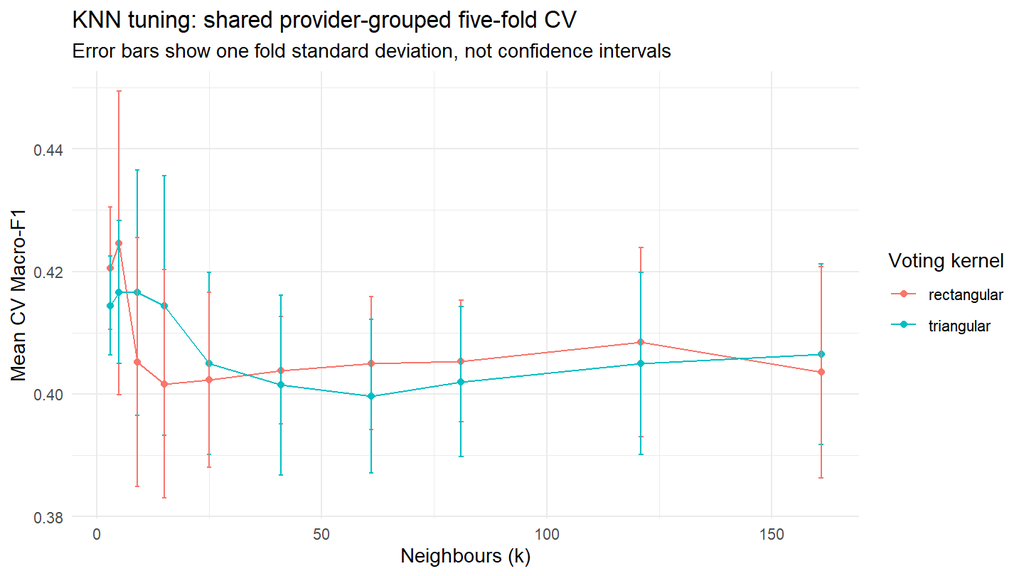

KNN tuning on the shared training folds. Error bars represent one fold standard deviation, not confidence intervals.

### Validation results and interpretation

The majority-class baseline achieved mean fold Macro-F1 **0.283** and accuracy **0.737**. KNN improved Macro-F1 by **0.142**, while accuracy fell to **0.722**. This trade-off occurs because Macro-F1 weights classes equally, whereas accuracy is dominated by the number of Meeting NQS observations.

Selected KNN: class metrics from pooled out-of-fold predictions, not held-out test predictions.

| Actual tier | Support | Precision | Recall | F1 |
| --- | --- | --- | --- | --- |
| Below NQS | 1016 | 0.206 | 0.044 | 0.073 |
| Meeting NQS | 9954 | 0.771 | 0.897 | 0.829 |
| Above NQS | 2527 | 0.461 | 0.310 | 0.371 |

Only **45 of 1,016 Below NQS services** were correctly identified (recall 0.044); **923** were classified as Meeting NQS. For Above NQS, **784 of 2,527** were identified (recall 0.310), while **1,725** were classified as Meeting NQS. Meeting NQS recall was 0.897. Thus, local profile similarity provides some classification signal but does not reliably distinguish the minority tiers. In particular, the very low Below NQS recall limits usefulness for identifying services that may require additional support or regulatory attention.

The class table pools out-of-fold predictions, giving pooled Macro-F1 **0.424**; this differs slightly from mean fold Macro-F1 **0.425** because fold sizes and distributions differ. The same folds were used for tuning and performance reporting, so these are internal estimates subject to selection optimism. **KNN was not evaluated on the held-out test set.** In the repository’s common comparison, MLR achieved mean CV Macro-F1 0.4871 and was selected before test scoring; KNN was therefore not the final model.

### Limitations and reproducibility

Euclidean distances remain sensitive to redundant predictors and reference-level dummy coding. Median imputation may also obscure structural missingness, and this nominal classifier does not use the tiers’ ordering. Future work could compare reduced feature groups or mixed-data distances within training resampling, with particular attention to Below NQS recall. The administrative snapshot supports association-based classification, not causal claims or validated forecasts of future ratings.

All displayed results are loaded from the supplied repository outputs. To regenerate tuning results and figures, run the following from the repository root; the report itself reads saved results to avoid repeating the full search during knitting.

```r
source("R/07_knn_install.R")
source("R/07_knn.R")
```

### Full KNN implementation

The complete KNN script is displayed below. It includes fold-wise preprocessing, hyperparameter tuning, out-of-fold evaluation, leakage checks and output generation. It depends on the shared workflow in `R/06_model_setup.R`. The code is displayed without rerunning the full search during report rendering. To regenerate the results, run `source("R/07_knn.R")` from the repository root.

```r
# Run from the repository root. Uses the group's exact provider split/folds.
# Test outcomes are deliberately not evaluated during model development.
required_files <- c("R/06_model_setup.R", "data/processed/acecqa_analysis.csv",
                    "data/processed/acecqa_variable_dictionary.csv")
if (!all(file.exists(required_files))) {
  stop("Run from the group repository root with shared setup and processed CSV files present.")
}
if (dir.exists(".R-library")) .libPaths(c(normalizePath(".R-library"), .libPaths()))
source("R/06_model_setup.R")
if (!requireNamespace("kknn", quietly = TRUE)) stop("Install package kknn first.")
dir.create("outputs/knn", recursive = TRUE, showWarnings = FALSE)
dir.create("figures", showWarnings = FALSE)
out <- "outputs/knn"
set.seed(5005)

# Audit the shared split and model inputs without using test outcomes for tuning.
stopifnot(length(intersect(training_data$provider_id, test_data$provider_id)) == 0L,
          identical(training_model_data$rating_tier, training_data$rating_tier),
          !any(grepl("(^|_)(rating|quality|qa[1-7])(_|$)|^service_id$|^provider_id$",
                     predictor_names, ignore.case = TRUE)),
          length(cv_index) == 5L, identical(names(cv_index), names(cv_index_out)))
audit_rows <- list()
for (f in names(cv_index)) {
  a <- cv_index[[f]]; v <- cv_index_out[[f]]
  stopifnot(length(intersect(a, v)) == 0L,
            setequal(c(a, v), seq_len(nrow(training_model_data))),
            length(intersect(training_data$provider_id[a], training_data$provider_id[v])) == 0L,
            all(table(training_model_data$rating_tier[a]) > 0),
            all(table(training_model_data$rating_tier[v]) > 0))
  audit_rows[[f]] <- data.frame(fold = f, training_rows = length(a), validation_rows = length(v),
    provider_overlap = 0L, all_classes_present = TRUE)
}
readr::write_csv(dplyr::bind_rows(audit_rows), file.path(out, "leakage_audit.csv"))

# Preprocess separately inside each shared training fold. kknn's internal
# scaling is disabled because the shared recipe already scales numerics.
fold_data <- lapply(names(cv_index), function(f) {
  rec <- recipes::prep(scaled_recipe, training = training_model_data[cv_index[[f]], ])
  list(train = recipes::bake(rec, new_data = training_model_data[cv_index[[f]], ]),
       valid = recipes::bake(rec, new_data = training_model_data[cv_index_out[[f]], ]))
})
names(fold_data) <- names(cv_index)
stopifnot(all(vapply(fold_data, function(x) !anyNA(x$train) && !anyNA(x$valid), logical(1))))
stopifnot(all(vapply(fold_data, function(x) {
  identical(names(x$train), names(x$valid)) &&
    all(vapply(x$train[setdiff(names(x$train), "rating_tier")], is.numeric, logical(1)))
}, logical(1))))

grid <- expand.grid(k = c(3L, 5L, 9L, 15L, 25L, 41L, 61L, 81L, 121L, 161L),
                    kernel = c("rectangular", "triangular"), stringsAsFactors = FALSE)
results <- list()
predictions <- list()
evaluate_grid <- function(candidates) {
  for (i in seq_len(nrow(candidates))) {
    k <- candidates$k[i]; kernel <- candidates$kernel[i]
    for (f in names(fold_data)) {
      message("k=", k, ", kernel=", kernel, ", ", f)
      x <- fold_data[[f]]
      fit <- kknn::kknn(rating_tier ~ ., train = as.data.frame(x$train),
                        test = as.data.frame(x$valid), k = k, distance = 2,
                        kernel = kernel, scale = FALSE)
      pred <- factor(fit$fitted.values, levels = levels(training_model_data$rating_tier))
      obs <- x$valid$rating_tier
      metrics <- macro_f1_summary(data.frame(obs = obs, pred = pred))
      results[[length(results) + 1L]] <<- data.frame(k = k, kernel = kernel, fold = f,
                                                   as.list(metrics), check.names = FALSE)
      predictions[[length(predictions) + 1L]] <<- data.frame(k = k, kernel = kernel,
        fold = f, rowIndex = cv_index_out[[f]], obs = obs, pred = pred)
    }
  }
}
summarise_grid <- function() {
  dplyr::bind_rows(results) |>
    dplyr::group_by(k, kernel) |>
    dplyr::summarise(Macro_F1SD = sd(Macro_F1), Macro_F1 = mean(Macro_F1),
                     AccuracySD = sd(Accuracy), Accuracy = mean(Accuracy), .groups = "drop") |>
    dplyr::arrange(dplyr::desc(Macro_F1), dplyr::desc(k), kernel)
}
evaluate_grid(grid)
summary <- summarise_grid()
# Expand an upper-bound optimum while keeping k valid for every fold.
max_k <- min(vapply(fold_data, function(x) nrow(x$train) - 2L, integer(1)))
while (summary$k[1] == max(grid$k) && max(grid$k) < max_k) {
  next_k <- min(2L * max(grid$k) + 1L, max_k)
  extra <- expand.grid(k = next_k, kernel = c("rectangular", "triangular"), stringsAsFactors = FALSE)
  evaluate_grid(extra)
  grid <- rbind(grid, extra)
  summary <- summarise_grid()
}
best <- summary[1, ]
fold_results <- dplyr::bind_rows(results)
stopifnot(!anyNA(summary), all(table(fold_results$k, fold_results$kernel) == n_folds))
# Compare the best configuration within each kernel using mean fold metrics.
# Recall is averaged across folds, not calculated from pooled predictions.
kernel_winners <- summary |>
  dplyr::group_by(kernel) |>
  dplyr::slice_head(n = 1L) |>
  dplyr::ungroup()
mean_recalls <- fold_results |>
  dplyr::group_by(k, kernel) |>
  dplyr::summarise(dplyr::across(dplyr::starts_with("Recall_"), mean), .groups = "drop")
kernel_comparison <- dplyr::left_join(kernel_winners, mean_recalls, by = c("k", "kernel"))
readr::write_csv(kernel_comparison, file.path(out, "kernel_comparison.csv"))
all_predictions <- dplyr::bind_rows(predictions)
oof <- all_predictions[all_predictions$k == best$k & all_predictions$kernel == best$kernel, ]
oof <- oof[order(oof$rowIndex), ]
stopifnot(identical(oof$rowIndex, seq_len(nrow(training_model_data))))
oof$service_id <- training_data$service_id[oof$rowIndex]
oof$provider_id <- training_data$provider_id[oof$rowIndex]

class_metrics <- function(obs, pred) {
  do.call(rbind, lapply(levels(obs), function(cl) {
    tp <- sum(obs == cl & pred == cl); fp <- sum(obs != cl & pred == cl)
    fn <- sum(obs == cl & pred != cl)
    data.frame(class = cl, support = sum(obs == cl),
      Precision = if (tp + fp == 0) 0 else tp / (tp + fp),
      Recall = if (tp + fn == 0) 0 else tp / (tp + fn),
      F1 = if (2 * tp + fp + fn == 0) 0 else 2 * tp / (2 * tp + fp + fn))
  }))
}
classes <- class_metrics(oof$obs, oof$pred)
cm <- table(Actual = oof$obs, Predicted = oof$pred)
baseline <- dplyr::bind_rows(lapply(names(cv_index), function(f) {
  majority <- names(which.max(table(training_model_data$rating_tier[cv_index[[f]]])))
  obs <- training_model_data$rating_tier[cv_index_out[[f]]]
  pred <- factor(rep(majority, length(obs)), levels = levels(obs))
  data.frame(fold = f, as.list(macro_f1_summary(data.frame(obs = obs, pred = pred))))
}))
readr::write_csv(summary, file.path(out, "cv_summary.csv"))
readr::write_csv(fold_results, file.path(out, "cv_fold_metrics.csv"))
readr::write_csv(oof, file.path(out, "selected_oof_predictions.csv"))
readr::write_csv(classes, file.path(out, "class_metrics.csv"))
readr::write_csv(as.data.frame(cm), file.path(out, "confusion_matrix.csv"))
readr::write_csv(baseline, file.path(out, "baseline_cv.csv"))
readr::write_csv(best, file.path(out, "best_parameters.csv"))
readr::write_csv(split_distribution, file.path(out, "split_distribution.csv"))
readr::write_csv(cv_fold_summary, file.path(out, "fold_distribution.csv"))
readr::write_csv(data.frame(service_id = training_data$service_id,
  provider_id = training_data$provider_id, fold = oof$fold), file.path(out, "training_folds.csv"))

p <- ggplot2::ggplot(summary, ggplot2::aes(k, Macro_F1, colour = kernel)) +
  ggplot2::geom_line() + ggplot2::geom_point() +
  ggplot2::geom_errorbar(ggplot2::aes(ymin = Macro_F1 - Macro_F1SD,
                                    ymax = Macro_F1 + Macro_F1SD), width = 1) +
  ggplot2::labs(x = "Neighbours (k)", y = "Mean CV Macro-F1", colour = "Voting kernel",
    title = "KNN tuning: shared provider-grouped five-fold CV",
    subtitle = "Error bars show one fold standard deviation, not confidence intervals") +
  ggplot2::theme_minimal(base_size = 11)
ggplot2::ggsave("figures/knn_tuning.png", p, width = 8, height = 4.5, dpi = 180)
cm_plot <- as.data.frame(cm)
cm_plot$proportion <- as.vector(prop.table(cm, 1))
p2 <- ggplot2::ggplot(cm_plot, ggplot2::aes(Predicted, Actual, fill = proportion)) +
  ggplot2::geom_tile() +
  ggplot2::geom_text(ggplot2::aes(label = sprintf("%d\n%.1f%%", Freq, 100 * proportion))) +
  ggplot2::scale_fill_gradient(low = "white", high = "#58A6C8", limits = c(0, 1)) +
  ggplot2::labs(title = "Selected KNN: pooled out-of-fold predictions", fill = "Row share") +
  ggplot2::theme_minimal(base_size = 11)
ggplot2::ggsave("figures/knn_confusion.png", p2, width = 7, height = 4.5, dpi = 180)

# Save training data and a full-training recipe for later locked evaluation.
# The future prediction uses this exact training reference and preprocessing.
final_recipe <- recipes::prep(scaled_recipe, training = training_model_data)
final_train <- recipes::bake(final_recipe, new_data = training_model_data)
saveRDS(list(recipe = final_recipe, train = final_train, k = best$k,
             kernel = best$kernel, distance = 2, scale = FALSE,
             levels = levels(training_model_data$rating_tier)), file.path(out, "knn_model.rds"))
writeLines(capture.output(sessionInfo()), file.path(out, "session_info.txt"))
message("Completed. Test set was not evaluated. Selected configuration:")
print(best)
```

## MLR

### Model fitting and rationale

Multinomial logistic regression (MLR) was fitted as an interpretable linear model for the three rating tiers. We used ridge-regularised multinomial regression (`glmnet`, `alpha = 0`; Friedman et al., 2010) to stabilise estimation in the presence of related service and provider characteristics. MLR used the 19-predictor recipe described in *Preprocessing Recipes*, including within-fold median imputation, missing/novel-category handling, dummy encoding, zero-variance removal and normalisation. Unlike the kNN/SVM recipe, it did not log-transform `provider_service_count`. The service and provider identifiers and rating-derived fields were excluded from model inputs.

To avoid information leakage, preprocessing was estimated separately within each training fold. As described above, the other candidate models used the group’s provider-grouped 80/20 train/test split and five shared provider-grouped cross-validation (CV) folds on the training set. The MLR tuning reported in this section was first run on its own provider-grouped split, which differed from the group’s shared split. The MLR was therefore rerun on the shared split before model selection (see *Selected model and test evaluation*). The held-out test partition was not used to tune the MLR.

### MLR refinement and tuning

Because **Meeting NQS accounted for 74.3%** of the services, an unweighted model could achieve high accuracy while overlooking smaller classes. We therefore assessed six ridge penalty values ($\lambda \in \{0.001, 0.003, 0.01, 0.03, 0.1, 0.3\}$) and three weighting schemes (no weights, square-root inverse-frequency weights and capped inverse-frequency weights): **18 configurations** in total. Each was evaluated on the same five provider-grouped folds, with mean **macro-F1** as the primary selection metric. The macro-F1 calculation included all three classes, assigning an F1 of zero to any class never predicted by a candidate.

On the original MLR split, the selected configuration used **$\lambda = 0.003$** and **square-root inverse-frequency class weights**. It achieved a mean CV macro-F1 of **0.4859** (SD **0.0151**) and mean CV accuracy of **72.92%**. The unweighted baseline MLR achieved macro-F1 **0.4003** and accuracy **75.47%**. Thus, tuning improved macro-F1 by **0.0856** (approximately **21.4% relative**) at the cost of 2.55 percentage points of accuracy. This trade-off is consistent with placing more emphasis on minority rating tiers.

Rerunning the same grid on the shared split selected **$\lambda = 0.001$** with the same square-root inverse-frequency weights. This model had a mean CV macro-F1 of **0.4871** (SD **0.0180**) and mean CV accuracy of **72.55%**. It is the MLR used in the model comparison and test evaluation below; the tables in this section describe the original-split run.

```r
# Five-fold provider-grouped CV results; all three NQS classes included in macro-F1.
mlr_cv_summary <- data.frame(
  Model = c('Unweighted baseline MLR', 'Tuned ridge MLR'),
  `Mean macro-F1` = c(0.4003, 0.4859),
  `Mean accuracy` = c(0.7547, 0.7292),
  check.names = FALSE
)
knitr::kable(mlr_cv_summary, digits = 4,
             caption = 'MLR performance on provider-grouped cross-validation (not the held-out test set).')
```

MLR performance on provider-grouped cross-validation (not the held-out test set).

| Model | Mean macro-F1 | Mean accuracy |
| --- | --- | --- |
| Unweighted baseline MLR | 0.4003 | 0.7547 |
| Tuned ridge MLR | 0.4859 | 0.7292 |

### Class-specific performance

Despite the improvement in macro-F1, the tuned model performed unevenly across the three classes. Mean CV recall was **10.2%** for Below NQS, **84.9%** for Meeting NQS and **49.3%** for Above NQS; mean class-wise F1 was approximately **0.144**, **0.827** and **0.487**, respectively. The model therefore missed most Below NQS services. Its useful overall discrimination should not be interpreted as reliable identification of potentially underperforming services.

```r
mlr_by_class <- data.frame(
  `Rating tier` = c('Below NQS', 'Meeting NQS', 'Above NQS'),
  `Mean recall` = c(0.102, 0.849, 0.493),
  `Mean F1` = c(0.144, 0.827, 0.487),
  check.names = FALSE
)
knitr::kable(mlr_by_class, digits = 3,
             caption = 'Class-specific mean CV metrics for the selected MLR.')
```

Class-specific mean CV metrics for the selected MLR.

| Rating tier | Mean recall | Mean F1 |
| --- | --- | --- |
| Below NQS | 0.102 | 0.144 |
| Meeting NQS | 0.849 | 0.827 |
| Above NQS | 0.493 | 0.487 |

### MLR full implementation

The MLR model was trained, tuned, and evaluated using the following three scripts:

```r
# Run from repository root:
# Rscript run_mlr_baseline.R [path/to/acecqa_analysis.csv] [path/to/output_dir]
# Does not evaluate on test data: the shared holdout must remain untouched
# until group-wide model selection is complete.

required_packages <- c("readr", "rsample", "recipes", "parsnip",
                       "workflows", "tune", "yardstick", "glmnet")
missing_packages <- required_packages[!vapply(required_packages,
                                              requireNamespace, logical(1), quietly = TRUE)]
if (length(missing_packages)) {
  stop("Install packages first: install.packages(c(",
       paste(sprintf('"%s"', missing_packages), collapse = ", "), "))")
}

source("shared/split.R")
source("mlr/preprocessing.R")
source("mlr/model.R")
source("mlr/evaluation.R")

args <- commandArgs(trailingOnly = TRUE)
data_path <- if (length(args) >= 1) args[[1]] else "data/processed/acecqa_analysis.csv"
out_dir <- if (length(args) >= 2) args[[2]] else "outputs/mlr"
dir.create(out_dir, recursive = TRUE, showWarnings = FALSE)

df <- as.data.frame(readr::read_csv(data_path, show_col_types = FALSE))
stopifnot(!anyDuplicated(df$service_id))
split <- make_group_split(df, test_prop = 0.2, seed = 5003L)
save_split_manifest(df, split, file.path(out_dir, "split_manifest.csv"))
train_raw <- df[split$train, , drop = FALSE]
train <- mlr_model_data(train_raw)
folds <- make_group_folds(train_raw, v = 5L, seed = 5003L)
# Important: the resample object needs the SAME columns as the workflow.
# Rebuild each grouped split with the preselected model data.
folds_model <- lapply(folds$splits, function(s) {
  rsample::make_splits(list(analysis = s$in_id,
                            assessment = setdiff(seq_len(nrow(train)), s$in_id)), train)
})
cv <- rsample::manual_rset(folds_model, ids = folds$id)

# Audit folds, so teammates can reproduce identical provider group assignments.
fold_assign <- rep(NA_character_, nrow(train_raw))
for (i in seq_len(nrow(cv))) {
  assessment_rows <- setdiff(seq_len(nrow(train_raw)), cv$splits[[i]]$in_id)
  fold_assign[assessment_rows] <- cv$id[[i]]
}
stopifnot(!anyNA(fold_assign))
utils::write.csv(data.frame(service_id = train_raw$service_id,
                            provider_id = train_raw$provider_id,
                            fold = fold_assign),
                 file.path(out_dir, "cv_fold_manifest.csv"), row.names = FALSE)

wf <- make_mlr_workflow(train, penalty = 0.01)
set.seed(5003L)
res <- tune::fit_resamples(
  wf, resamples = cv,
  metrics = yardstick::metric_set(yardstick::accuracy, yardstick::f_meas),
  control = tune::control_resamples(save_pred = TRUE, verbose = TRUE)
)
pred <- tune::collect_predictions(res)
if (!nrow(pred)) stop("No CV predictions produced; inspect notes:",
                      paste(capture.output(tune::collect_notes(res)), collapse = "\n"))
cv_metrics <- do.call(rbind, lapply(split(pred, pred$id), function(p) {
  m <- score_mlr_predictions(p)
  m$fold <- unique(p$id)
  m
}))
utils::write.csv(cv_metrics, file.path(out_dir, "mlr_baseline_cv_metrics.csv"), row.names = FALSE)
utils::write.csv(pred, file.path(out_dir, "mlr_baseline_cv_predictions.csv"), row.names = FALSE)
print(aggregate(estimate ~ metric, cv_metrics, mean))
message("Baseline CV complete. Test set has NOT been evaluated.")
# From project root, after baseline manifest files exist:
# source("run_mlr_tuning.R")
# Or: Rscript run_mlr_tuning.R data/processed/acecqa_analysis.csv outputs/mlr
for (pkg in c("readr", "recipes", "glmnet")) {
  if (!requireNamespace(pkg, quietly = TRUE)) stop("Install missing package: ", pkg)
}
source("mlr/preprocessing.R")
source("mlr/tuning.R")
args <- commandArgs(trailingOnly = TRUE)
data_path <- if (length(args) >= 1L) args[[1]] else "data/processed/acecqa_analysis.csv"
out_dir <- if (length(args) >= 2L) args[[2]] else "outputs/mlr"
df <- as.data.frame(readr::read_csv(data_path, show_col_types = FALSE))
mlr_run_tuning(df, manifest_dir = out_dir, out_dir = out_dir)
# Execute from repository root AFTER run_mlr_tuning.R.
# RStudio: source('run_mlr_interpretation.R')
# CLI: Rscript run_mlr_interpretation.R [data.csv] [outputs/mlr]
for (pkg in c('readr', 'recipes', 'glmnet')) {
  if (!requireNamespace(pkg, quietly = TRUE)) stop('Install missing package: ', pkg)
}
source('mlr/preprocessing.R')
source('mlr/tuning.R')
source('mlr/interpretation.R')
args <- commandArgs(trailingOnly = TRUE)
data_path <- if (length(args) >= 1L) args[[1L]] else 'data/processed/acecqa_analysis.csv'
out_dir <- if (length(args) >= 2L) args[[2L]] else 'outputs/mlr'
df <- as.data.frame(readr::read_csv(data_path, show_col_types = FALSE))
mlr_fit_selected_train(df, manifest_dir = out_dir, out_dir = out_dir)
```

which further calls the scripts:

```r
# Shared provider-aware split utilities (base R only).
# Inputs: data.frame with service_id, provider_id, rating_tier.
# Returns row indices; no provider can appear in more than one partition.

make_group_split <- function(data, test_prop = 0.20, seed = 5003L,
                             candidates = 400L) {
  stopifnot(all(c("service_id", "provider_id", "rating_tier") %in% names(data)))
  stopifnot(!anyNA(data$provider_id), !anyNA(data$rating_tier))
  stopifnot(test_prop > 0, test_prop < 1)
  groups <- unique(as.character(data$provider_id))
  y <- factor(data$rating_tier)
  target <- as.numeric(table(y)) * test_prop
  total_target <- nrow(data) * test_prop
  group_index <- match(as.character(data$provider_id), groups)
  group_class <- rowsum(model.matrix(~ y - 1), group_index, reorder = TRUE)
  # rowsum output indexed by sequential group numbers, in numeric order
  best_loss <- Inf
  best_test_groups <- NULL
  set.seed(seed)
  for (iteration in seq_len(candidates)) {
    chosen <- sample.int(length(groups), size = max(1, round(length(groups) * test_prop)))
    counts <- colSums(group_class[chosen, , drop = FALSE])
    loss <- sum(((counts - target) / pmax(target, 1))^2) +
      ((sum(counts) - total_target) / total_target)^2
    if (all(counts > 0) && loss < best_loss) {
      best_loss <- loss
      best_test_groups <- groups[chosen]
    }
  }
  if (is.null(best_test_groups)) stop("Unable to create split with all classes in test set")
  test_idx <- which(data$provider_id %in% best_test_groups)
  train_idx <- which(!(data$provider_id %in% best_test_groups))
  stopifnot(length(intersect(data$provider_id[train_idx],
                             data$provider_id[test_idx])) == 0)
  list(train = train_idx, test = test_idx, seed = seed,
       test_fraction = length(test_idx) / nrow(data))
}

make_group_folds <- function(train_data, v = 5L, seed = 5003L) {
  stopifnot(v >= 2, "provider_id" %in% names(train_data))
  groups <- unique(as.character(train_data$provider_id))
  if (length(groups) < v) stop("Not enough providers for requested folds")
  # Assign larger providers first; tie order is seeded. Greedily balance
  # service counts, while keeping entire providers inside a single fold.
  sizes <- as.integer(table(factor(train_data$provider_id, levels = groups)))
  set.seed(seed)
  order_groups <- order(-sizes, runif(length(groups)))
  assignment <- integer(length(groups))
  fold_size <- numeric(v)
  for (g in order_groups) {
    f <- which.min(fold_size)
    assignment[g] <- f
    fold_size[f] <- fold_size[f] + sizes[g]
  }
  fold_of_row <- assignment[match(train_data$provider_id, groups)]
  folds <- lapply(seq_len(v), function(f) {
    assessment <- which(fold_of_row == f)
    analysis <- which(fold_of_row != f)
    stopifnot(length(intersect(train_data$provider_id[analysis],
                               train_data$provider_id[assessment])) == 0)
    rsample::make_splits(list(analysis = analysis, assessment = assessment),
                         train_data)
  })
  rsample::manual_rset(folds, ids = paste0("Fold", seq_len(v)))
}

save_split_manifest <- function(data, split, output_path) {
  manifest <- data.frame(
    service_id = data$service_id, provider_id = data$provider_id,
    rating_tier = data$rating_tier,
    partition = ifelse(seq_len(nrow(data)) %in% split$test, "test", "train")
  )
  dir.create(dirname(output_path), recursive = TRUE, showWarnings = FALSE)
  utils::write.csv(manifest, output_path, row.names = FALSE)
  invisible(manifest)
}
# MLR-only features and leakage-safe preprocessing.
# recipe is prepped separately inside each CV analysis fold by workflows.

mlr_feature_names <- function() {
  c("service_type", "state", "number_approved_places", "service_age_years",
    "provider_age_years", "provider_service_count", "operating_pattern",
    "max_weekly_hours", "long_day_care", "preschool_part_school",
    "preschool_standalone", "oshc_after_school", "oshc_before_school",
    "oshc_vacation_care", "other_service", "service_has_conditions",
    "temporarily_closed", "provider_has_conditions",
    "provider_has_trading_name")
}

mlr_model_data <- function(data) {
  cols <- c("rating_tier", mlr_feature_names())
  missing <- setdiff(cols, names(data))
  if (length(missing)) stop("Missing columns: ", paste(missing, collapse = ", "))
  out <- data[, cols, drop = FALSE]
  out$rating_tier <- factor(out$rating_tier,
                            levels = c("Below NQS", "Meeting NQS", "Above NQS"))
  if (anyNA(out$rating_tier)) stop("Unexpected outcome labels")
  # Cast logical Yes/No flags to factors; retain numeric measures as numeric.
  for (name in names(out)) {
    if (name != "rating_tier" && (is.logical(out[[name]]) || is.character(out[[name]]))) {
      out[[name]] <- factor(out[[name]])
    }
  }
  out
}

make_mlr_recipe <- function(training_data) {
  recipes::recipe(rating_tier ~ ., data = training_data) |>
    recipes::step_impute_median(recipes::all_numeric_predictors()) |>
    recipes::step_unknown(recipes::all_nominal_predictors(), new_level = "missing") |>
    recipes::step_novel(recipes::all_nominal_predictors()) |>
    recipes::step_other(recipes::all_nominal_predictors(), threshold = 0.01) |>
    recipes::step_dummy(recipes::all_nominal_predictors()) |>
    recipes::step_zv(recipes::all_predictors()) |>
    recipes::step_normalize(recipes::all_numeric_predictors())
}
# Ridge-regularised multinomial logistic regression using glmnet.
make_mlr_spec <- function(penalty = 0.01) {
  parsnip::multinom_reg(penalty = penalty, mixture = 0) |>
    parsnip::set_engine("glmnet") |>
    parsnip::set_mode("classification")
}

make_mlr_workflow <- function(training_data, penalty = 0.01) {
  workflows::workflow() |>
    workflows::add_recipe(make_mlr_recipe(training_data)) |>
    workflows::add_model(make_mlr_spec(penalty))
}
# Explicit macro-average scoring to avoid ambiguity from metric defaults.
score_mlr_predictions <- function(predictions) {

  levels_nqs <- c(
    "Below NQS",
    "Meeting NQS",
    "Above NQS"
  )
```

```r
  truth <- factor(
    predictions$rating_tier,
    levels = levels_nqs
  )

  predicted <- factor(
    predictions$.pred_class,
    levels = levels_nqs
  )

  cm <- table(truth, predicted)

  tp <- diag(cm)
  actual_count <- rowSums(cm)
  predicted_count <- colSums(cm)

  precision <- ifelse(
    predicted_count > 0,
    tp / pmax(predicted_count, 1),
    0
  )

  recall <- ifelse(
    actual_count > 0,
    tp / pmax(actual_count, 1),
    0
  )

  f1 <- ifelse(
    precision + recall > 0,
    2 * precision * recall /
      pmax(precision + recall, .Machine$double.eps),
    0
  )

  data.frame(
    metric = c("macro_f1", "accuracy"),
    estimate = c(
      mean(f1),
      sum(tp) / sum(cm)
    )
  )
}

# MLR tuning on the EXACT shared provider-grouped folds.
# Uses recipe from mlr/preprocessing.R (prepared only on each analysis fold).
# F1 for an unpredicted class is zero; all three classes are always included.

mlr_class_levels <- c("Below NQS", "Meeting NQS", "Above NQS")

mlr_fold_scores <- function(truth, pred) {
  truth <- factor(truth, levels = mlr_class_levels)
  pred <- factor(pred, levels = mlr_class_levels)
  stopifnot(!anyNA(truth), !anyNA(pred), length(truth) > 0L)
  m <- table(truth, pred)
  tp <- diag(m)
  p <- ifelse(colSums(m) > 0, tp / pmax(colSums(m), 1), 0)
  r <- ifelse(rowSums(m) > 0, tp / pmax(rowSums(m), 1), 0)
  f1 <- ifelse(p + r > 0, 2 * p * r / pmax(p + r, .Machine$double.eps), 0)
  list(macro_f1 = mean(f1), accuracy = sum(tp) / sum(m),
       per_class = data.frame(class = mlr_class_levels, precision = p,
                              recall = r, f1 = f1, support = rowSums(m)),
       confusion = m)
}

mlr_training_weights <- function(y, scheme = c("none", "sqrt_inverse", "inverse_capped")) {
  scheme <- match.arg(scheme)
  counts <- table(factor(y, levels = mlr_class_levels))
  if (any(counts == 0)) stop("Each training fold must contain every class")
  if (scheme == "none") return(rep(1, length(y)))
  raw <- as.numeric(mean(counts) / counts)
  names(raw) <- names(counts)
  if (scheme == "sqrt_inverse") raw <- sqrt(raw)
  if (scheme == "inverse_capped") raw <- pmin(raw, 5)
  w <- unname(raw[as.character(y)])
  w / mean(w)
}

mlr_load_manifests <- function(df, manifest_dir) {
  a <- utils::read.csv(file.path(manifest_dir, "split_manifest.csv"),
                       colClasses = "character", check.names = FALSE)
  b <- utils::read.csv(file.path(manifest_dir, "cv_fold_manifest.csv"),
                       colClasses = "character", check.names = FALSE)
  if (anyDuplicated(df$service_id) || anyDuplicated(a$service_id) ||
      anyDuplicated(b$service_id)) stop("Duplicate service_id in data or manifests")
  if (!setequal(as.character(df$service_id), a$service_id))
    stop("Split manifest does not match the supplied dataset")
  a <- a[match(as.character(df$service_id), a$service_id), ]
  if (!all(a$partition %in% c("train", "test"))) stop("Unknown partition")
  if (!identical(as.character(df$provider_id), a$provider_id))
    stop("Provider IDs differ between data and split manifest")
  if (anyDuplicated(a$provider_id[a$partition == "train"]) == 0L) {
    # This is fine: providers may have one service.
  }
  if (length(intersect(unique(a$provider_id[a$partition == "train"]),
                       unique(a$provider_id[a$partition == "test"]))))
    stop("Provider leakage between train and test")
  tr <- which(a$partition == "train")
  if (!setequal(as.character(df$service_id[tr]), b$service_id))
    stop("CV manifest does not match training rows")
  b <- b[match(as.character(df$service_id[tr]), b$service_id), ]
  if (!identical(as.character(df$provider_id[tr]), b$provider_id))
    stop("Provider IDs differ between data and CV manifest")
  if (anyNA(b$fold) || length(unique(b$fold)) != 5L)
    stop("Expected exactly five nonmissing CV folds")
  if (any(tapply(b$fold, b$provider_id, function(z) length(unique(z))) != 1L))
    stop("Provider appears in multiple CV folds")
  list(train_rows = tr, fold = b$fold, fold_ids = sort(unique(b$fold)))
}

mlr_run_tuning <- function(df, manifest_dir, out_dir,
                           lambda_grid = c(0.001, 0.003, 0.01, 0.03, 0.1, 0.3),
                           weight_schemes = c("none", "sqrt_inverse", "inverse_capped")) {
  stopifnot(all(lambda_grid > 0), !anyDuplicated(lambda_grid),
            all(weight_schemes %in% c("none", "sqrt_inverse", "inverse_capped")))
  dir.create(out_dir, recursive = TRUE, showWarnings = FALSE)
  manifests <- mlr_load_manifests(df, manifest_dir)
  train <- mlr_model_data(df[manifests$train_rows, , drop = FALSE])
  fold_metrics <- list()
  class_metrics <- list()
  all_predictions <- list()
  k <- 0L
  for (fold_id in manifests$fold_ids) {
    idx_train <- which(manifests$fold != fold_id)
    idx_valid <- which(manifests$fold == fold_id)
    training <- train[idx_train, , drop = FALSE]
    validation <- train[idx_valid, , drop = FALSE]
    # Crucial: estimate preprocessing parameters ONLY from this fold's training rows.
    rec <- recipes::prep(make_mlr_recipe(training), training = training, retain = TRUE)
    x_train <- recipes::bake(rec, new_data = training, recipes::all_predictors())
    x_valid <- recipes::bake(rec, new_data = validation, recipes::all_predictors())
    if (!identical(names(x_train), names(x_valid))) stop("Recipe column mismatch")
    x_train <- as.matrix(x_train); x_valid <- as.matrix(x_valid)
    storage.mode(x_train) <- "double"; storage.mode(x_valid) <- "double"
    y_train <- factor(training$rating_tier, levels = mlr_class_levels)
    for (scheme in weight_schemes) {
      message("CV ", fold_id, " | weights=", scheme)
      w <- mlr_training_weights(y_train, scheme)
      # Fit all lambdas in a single glmnet path. 'grouped' multinomial coefficient
      # penalties are not required: use default ungrouped ridge, alpha=0.
      fit <- glmnet::glmnet(
        x = x_train, y = y_train, family = "multinomial", alpha = 0,
        lambda = sort(lambda_grid, decreasing = TRUE), weights = w,
        standardize = FALSE
      )
      for (lam in lambda_grid) {
        y_hat <- as.character(predict(fit, newx = x_valid, s = lam, type = "class"))
        sc <- mlr_fold_scores(validation$rating_tier, y_hat)
        k <- k + 1L
        fold_metrics[[k]] <- data.frame(fold = fold_id, weights = scheme,
                                        lambda = lam, macro_f1 = sc$macro_f1,
                                        accuracy = sc$accuracy,
                                        n_valid = length(idx_valid))
        class_metrics[[k]] <- cbind(data.frame(fold = fold_id, weights = scheme,
                                               lambda = lam), sc$per_class)
        # Only save full OOF prediction records for each configuration; useful for auditing.
        all_predictions[[k]] <- data.frame(
          fold = fold_id, weights = scheme, lambda = lam,
          service_id = as.character(df$service_id[manifests$train_rows[idx_valid]]),
          rating_tier = as.character(validation$rating_tier), .pred_class = y_hat)
      }
    }
  }
  fm <- do.call(rbind, fold_metrics)
  pc <- do.call(rbind, class_metrics)
  pp <- do.call(rbind, all_predictions)
  key <- interaction(fm$weights, fm$lambda, drop = TRUE)
  summary <- do.call(rbind, lapply(split(fm, key), function(z) {
    data.frame(weights = z$weights[1], lambda = z$lambda[1],
               mean_macro_f1 = mean(z$macro_f1), sd_macro_f1 = stats::sd(z$macro_f1),
               mean_accuracy = mean(z$accuracy), folds = nrow(z))
  }))
  summary <- summary[order(-summary$mean_macro_f1, summary$sd_macro_f1,
                           summary$lambda), , drop = FALSE]
  rownames(summary) <- NULL
  if (any(summary$folds != length(manifests$fold_ids))) stop("Incomplete CV grid")
  best <- summary[1, , drop = FALSE]
  utils::write.csv(fm, file.path(out_dir, "mlr_tuning_fold_metrics.csv"), row.names = FALSE)
  utils::write.csv(pc, file.path(out_dir, "mlr_tuning_class_metrics.csv"), row.names = FALSE)
  utils::write.csv(pp, file.path(out_dir, "mlr_tuning_oof_predictions.csv"), row.names = FALSE)
  utils::write.csv(summary, file.path(out_dir, "mlr_tuning_summary.csv"), row.names = FALSE)
  utils::write.csv(best, file.path(out_dir, "mlr_tuning_best_params.csv"), row.names = FALSE)
  message("Best CV config (not test-set performance):")
  print(best)
  message("No test set rows used in fitting or tuning.")
  invisible(list(summary = summary, best = best))
}
# Interpretation and shareable CV result export for the selected ridge multinomial MLR.
# Only training partition used. This module does NOT evaluate held-out test rows.
```

```r
mlr_fit_selected_train <- function(df, manifest_dir, out_dir) {
  dir.create(out_dir, recursive = TRUE, showWarnings = FALSE)
  manifest <- mlr_load_manifests(df, manifest_dir)
  train <- mlr_model_data(df[manifest$train_rows, , drop = FALSE])
  summary_file <- file.path(manifest_dir, 'mlr_tuning_summary.csv')
  if (!file.exists(summary_file)) stop('Missing tuning summary: ', summary_file)
  ranking <- utils::read.csv(summary_file, stringsAsFactors = FALSE)
  must <- c('weights','lambda','mean_macro_f1','sd_macro_f1','mean_accuracy','folds')
  if (!all(must %in% names(ranking))) stop('Unexpected tuning summary columns')
  if (anyNA(ranking[, must])) stop('Incomplete tuning summary')
  ranking <- ranking[order(-ranking$mean_macro_f1, ranking$sd_macro_f1, ranking$lambda), ]
  best <- ranking[1L, , drop = FALSE]
  if (best$folds != 5L) stop('Best configuration must have 5 complete folds')
  if (best$weights %notin% c('none','sqrt_inverse','inverse_capped')) stop('Unknown weight scheme')
  if (!is.finite(best$lambda) || best$lambda <= 0) stop('Invalid lambda')

  # Fit preprocessing on training rows only; no test data touched.
  recipe_fit <- recipes::prep(make_mlr_recipe(train), training = train, retain = TRUE)
  features <- recipes::bake(recipe_fit, new_data = train, recipes::all_predictors())
  x <- as.matrix(features)
  storage.mode(x) <- 'double'
  y <- factor(train$rating_tier, levels = mlr_class_levels)
  w <- mlr_training_weights(y, best$weights)
  fitted <- glmnet::glmnet(x, y, family = 'multinomial', alpha = 0,
                          lambda = best$lambda, weights = w, standardize = FALSE)

  # Coefficients represent log odds relative to the other classes in the
  # multinomial softmax parameterisation; exp(beta) is the multiplicative
  # change in exp(eta_class), not a binary one-vs-reference odds ratio.
  coef_by_class <- stats::coef(fitted, s = best$lambda)
  rows <- lapply(names(coef_by_class), function(class_label) {
    cc <- as.matrix(coef_by_class[[class_label]])
    z <- data.frame(class = class_label, feature = rownames(cc),
                    coefficient = as.numeric(cc[, 1L]), stringsAsFactors = FALSE)
    z$exp_coefficient <- exp(pmax(pmin(z$coefficient, 700), -700))
    z
  })
  coef_table <- do.call(rbind, rows)
  coef_table <- coef_table[order(coef_table$class, -abs(coef_table$coefficient)), ]
  rownames(coef_table) <- NULL
  utils::write.csv(coef_table, file.path(out_dir, 'mlr_selected_coefficients.csv'), row.names = FALSE)
  utils::write.csv(coef_table[coef_table$feature != '(Intercept)', ],
                   file.path(out_dir, 'mlr_selected_feature_coefficients.csv'), row.names = FALSE)

  # Uniform group comparison row: all metrics are CV-only; no holdout estimates.
  model_summary <- data.frame(model = 'MLR (ridge, tuned)',
                              cv_scheme = '5-fold provider-grouped',
                              selection_metric = 'macro_f1',
                              cv_mean_macro_f1 = best$mean_macro_f1,
                              cv_sd_macro_f1 = best$sd_macro_f1,
                              cv_mean_accuracy = best$mean_accuracy,
                              penalty = best$lambda,
                              weighting = best$weights,
                              test_metrics_available = FALSE)
  utils::write.csv(model_summary, file.path(out_dir, 'mlr_group_comparison.csv'), row.names = FALSE)
  utils::write.csv(best, file.path(out_dir, 'mlr_selected_config.csv'), row.names = FALSE)

  saveRDS(list(model = fitted, recipe = recipe_fit,
               model_feature_columns = colnames(x),
               class_levels = mlr_class_levels,
               selected_config = best,
               note = 'Trained on full training partition only; no held-out test evaluation'),
          file.path(out_dir, 'mlr_selected_train_model.rds'))
  message('Selected train-only MLR exported. No test data evaluated.')
  invisible(list(selected = best, coefficients = coef_table, comparison = model_summary))
}
`%notin%` <- function(x, table) !(x %in% table)
```

## Random Forest

Random Forest combines decision trees to capture nonlinear relationships and interactions among service characteristics. We used `ranger` (Wright & Ziegler, 2017) with 500 trees and Gini splitting. The shared provider-grouped split contained 13,497 training services and 3,663 test services. Tuning used the same five provider-grouped training folds as the group, keeping services from each provider together. Identifiers and rating-derived predictors were excluded.

Within each training fold, the shared tree recipe handled unknown, novel and rare categorical levels, median-imputed numerical missing values, log-transformed provider service count, dummy-encoded categories and removed near-zero-variance predictors. Numerical scaling was not applied. Preprocessing and class weights were estimated from the training portion of each fold, then applied to its validation portion.

We compared eight combinations of two values each for features per split, minimum node size and class weighting. Balanced weights were inverse to training class frequency, giving smaller classes greater weight. The selected configuration maximised mean validation Macro-F1, which equally weights the F1 scores of the three rating tiers.

```r
rf_grid_table <- data.frame(
  Setting = c("Features per split", "Minimum node size", "Class weights", "Trees"),
  Tested = c("5, 12", "5, 20", "Uniform, balanced", "500 (fixed)"),
  Selected = c(rf_best$mtry, rf_best$min_node_size, rf_best$weighting, rf_best$num_trees)
)
knitr::kable(rf_grid_table, caption = "Random Forest tuning settings.")
```

Random Forest tuning settings.

| Setting | Tested | Selected |
| --- | --- | --- |
| Features per split | 5, 12 | 5 |
| Minimum node size | 5, 20 | 20 |
| Class weights | Uniform, balanced | balanced |
| Trees | 500 (fixed) | 500 |

The selected model achieved mean Macro-F1 **0.482** (fold SD 0.027) and mean accuracy **63.02%**. The majority-class baseline, which always predicted Meeting NQS, achieved Macro-F1 0.283 and accuracy 73.72%. Thus, RF improved equal-weighted performance across tiers, at the cost of lower overall accuracy.

```r
rf_class_table <- rf_class[c("class", "support", "precision", "recall", "f1")]
knitr::kable(rf_class_table, digits = 3,
  col.names = c("Actual tier", "Services", "Precision", "Recall", "F1"),
  caption = "Random Forest: pooled out-of-fold class performance.")
```

Random Forest: pooled out-of-fold class performance.

| Actual tier | Services | Precision | Recall | F1 |
| --- | --- | --- | --- | --- |
| Below NQS | 1016 | 0.181 | 0.290 | 0.223 |
| Meeting NQS | 9954 | 0.821 | 0.674 | 0.740 |
| Above NQS | 2527 | 0.414 | 0.605 | 0.492 |

Only 295 of 1,016 Below NQS services were correctly identified (29.0%), so most below-standard services were missed. Class results pool out-of-fold predictions; the overall scores above average fold metrics. These are cross-validation results, not held-out test results. Using the same folds for tuning and reporting can yield optimistic estimates. The eight-setting grid is also limited, and improvement cannot be attributed to weighting alone because other settings varied. RF was refitted on the training set but was not evaluated on the test set.

The folded code below is the actual RF fitting and tuning script. It is displayed rather than rerun during rendering; the tables read its saved outputs.

```r
# Run from the repository root: source("R/07_random_forest.R")
if (!requireNamespace("ranger", quietly = TRUE)) stop("Install ranger first.")
source("R/06_model_setup.R")
dir.create("outputs/random_forest", recursive = TRUE, showWarnings = FALSE)
dir.create("figures/random_forest", recursive = TRUE, showWarnings = FALSE)
out <- "outputs/random_forest"
lev <- levels(training_model_data$rating_tier)
grid <- expand.grid(mtry = c(5L, 12L), min_node_size = c(5L, 20L),
                    weighting = c("uniform", "balanced"), stringsAsFactors = FALSE)
grid$candidate <- seq_len(nrow(grid))
grid$num_trees <- 500L
write_csv(grid, file.path(out, "tuning_grid.csv"))
weights_for <- function(y, mode) {
  if (mode == "uniform") return(rep(1, length(lev)))
  counts <- table(factor(y, levels = lev))
  stopifnot(all(counts > 0))
  as.numeric(length(y) / (length(lev) * counts))
}
fit_rf <- function(x, config, seed, importance = "none") {
  ranger::ranger(rating_tier ~ ., data = as.data.frame(x),
    num.trees = config$num_trees, mtry = config$mtry,
    min.node.size = config$min_node_size, splitrule = "gini",
    class.weights = weights_for(x$rating_tier, config$weighting),
    importance = importance, seed = seed, num.threads = 2L)
}
scores <- list()
predictions <- list()
baseline <- list()
removed <- list()
for (fold in names(cv_index)) {
  tr <- cv_index[[fold]]
  va <- cv_index_out[[fold]]
  fitted_recipe <- prep(tree_recipe, training = training_model_data[tr, ])
  xtr <- juice(fitted_recipe)
  xva <- bake(fitted_recipe, new_data = training_model_data[va, ])
  stopifnot(!anyNA(xtr), !anyNA(xva), max(grid$mtry) < ncol(xtr))
  removed[[fold]] <- tidy(fitted_recipe, number = length(fitted_recipe$steps)) |>
    mutate(fold = fold)
  majority <- names(which.max(table(xtr$rating_tier)))
  base_pred <- factor(rep(majority, length(va)), levels = lev)
  baseline[[fold]] <- data.frame(fold = fold,
    as.list(macro_f1_summary(data.frame(obs = xva$rating_tier, pred = base_pred), lev)))
  for (i in seq_len(nrow(grid))) {
    cat("Fitting", fold, "candidate", i, "of", nrow(grid), "\n")
    fit <- fit_rf(xtr, grid[i, ], 7000L + match(fold, names(cv_index)))
    pred <- factor(predict(fit, data = as.data.frame(xva))$predictions, levels = lev)
    stopifnot(!anyNA(pred))
    key <- paste(fold, i, sep = "_")
    scores[[key]] <- data.frame(candidate = i, fold = fold,
      as.list(macro_f1_summary(data.frame(obs = xva$rating_tier, pred = pred), lev)))
    predictions[[key]] <- data.frame(candidate = i, fold = fold, row = va,
      service_id = training_data$service_id[va],
      provider_id = training_data$provider_id[va], obs = xva$rating_tier, pred = pred)
  }
}
fold_scores <- bind_rows(scores)
summary_scores <- fold_scores |>
  group_by(candidate) |>
  summarise(mean_macro_f1 = mean(Macro_F1), sd_macro_f1 = sd(Macro_F1),
            mean_accuracy = mean(Accuracy), .groups = "drop") |>
  left_join(grid, by = "candidate") |>
  arrange(desc(mean_macro_f1), sd_macro_f1, candidate)
best <- summary_scores[1, ]
oof <- bind_rows(predictions) |> filter(candidate == best$candidate) |> arrange(row)
stopifnot(nrow(oof) == nrow(training_model_data), !anyDuplicated(oof$row))
cm <- as.data.frame(table(Observed = factor(oof$obs, levels = lev),
                         Predicted = factor(oof$pred, levels = lev)))
class_scores <- bind_rows(lapply(lev, function(label) {
  tp <- sum(oof$obs == label & oof$pred == label)
  actual <- sum(oof$obs == label)
  predicted <- sum(oof$pred == label)
  data.frame(class = label, support = actual,
    precision = if (predicted == 0) 0 else tp / predicted,
    recall = tp / actual, f1 = 2 * tp / (actual + predicted))
}))
write_csv(fold_scores, file.path(out, "cv_fold_metrics.csv"))
write_csv(summary_scores, file.path(out, "cv_summary.csv"))
write_csv(bind_rows(baseline), file.path(out, "baseline_cv.csv"))
write_csv(oof, file.path(out, "selected_oof_predictions.csv"))
write_csv(cm, file.path(out, "confusion_matrix.csv"))
write_csv(class_scores, file.path(out, "per_class_metrics.csv"))
write_csv(bind_rows(removed), file.path(out, "removed_predictors.csv"))
saveRDS(list(training_ids = training_data$service_id, test_ids = test_data$service_id,
             cv_index = cv_index, cv_index_out = cv_index_out),
        file.path(out, "shared_split_manifest.rds"))
cat("Refitting chosen configuration on all training observations.\n")
final_recipe <- prep(tree_recipe, training = training_model_data)
final_model <- fit_rf(juice(final_recipe), best, 7503L, importance = "permutation")
saveRDS(list(model = final_model, recipe = final_recipe, configuration = best,
             outcome_levels = lev, test_evaluated = FALSE,
             shared_setup_md5 = tools::md5sum("R/06_model_setup.R")),
        file.path(out, "random_forest_fit.rds"))
importance <- data.frame(feature = names(final_model$variable.importance),
                         importance = unname(final_model$variable.importance)) |>
  arrange(desc(importance))
write_csv(importance, file.path(out, "permutation_importance.csv"))
p <- ggplot(cm, aes(x = Predicted, y = Observed, fill = Freq)) +
  geom_tile() + geom_text(aes(label = Freq)) +
  scale_fill_gradient(low = "white", high = "#60b6a8") +
  labs(title = "Random forest: pooled out-of-fold predictions", fill = "Count") +
  theme_minimal(base_size = 12)
ggsave("figures/random_forest/confusion_matrix.png", p, width = 8, height = 5, dpi = 150)
top <- head(importance, 15)
p <- ggplot(top, aes(x = reorder(feature, importance), y = importance)) +
  geom_col(fill = "#268477") + coord_flip() + theme_minimal(base_size = 11) +
  labs(title = "Training-set OOB permutation importance", x = NULL,
       y = "Permutation importance (not causal)")
ggsave("figures/random_forest/importance.png", p, width = 9, height = 6, dpi = 150)
capture.output(sessionInfo(), file = file.path(out, "session_info.txt"))
print(summary_scores)
print(class_scores)
cat("Finished. No held-out test performance was calculated.\n")
```

## Support Vector Machines

### Linear SVM Fitting, Tuning and Improvement

Linear SVM uses a linear decision boundary to separate the three rating tiers (Karatzoglou et al., 2004). It used the scaled recipe and the same five-fold provider-grouped cross-validation described earlier.

The unweighted and weighted Linear SVMs were tested using the same $C$ grid: {0.0078125, 0.03125, 0.0625, 0.125, 0.25, 0.5, 2, 8}. All unweighted Linear SVM candidates predicted every service as Meeting NQS. Their Macro-F1 and class-specific recalls were therefore almost identical to the majority-class baseline. Since $C=8$ did not improve Macro-F1 or minority-class recall compared with $C=2$, the unweighted Linear SVM search was not extended further. Under the 0.001 tie-break rule, the smallest candidate, $C=0.0078125$, was retained.

Square-root inverse-frequency class weights were then added to give more importance to errors in the two smaller classes. This prevented the Linear SVM from predicting only the majority class and increased its mean cross-validation Macro-F1 from 0.2829 to 0.4398. Within the same planned grid, the weighted Linear SVM achieved its highest mean cross-validation Macro-F1 at $C=8$. This candidate was used as the starting point for RBF refinement.

Detailed code as follows.

```r
# -------------------------------------------------------------------
# Linear Support Vector Machine
# -------------------------------------------------------------------

required_svm_packages <- c(
  "kernlab"
)

missing_svm_packages <- required_svm_packages[
  !vapply(
    required_svm_packages,
    requireNamespace,
    logical(1),
    quietly = TRUE
  )
]

if (length(missing_svm_packages) > 0) {
  stop(
    "Install the following packages before running this script: ",
    paste(missing_svm_packages, collapse = ", ")
  )
}

library(kernlab)

source("R/06_model_setup.R")

# -------------------------------------------------------------------
# Phase 0: input and resampling checks
# -------------------------------------------------------------------

# this section aims to confirm that the shared workflow created the expected
# outcome,predictor set and five-fold resampling structure. Identifier leakage
# and provider overlap must be absent before model fitting begins.

expected_outcome_levels <- c(
  "Below NQS",
  "Meeting NQS",
  "Above NQS"
)

forbidden_predictors <- c(
  "service_id",
  "provider_id",
  "overall_rating_original"
)

split_provider_overlap <- length(
  intersect(
    unique(training_data$provider_id),
    unique(test_data$provider_id)
  )
)

fold_provider_overlap <- vapply(
  names(cv_index),
  function(fold_name) {
    analysis_providers <- unique(
      training_data$provider_id[cv_index[[fold_name]]]
    )

    validation_providers <- unique(
      training_data$provider_id[cv_index_out[[fold_name]]]
    )

    length(
      intersect(
        analysis_providers,
        validation_providers
      )
    )
  },
  integer(1)
)

stopifnot(
  identical(
    levels(training_model_data$rating_tier),
    expected_outcome_levels
  ),
  !any(forbidden_predictors %in% names(training_model_data)),
  identical(
    names(training_model_data),
    names(test_model_data)
  ),
  length(cv_index) == 5L,
  length(cv_index_out) == 5L,
  identical(names(cv_index), names(cv_index_out)),
  split_provider_overlap == 0L,
  all(fold_provider_overlap == 0L)
)

cat(
  "\nPhase 0 checks passed",
  "\nTraining dimensions:",
  nrow(training_model_data), "rows x",
  ncol(training_model_data), "columns",
  "\nTest dimensions:",
  nrow(test_model_data), "rows x",
  ncol(test_model_data), "columns",
  "\nNumber of predictors:",
  ncol(training_model_data) - 1L,
  "\nNumber of CV folds:",
  length(cv_index),
  "\nTrain-test provider overlap:",
  split_provider_overlap,
  "\nMaximum within-fold provider overlap:",
  max(fold_provider_overlap),
  "\n\nTraining outcome counts:\n"
)

print(
  table(training_model_data$rating_tier)
)


# -------------------------------------------------------------------
# Phase 1: Linear SVM single-parameter pilot
# -------------------------------------------------------------------

# Fit C = 1 first to validate the complete recipe-model-metric pipeline before
# launching a larger tuning grid. Five-fold CV means that this single candidate
# requires five separate model fits.

svm_linear_pilot_grid <- data.frame(
  C = 1
)

set.seed(5005L)

svm_linear_pilot_time <- system.time({
  svm_linear_pilot <- train(
    scaled_recipe,
    data = training_model_data,
    method = "svmLinear",
    trControl = model_control,
    tuneGrid = svm_linear_pilot_grid,
    metric = "Macro_F1",
    maximize = TRUE
  )
})

cat(
  "\nLinear SVM pilot completed.\n",
  "Candidate C:", svm_linear_pilot_grid$C, "\n"
)

print(svm_linear_pilot)
print(svm_linear_pilot_time)

# -------------------------------------------------------------------
# Phase 1: pilot validation
# -------------------------------------------------------------------

# Check that all five resamples completed and that every training observation
# received exactly one out-of-fold prediction. These predictions provide
# internal validation without using the test set.

pilot_metric_names <- c(
  "Macro_F1",
  "Accuracy",
  "Recall_Below.NQS",
  "Recall_Meeting.NQS",
  "Recall_Above.NQS"
)

pilot_predictions <- svm_linear_pilot$pred
pilot_resamples <- svm_linear_pilot$resample

predictions_per_row <- table(
  pilot_predictions$rowIndex
)

stopifnot(
  nrow(pilot_resamples) == 5L,
  all(pilot_metric_names %in% names(pilot_resamples)),
  !anyNA(pilot_resamples[, pilot_metric_names]),
  nrow(pilot_predictions) == nrow(training_model_data),
  setequal(
    pilot_predictions$rowIndex,
    seq_len(nrow(training_model_data))
  ),
  all(predictions_per_row == 1L),
  !anyNA(
    pilot_predictions[
      ,
      c("pred", "obs", "rowIndex", "Resample", "C")
    ]
  ),
  all(pilot_predictions$C == 1)
)

cat(
  "\nPilot validation passed.",
  "\nCompleted resamples:", nrow(pilot_resamples),
  "\nSaved out-of-fold predictions:", nrow(pilot_predictions),
  "\nMissing predictions: 0",
  "\n\nFold-level metrics:\n"
)

print(
  pilot_resamples[
    ,
    c("Resample", pilot_metric_names)
  ]
)

cat("\nOut-of-fold predicted class counts:\n")

print(
  table(pilot_predictions$pred)
)

# Pilot interpretation:
# At C = 1, all five folds predicted every observation as Meeting NQS.
# Macro-F1 therefore remained near the majority-class baseline, while recall
# for Below NQS and Above NQS was zero. Coarse C tuning is required before
# class weighting should be applied.


# -------------------------------------------------------------------
# Phase 2: Linear SVM coarse tuning
# -------------------------------------------------------------------

# First time I tried 0.03125, 0.125, 0.5, 2 and 8, but it took more
# than 8 hours to process, so change plan to test candidates separately so that
# runtime and model behaviour can be inspected before moving to a larger C.
# Fold-level progress is displayed to identify where an unexpectedly long fit
# occurs.

coarse_control_verbose <- model_control
coarse_control_verbose$verboseIter <- TRUE

# First candidate: C = 2^(-3) = 0.125

set.seed(5007L)

svm_linear_C_0125_time <- system.time({
  svm_linear_C_0125 <- train(
    scaled_recipe,
    data = training_model_data,
    method = "svmLinear",
    trControl = coarse_control_verbose,
    tuneGrid = data.frame(C = 2^(-3)),
    metric = "Macro_F1",
    maximize = TRUE
  )
})
```

```r
cat(
  "\nLinear SVM candidate completed.",
  "\nC:", 2^(-3),
  "\n\nCross-validation results:\n"
)

print(svm_linear_C_0125$results)

cat("\nElapsed time:\n")
print(svm_linear_C_0125_time)

# Second candidate: C = 2^(-1) = 0.5

set.seed(5008L)

svm_linear_C_05_time <- system.time({
  svm_linear_C_05 <- train(
    scaled_recipe,
    data = training_model_data,
    method = "svmLinear",
    trControl = coarse_control_verbose,
    tuneGrid = data.frame(C = 2^(-1)),
    metric = "Macro_F1",
    maximize = TRUE
  )
})

cat(
  "\nLinear SVM candidate completed.",
  "\nC:", 2^(-1),
  "\n\nCross-validation results:\n"
)

print(svm_linear_C_05$results)

cat("\nElapsed time:\n")
print(svm_linear_C_05_time)

# Third candidate: C = 2^(1) = 2

set.seed(5009L)

svm_linear_C_2_time <- system.time({
  svm_linear_C_2 <- train(
    scaled_recipe,
    data = training_model_data,
    method = "svmLinear",
    trControl = coarse_control_verbose,
    tuneGrid = data.frame(C = 2^1),
    metric = "Macro_F1",
    maximize = TRUE
  )
})

cat(
  "\nLinear SVM candidate completed.",
  "\nC:", 2^1,
  "\n\nCross-validation results:\n"
)

print(svm_linear_C_2$results)

cat("\nElapsed time:\n")
print(svm_linear_C_2_time)

# Lower-bound candidate: C = 2^(-5) = 0.03125

set.seed(5010L)

svm_linear_C_003125_time <- system.time({
  svm_linear_C_003125 <- train(
    scaled_recipe,
    data = training_model_data,
    method = "svmLinear",
    trControl = coarse_control_verbose,
    tuneGrid = data.frame(C = 2^(-5)),
    metric = "Macro_F1",
    maximize = TRUE
  )
})

cat(
  "\nLinear SVM candidate completed.",
  "\nC:", 2^(-5),
  "\n\nCross-validation results:\n"
)

print(svm_linear_C_003125$results)

cat("\nElapsed time:\n")
print(svm_linear_C_003125_time)

# Extended lower-bound candidate: C = 2^(-7) = 0.0078125

set.seed(5011L)

svm_linear_C_00078125_time <- system.time({
  svm_linear_C_00078125 <- train(
    scaled_recipe,
    data = training_model_data,
    method = "svmLinear",
    trControl = coarse_control_verbose,
    tuneGrid = data.frame(C = 2^(-7)),
    metric = "Macro_F1",
    maximize = TRUE
  )
})

cat(
  "\nLinear SVM candidate completed.",
  "\nC:", 2^(-7),
  "\n\nCross-validation results:\n"
)

print(svm_linear_C_00078125$results)

cat("\nElapsed time:\n")
print(svm_linear_C_00078125_time)

# Additional candidates required to align the unweighted and weighted grids.

set.seed(5030L)

svm_linear_C_00625_time <- system.time({
  svm_linear_C_00625 <- train(
    scaled_recipe,
    data = training_model_data,
    method = "svmLinear",
    trControl = coarse_control_verbose,
    tuneGrid = data.frame(C = 0.0625),
    metric = "Macro_F1",
    maximize = TRUE
  )
})

set.seed(5031L)

svm_linear_C_025_time <- system.time({
  svm_linear_C_025 <- train(
    scaled_recipe,
    data = training_model_data,
    method = "svmLinear",
    trControl = coarse_control_verbose,
    tuneGrid = data.frame(C = 0.25),
    metric = "Macro_F1",
    maximize = TRUE
  )
})

set.seed(5032L)

svm_linear_C_8_time <- system.time({
  svm_linear_C_8 <- train(
    scaled_recipe,
    data = training_model_data,
    method = "svmLinear",
    trControl = coarse_control_verbose,
    tuneGrid = data.frame(C = 8),
    metric = "Macro_F1",
    maximize = TRUE
  )
})

cat("\nAdditional unweighted Linear SVM candidates completed.\n")
print(svm_linear_C_00625$results)
print(svm_linear_C_025$results)
print(svm_linear_C_8$results)

# -------------------------------------------------------------------
# Phase 2: unweighted tuning summary
# -------------------------------------------------------------------

# Combine the separately fitted candidates into one comparison table.
# The pilot at C = 1 is documented separately; it produced the same
# majority-class collapse as every candidate listed below.

svm_result_columns <- c(
  "C",
  "Macro_F1",
  "Macro_F1SD",
  "Accuracy",
  "AccuracySD",
  "Recall_Below.NQS",
  "Recall_Meeting.NQS",
  "Recall_Above.NQS"
)

svm_linear_unweighted_results <- rbind(
  svm_linear_C_00078125$results[, svm_result_columns],
  svm_linear_C_003125$results[, svm_result_columns],
  svm_linear_C_00625$results[, svm_result_columns],
  svm_linear_C_0125$results[, svm_result_columns],
  svm_linear_C_025$results[, svm_result_columns],
  svm_linear_C_05$results[, svm_result_columns],
  svm_linear_C_2$results[, svm_result_columns],
  svm_linear_C_8$results[, svm_result_columns]
)

svm_linear_unweighted_results <-
  svm_linear_unweighted_results[
    order(svm_linear_unweighted_results$C),
  ]

rownames(svm_linear_unweighted_results) <- NULL

unweighted_max_macro_f1 <- max(
  svm_linear_unweighted_results$Macro_F1
)

unweighted_eligible_results <-
  svm_linear_unweighted_results[
    svm_linear_unweighted_results$Macro_F1 >=
      unweighted_max_macro_f1 - 0.001,
  ]

selected_unweighted_C <- min(
  unweighted_eligible_results$C
)

selected_unweighted_result <-
  svm_linear_unweighted_results[
    svm_linear_unweighted_results$C == selected_unweighted_C,
  ]

stopifnot(
  nrow(selected_unweighted_result) == 1L,
  setequal(
    svm_linear_unweighted_results$C,
    c(0.0078125, 0.03125, 0.0625, 0.125, 0.25, 0.5, 2, 8)
  ),
  all(svm_linear_unweighted_results$Recall_Below.NQS == 0),
  all(svm_linear_unweighted_results$Recall_Meeting.NQS == 1),
  all(svm_linear_unweighted_results$Recall_Above.NQS == 0)
)

cat(
  "\nUnweighted Linear SVM tuning summary:\n"
)

print(svm_linear_unweighted_results)

cat(
  "\nSelected unweighted C:", selected_unweighted_C,
  "\nSelection rule: highest mean Macro-F1; within 0.001,",
  "\nretain the smaller C for stronger regularisation.",
  "\nC = 8 did not improve Macro-F1 or minority-class recall over C = 2,",
  "\nso C = 4 and C = 16 were not added.\n"
)


# -------------------------------------------------------------------
# Phase 3: class-weighted Linear SVM
# -------------------------------------------------------------------

# Macro-F1 changes model evaluation but does not change the fitting
# objective. Square-root inverse-frequency weights moderately increase
# the penalty for errors in under-represented outcome classes.
```

```r
training_class_counts <- table(
  training_model_data$rating_tier
)

svm_class_weights <- sqrt(
  max(training_class_counts) / training_class_counts
)

svm_class_weights <- as.numeric(svm_class_weights)

names(svm_class_weights) <- names(training_class_counts)

stopifnot(
  identical(
    names(svm_class_weights),
    levels(training_model_data$rating_tier)
  ),
  svm_class_weights["Meeting NQS"] == 1,
  all(svm_class_weights > 0)
)

svm_class_weight_table <- data.frame(
  rating_tier = names(training_class_counts),
  n_training = as.integer(training_class_counts),
  class_weight = as.numeric(svm_class_weights),
  row.names = NULL
)

cat(
  "\nSquare-root inverse-frequency class weights:\n"
)

print(svm_class_weight_table)

# Weighted candidate: C = 0.03125

set.seed(5012L)

svm_linear_weighted_C_003125_time <- system.time({
  svm_linear_weighted_C_003125 <- train(
    scaled_recipe,
    data = training_model_data,
    method = "svmLinear",
    trControl = coarse_control_verbose,
    tuneGrid = data.frame(C = 0.03125),
    metric = "Macro_F1",
    maximize = TRUE,
    class.weights = svm_class_weights
  )
})

cat(
  "\nClass-weighted Linear SVM completed.",
  "\nC:", 0.03125,
  "\n\nCross-validation results:\n"
)

print(svm_linear_weighted_C_003125$results)

cat("\nElapsed time:\n")
print(svm_linear_weighted_C_003125_time)

# Weighted coarse candidate: C = 2^(-7) = 0.0078125

set.seed(5013L)

svm_linear_weighted_C_00078125_time <- system.time({
  svm_linear_weighted_C_00078125 <- train(
    scaled_recipe,
    data = training_model_data,
    method = "svmLinear",
    trControl = coarse_control_verbose,
    tuneGrid = data.frame(C = 2^(-7)),
    metric = "Macro_F1",
    maximize = TRUE,
    class.weights = svm_class_weights
  )
})

cat(
  "\nClass-weighted Linear SVM completed.",
  "\nC:", 2^(-7),
  "\n\nCross-validation results:\n"
)

print(svm_linear_weighted_C_00078125$results)

cat("\nElapsed time:\n")
print(svm_linear_weighted_C_00078125_time)

# Weighted coarse candidate: C = 2^(-3) = 0.125

set.seed(5014L)

svm_linear_weighted_C_0125_time <- system.time({
  svm_linear_weighted_C_0125 <- train(
    scaled_recipe,
    data = training_model_data,
    method = "svmLinear",
    trControl = coarse_control_verbose,
    tuneGrid = data.frame(C = 2^(-3)),
    metric = "Macro_F1",
    maximize = TRUE,
    class.weights = svm_class_weights
  )
})

cat(
  "\nClass-weighted Linear SVM completed.",
  "\nC:", 2^(-3),
  "\n\nCross-validation results:\n"
)

print(svm_linear_weighted_C_0125$results)

cat("\nElapsed time:\n")
print(svm_linear_weighted_C_0125_time)

# Weighted coarse candidate: C = 2^(-1) = 0.5

set.seed(5015L)

svm_linear_weighted_C_05_time <- system.time({
  svm_linear_weighted_C_05 <- train(
    scaled_recipe,
    data = training_model_data,
    method = "svmLinear",
    trControl = coarse_control_verbose,
    tuneGrid = data.frame(C = 2^(-1)),
    metric = "Macro_F1",
    maximize = TRUE,
    class.weights = svm_class_weights
  )
})

cat(
  "\nClass-weighted Linear SVM completed.",
  "\nC:", 2^(-1),
  "\n\nCross-validation results:\n"
)

print(svm_linear_weighted_C_05$results)

cat("\nElapsed time:\n")
print(svm_linear_weighted_C_05_time)

# Weighted fine-tuning candidate: C = 0.0625

set.seed(5016L)

svm_linear_weighted_C_00625_time <- system.time({
  svm_linear_weighted_C_00625 <- train(
    scaled_recipe,
    data = training_model_data,
    method = "svmLinear",
    trControl = coarse_control_verbose,
    tuneGrid = data.frame(C = 0.0625),
    metric = "Macro_F1",
    maximize = TRUE,
    class.weights = svm_class_weights
  )
})

cat(
  "\nClass-weighted Linear SVM completed.",
  "\nC:", 0.0625,
  "\n\nCross-validation results:\n"
)

print(svm_linear_weighted_C_00625$results)

cat("\nElapsed time:\n")
print(svm_linear_weighted_C_00625_time)

# Weighted fine-tuning candidate: C = 0.25

set.seed(5017L)

svm_linear_weighted_C_025_time <- system.time({
  svm_linear_weighted_C_025 <- train(
    scaled_recipe,
    data = training_model_data,
    method = "svmLinear",
    trControl = coarse_control_verbose,
    tuneGrid = data.frame(C = 0.25),
    metric = "Macro_F1",
    maximize = TRUE,
    class.weights = svm_class_weights
  )
})

cat(
  "\nClass-weighted Linear SVM completed.",
  "\nC:", 0.25,
  "\n\nCross-validation results:\n"
)

print(svm_linear_weighted_C_025$results)

cat("\nElapsed time:\n")
print(svm_linear_weighted_C_025_time)

# Weighted candidates required to match the final unweighted grid.

set.seed(5035L)

svm_linear_weighted_C_2_time <- system.time({
  svm_linear_weighted_C_2 <- train(
    scaled_recipe,
    data = training_model_data,
    method = "svmLinear",
    trControl = coarse_control_verbose,
    tuneGrid = data.frame(C = 2),
    metric = "Macro_F1",
    maximize = TRUE,
    class.weights = svm_class_weights
  )
})

set.seed(5036L)

svm_linear_weighted_C_8_time <- system.time({
  svm_linear_weighted_C_8 <- train(
    scaled_recipe,
    data = training_model_data,
    method = "svmLinear",
    trControl = coarse_control_verbose,
    tuneGrid = data.frame(C = 8),
    metric = "Macro_F1",
    maximize = TRUE,
    class.weights = svm_class_weights
  )
})

cat("\nAdditional weighted Linear SVM candidates completed.\n")
print(svm_linear_weighted_C_2$results)
print(svm_linear_weighted_C_8$results)

# -------------------------------------------------------------------
# Phase 3: weighted tuning summary
# -------------------------------------------------------------------

# Compare weighted candidates using both their mean CV metrics and
# paired fold-level Macro-F1 differences. The paired comparison uses
# identical validation folds for every candidate.

svm_linear_weighted_results <- rbind(
  svm_linear_weighted_C_00078125$results[, svm_result_columns],
  svm_linear_weighted_C_003125$results[, svm_result_columns],
  svm_linear_weighted_C_00625$results[, svm_result_columns],
  svm_linear_weighted_C_0125$results[, svm_result_columns],
  svm_linear_weighted_C_025$results[, svm_result_columns],
  svm_linear_weighted_C_05$results[, svm_result_columns],
  svm_linear_weighted_C_2$results[, svm_result_columns],
  svm_linear_weighted_C_8$results[, svm_result_columns]
)
```

```r
svm_linear_weighted_results <-
  svm_linear_weighted_results[
    order(svm_linear_weighted_results$C),
  ]

rownames(svm_linear_weighted_results) <- NULL

weighted_resample_results <- rbind(
  data.frame(
    C = 0.0078125,
    svm_linear_weighted_C_00078125$resample
  ),
  data.frame(
    C = 0.03125,
    svm_linear_weighted_C_003125$resample
  ),
  data.frame(
    C = 0.0625,
    svm_linear_weighted_C_00625$resample
  ),
  data.frame(
    C = 0.125,
    svm_linear_weighted_C_0125$resample
  ),
  data.frame(
    C = 0.25,
    svm_linear_weighted_C_025$resample
  ),
  data.frame(
    C = 0.5,
    svm_linear_weighted_C_05$resample
  ),
  data.frame(
    C = 2,
    svm_linear_weighted_C_2$resample
  ),
  data.frame(
    C = 8,
    svm_linear_weighted_C_8$resample
  )
)

stopifnot(
  !anyNA(weighted_resample_results$Macro_F1),
  all(
    table(weighted_resample_results$C) ==
      length(cv_index)
  )
)

weighted_fold_macro_f1 <- xtabs(
  Macro_F1 ~ Resample + C,
  data = weighted_resample_results
)

highest_mean_C <- svm_linear_weighted_results$C[
  which.max(svm_linear_weighted_results$Macro_F1)
]

reference_fold_results <- weighted_resample_results[
  weighted_resample_results$C == highest_mean_C,
  c("Resample", "Macro_F1")
]

names(reference_fold_results)[2] <- "Reference_Macro_F1"

paired_fold_differences <- merge(
  weighted_resample_results[
    ,
    c("C", "Resample", "Macro_F1")
  ],
  reference_fold_results,
  by = "Resample"
)

paired_fold_differences$difference_from_highest_mean <-
  paired_fold_differences$Macro_F1 -
  paired_fold_differences$Reference_Macro_F1

paired_difference_summary <- do.call(
  rbind,
  lapply(
    split(
      paired_fold_differences,
      paired_fold_differences$C
    ),
    function(candidate_data) {
      data.frame(
        C = unique(candidate_data$C),
        mean_difference = mean(
          candidate_data$difference_from_highest_mean
        ),
        minimum_difference = min(
          candidate_data$difference_from_highest_mean
        ),
        maximum_difference = max(
          candidate_data$difference_from_highest_mean
        )
      )
    }
  )
)

rownames(paired_difference_summary) <- NULL

cat("\nWeighted Linear SVM tuning results:\n")
print(svm_linear_weighted_results)

cat("\nFold-level Macro-F1 by C:\n")
print(weighted_fold_macro_f1)

cat(
  "\nCandidate with highest mean Macro-F1:",
  highest_mean_C,
  "\n\nPaired differences relative to that candidate:\n"
)

print(
  paired_difference_summary[
    order(paired_difference_summary$C),
  ]
)

# -------------------------------------------------------------------
# Phase 4: selected-model out-of-fold diagnostics
# -------------------------------------------------------------------

# Select the highest mean CV Macro-F1. Candidates within 0.001 of the
# maximum are treated as practically tied, and the smaller C is retained.
# All diagnostics below use predictions from held-out CV folds only.

weighted_max_macro_f1 <- max(
  svm_linear_weighted_results$Macro_F1
)

weighted_eligible_results <- svm_linear_weighted_results[
  svm_linear_weighted_results$Macro_F1 >=
    weighted_max_macro_f1 - 0.001,
]

selected_weighted_C <- min(weighted_eligible_results$C)

linear_candidate_values <- c(
  0.0078125, 0.03125, 0.0625, 0.125,
  0.25, 0.5, 2, 8
)

linear_weighted_candidate_models <- list(
  svm_linear_weighted_C_00078125,
  svm_linear_weighted_C_003125,
  svm_linear_weighted_C_00625,
  svm_linear_weighted_C_0125,
  svm_linear_weighted_C_025,
  svm_linear_weighted_C_05,
  svm_linear_weighted_C_2,
  svm_linear_weighted_C_8
)

svm_linear_selected <- linear_weighted_candidate_models[[
  match(selected_weighted_C, linear_candidate_values)
]]

stopifnot(
  setequal(
    svm_linear_unweighted_results$C,
    svm_linear_weighted_results$C
  ),
  !is.na(match(selected_weighted_C, linear_candidate_values))
)

selected_oof_predictions <- svm_linear_selected$pred[
  svm_linear_selected$pred$C == selected_weighted_C,
]

selected_class_levels <- levels(
  training_model_data$rating_tier
)

selected_oof_predictions$obs <- factor(
  selected_oof_predictions$obs,
  levels = selected_class_levels
)

selected_oof_predictions$pred <- factor(
  selected_oof_predictions$pred,
  levels = selected_class_levels
)

predictions_per_training_row <- table(
  selected_oof_predictions$rowIndex
)

stopifnot(
  nrow(selected_oof_predictions) ==
    nrow(training_model_data),
  setequal(
    selected_oof_predictions$rowIndex,
    seq_len(nrow(training_model_data))
  ),
  all(predictions_per_training_row == 1L),
  !anyNA(
    selected_oof_predictions[
      ,
      c("obs", "pred", "rowIndex", "Resample")
    ]
  )
)

svm_selected_confusion_matrix <- table(
  Observed = selected_oof_predictions$obs,
  Predicted = selected_oof_predictions$pred
)

true_positive <- diag(
  svm_selected_confusion_matrix
)

predicted_total <- colSums(
  svm_selected_confusion_matrix
)

observed_total <- rowSums(
  svm_selected_confusion_matrix
)

class_precision <- ifelse(
  predicted_total == 0,
  0,
  true_positive / predicted_total
)

class_recall <- ifelse(
  observed_total == 0,
  0,
  true_positive / observed_total
)

class_f1 <- ifelse(
  class_precision + class_recall == 0,
  0,
  2 * class_precision * class_recall /
    (class_precision + class_recall)
)

svm_selected_class_metrics <- data.frame(
  rating_tier = selected_class_levels,
  support = as.integer(observed_total),
  precision = as.numeric(class_precision),
  recall = as.numeric(class_recall),
  F1 = as.numeric(class_f1),
  row.names = NULL
)

svm_selected_pooled_metrics <- data.frame(
  metric = c(
    "Pooled_OOF_Macro_F1",
    "Pooled_OOF_Accuracy",
    "Mean_Fold_Macro_F1",
    "Mean_Fold_Accuracy"
  ),
  value = c(
    mean(class_f1),
    sum(true_positive) /
      sum(svm_selected_confusion_matrix),
    svm_linear_selected$results$Macro_F1,
    svm_linear_selected$results$Accuracy
  ),
  row.names = NULL
)

cat(
  "\nSelected weighted Linear SVM:",
  "\nC:", selected_weighted_C,
  "\nClass weights:\n"
)
```

```r
print(svm_class_weight_table)

cat("\nOut-of-fold confusion matrix:\n")
print(svm_selected_confusion_matrix)

cat("\nOut-of-fold class metrics:\n")
print(svm_selected_class_metrics)

cat("\nOverall out-of-fold metrics:\n")
print(svm_selected_pooled_metrics)

# -------------------------------------------------------------------
# Phase 5: model specification comparison
# -------------------------------------------------------------------

# Compare the selected weighted model with both the majority-class
# baseline and the unweighted Linear SVM. All SVM metrics are based on
# the same provider-grouped cross-validation folds.

svm_model_comparison <- data.frame(
  specification = c(
    "Majority-class baseline",
    "Unweighted Linear SVM",
    "Weighted Linear SVM"
  ),
  C = c(
    NA_real_,
    selected_unweighted_C,
    selected_weighted_C
  ),
  weighting = c(
    "None",
    "None",
    "Square-root inverse frequency"
  ),
  Macro_F1 = c(
    unname(baseline_metrics["Macro_F1"]),
    selected_unweighted_result$Macro_F1,
    svm_linear_selected$results$Macro_F1
  ),
  Accuracy = c(
    unname(baseline_metrics["Accuracy"]),
    selected_unweighted_result$Accuracy,
    svm_linear_selected$results$Accuracy
  ),
  Recall_Below_NQS = c(
    unname(baseline_metrics["Recall_Below.NQS"]),
    selected_unweighted_result$Recall_Below.NQS,
    svm_linear_selected$results$Recall_Below.NQS
  ),
  Recall_Meeting_NQS = c(
    unname(baseline_metrics["Recall_Meeting.NQS"]),
    selected_unweighted_result$Recall_Meeting.NQS,
    svm_linear_selected$results$Recall_Meeting.NQS
  ),
  Recall_Above_NQS = c(
    unname(baseline_metrics["Recall_Above.NQS"]),
    selected_unweighted_result$Recall_Above.NQS,
    svm_linear_selected$results$Recall_Above.NQS
  ),
  row.names = NULL
)

svm_model_comparison$Macro_F1_change_vs_baseline <-
  svm_model_comparison$Macro_F1 -
  svm_model_comparison$Macro_F1[1]

svm_model_comparison$Accuracy_change_vs_baseline <-
  svm_model_comparison$Accuracy -
  svm_model_comparison$Accuracy[1]

cat("\nLinear SVM specification comparison:\n")
print(svm_model_comparison)

# -------------------------------------------------------------------
# Phase 5: tuning plot
# -------------------------------------------------------------------

svm_tuning_plot_data <- rbind(
  data.frame(
    specification = "Unweighted",
    svm_linear_unweighted_results
  ),
  data.frame(
    specification = "Weighted",
    svm_linear_weighted_results
  )
)

svm_tuning_plot_data$specification <- factor(
  svm_tuning_plot_data$specification,
  levels = c("Unweighted", "Weighted")
)

svm_tuning_plot <- ggplot(
  svm_tuning_plot_data,
  aes(
    x = log2(C),
    y = Macro_F1,
    colour = specification,
    group = specification
  )
) +
  geom_errorbar(
    aes(
      ymin = Macro_F1 - Macro_F1SD,
      ymax = Macro_F1 + Macro_F1SD
    ),
    width = 0.10,
    alpha = 0.45
  ) +
  geom_line(
    linewidth = 0.7
  ) +
  geom_point(
    size = 2.4
  ) +
  geom_vline(
    xintercept = log2(selected_weighted_C),
    linetype = "dashed",
    colour = "grey35"
  ) +
  scale_x_continuous(
    breaks = sort(
      unique(log2(svm_tuning_plot_data$C))
    )
  ) +
  labs(
    title = "Linear SVM cross-validation performance",
    subtitle = paste0(
      "Dashed line: selected weighted C = ",
      selected_weighted_C
    ),
    x = "log2(C)",
    y = "Mean cross-validation Macro-F1",
    colour = "Specification"
  ) +
  theme_minimal(
    base_size = 11
  ) +
  theme(
    legend.position = "bottom",
    plot.title.position = "plot"
  )

print(svm_tuning_plot)

# -------------------------------------------------------------------
# Phase 6: save reproducible outputs
# -------------------------------------------------------------------

dir.create(
  "outputs/models/svm",
  recursive = TRUE,
  showWarnings = FALSE
)

dir.create(
  "figures/models",
  recursive = TRUE,
  showWarnings = FALSE
)

ggsave(
  filename = "figures/models/svm_linear_tuning.png",
  plot = svm_tuning_plot,
  width = 7,
  height = 5,
  units = "in",
  dpi = 300
)

cat(
  "\nSaved tuning plot:",
  file.exists("figures/models/svm_linear_tuning.png"),
  "\n"
)

# -------------------------------------------------------------------
# Phase 6: save tables and reproducibility information
# -------------------------------------------------------------------

svm_confusion_output <- as.data.frame.matrix(
  svm_selected_confusion_matrix
)

svm_confusion_output <- data.frame(
  Observed = rownames(svm_confusion_output),
  svm_confusion_output,
  row.names = NULL,
  check.names = FALSE
)

svm_best_parameters <- data.frame(
  kernel = "Linear",
  C = selected_weighted_C,
  weighting = "Square-root inverse frequency",
  weight_Below_NQS = unname(
    svm_class_weights["Below NQS"]
  ),
  weight_Meeting_NQS = unname(
    svm_class_weights["Meeting NQS"]
  ),
  weight_Above_NQS = unname(
    svm_class_weights["Above NQS"]
  ),
  primary_metric = "Macro_F1",
  row.names = NULL
)

elapsed_seconds <- function(timing_object) {
  as.numeric(timing_object["elapsed"])
}

svm_timing_results <- data.frame(
  specification = c(
    "Unweighted pilot",
    rep("Unweighted", 8),
    rep("Weighted", 8)
  ),
  C = c(
    1,
    0.0078125,
    0.03125,
    0.0625,
    0.125,
    0.25,
    0.5,
    2,
    8,
    0.0078125,
    0.03125,
    0.0625,
    0.125,
    0.25,
    0.5,
    2,
    8
  ),
  elapsed_seconds = c(
    elapsed_seconds(svm_linear_pilot_time),
    elapsed_seconds(svm_linear_C_00078125_time),
    elapsed_seconds(svm_linear_C_003125_time),
    elapsed_seconds(svm_linear_C_00625_time),
    elapsed_seconds(svm_linear_C_0125_time),
    elapsed_seconds(svm_linear_C_025_time),
    elapsed_seconds(svm_linear_C_05_time),
    elapsed_seconds(svm_linear_C_2_time),
    elapsed_seconds(svm_linear_C_8_time),
    elapsed_seconds(svm_linear_weighted_C_00078125_time),
    elapsed_seconds(svm_linear_weighted_C_003125_time),
    elapsed_seconds(svm_linear_weighted_C_00625_time),
    elapsed_seconds(svm_linear_weighted_C_0125_time),
    elapsed_seconds(svm_linear_weighted_C_025_time),
    elapsed_seconds(svm_linear_weighted_C_05_time),
    elapsed_seconds(svm_linear_weighted_C_2_time),
    elapsed_seconds(svm_linear_weighted_C_8_time)
  ),
  row.names = NULL
)
```

```r
svm_package_versions <- data.frame(
  package = c(
    "R",
    "caret",
    "recipes",
    "kernlab",
    "ggplot2"
  ),
  version = c(
    as.character(getRversion()),
    as.character(packageVersion("caret")),
    as.character(packageVersion("recipes")),
    as.character(packageVersion("kernlab")),
    as.character(packageVersion("ggplot2"))
  ),
  row.names = NULL
)

write.csv(
  svm_tuning_plot_data,
  "outputs/models/svm/svm_linear_tuning_results.csv",
  row.names = FALSE
)

write.csv(
  weighted_resample_results,
  "outputs/models/svm/svm_linear_resample_results.csv",
  row.names = FALSE
)

write.csv(
  svm_best_parameters,
  "outputs/models/svm/svm_linear_best_parameters.csv",
  row.names = FALSE
)

write.csv(
  svm_selected_class_metrics,
  "outputs/models/svm/svm_linear_class_metrics.csv",
  row.names = FALSE
)

write.csv(
  svm_confusion_output,
  "outputs/models/svm/svm_linear_confusion_matrix.csv",
  row.names = FALSE
)

write.csv(
  svm_selected_pooled_metrics,
  "outputs/models/svm/svm_linear_overall_metrics.csv",
  row.names = FALSE
)

write.csv(
  svm_model_comparison,
  "outputs/models/svm/svm_linear_model_comparison.csv",
  row.names = FALSE
)

write.csv(
  svm_timing_results,
  "outputs/models/svm/svm_linear_timing.csv",
  row.names = FALSE
)

write.csv(
  svm_package_versions,
  "outputs/models/svm/svm_linear_package_versions.csv",
  row.names = FALSE
)

writeLines(
  capture.output(sessionInfo()),
  "outputs/models/svm/svm_linear_session_info.txt"
)

svm_output_files <- c(
  "outputs/models/svm/svm_linear_tuning_results.csv",
  "outputs/models/svm/svm_linear_resample_results.csv",
  "outputs/models/svm/svm_linear_best_parameters.csv",
  "outputs/models/svm/svm_linear_class_metrics.csv",
  "outputs/models/svm/svm_linear_confusion_matrix.csv",
  "outputs/models/svm/svm_linear_overall_metrics.csv",
  "outputs/models/svm/svm_linear_model_comparison.csv",
  "outputs/models/svm/svm_linear_timing.csv",
  "outputs/models/svm/svm_linear_package_versions.csv",
  "outputs/models/svm/svm_linear_session_info.txt",
  "figures/models/svm_linear_tuning.png"
)

svm_output_check <- data.frame(
  file = svm_output_files,
  exists = file.exists(svm_output_files),
  row.names = NULL
)

stopifnot(
  all(svm_output_check$exists)
)

cat("\nSaved SVM outputs:\n")
print(svm_output_check)
```

### RBF SVM Fitting, Tuning and Improvement

RBF SVM was considered because it can represent nonlinear relationships between the predictors and rating tiers (Karatzoglou et al., 2004). The selected weighted Linear SVM value, $C=8$, was first used as the anchor for sigma tuning.

Three sigma values were compared: {0.015625, 0.03125, 0.0625}. Sigma was selected using mean cross-validation Macro-F1; when results were within 0.001, the smaller sigma was preferred. This selected $\sigma=0.015625$.

With sigma fixed, the targeted $C$ grid {0.03125, 0.125, 0.5, 2, 4, 8, 16, 32} was tested. The highest mean cross-validation Macro-F1 was achieved at $C=16$, and performance decreased at $C=32$.

Detailed code as follows.

```r
# -------------------------------------------------------------------
# Phase 7: optional RBF SVM pilot
# -------------------------------------------------------------------

# Test one weighted RBF specification to assess whether a nonlinear
# decision boundary provides enough benefit to justify further tuning.
# The preprocessing, CV folds, metric and class weights remain unchanged.

rbf_pilot_sigma <- 1 / (ncol(scaled_validation_check) - 1L)
rbf_pilot_C <- selected_weighted_C

stopifnot(
  rbf_pilot_sigma > 0,
  rbf_pilot_C > 0
)

set.seed(5018L)

svm_rbf_pilot_time <- system.time({
  svm_rbf_pilot <- train(
    scaled_recipe,
    data = training_model_data,
    method = "svmRadial",
    trControl = coarse_control_verbose,
    tuneGrid = data.frame(
      sigma = rbf_pilot_sigma,
      C = rbf_pilot_C
    ),
    metric = "Macro_F1",
    maximize = TRUE,
    class.weights = svm_class_weights
  )
})

cat(
  "\nWeighted RBF SVM pilot completed.",
  "\nC:", rbf_pilot_C,
  "\nsigma:", rbf_pilot_sigma,
  "\n\nCross-validation results:\n"
)

print(svm_rbf_pilot$results)

cat("\nElapsed time:\n")
print(svm_rbf_pilot_time)


# RBF candidate with a more localised decision boundary:
# sigma = 0.0625, while holding C and all other settings constant.

set.seed(5019L)

svm_rbf_sigma_00625_time <- system.time({
  svm_rbf_sigma_00625 <- train(
    scaled_recipe,
    data = training_model_data,
    method = "svmRadial",
    trControl = coarse_control_verbose,
    tuneGrid = data.frame(
      sigma = 0.0625,
      C = rbf_pilot_C
    ),
    metric = "Macro_F1",
    maximize = TRUE,
    class.weights = svm_class_weights
  )
})

cat(
  "\nWeighted RBF SVM candidate completed.",
  "\nC:", rbf_pilot_C,
  "\nsigma:", 0.0625,
  "\n\nCross-validation results:\n"
)

print(svm_rbf_sigma_00625$results)

cat("\nElapsed time:\n")
print(svm_rbf_sigma_00625_time)

# Final RBF sigma sensitivity candidate:
# sigma = 0.015625, with C and all other settings unchanged.

set.seed(5020L)

svm_rbf_sigma_0015625_time <- system.time({
  svm_rbf_sigma_0015625 <- train(
    scaled_recipe,
    data = training_model_data,
    method = "svmRadial",
    trControl = coarse_control_verbose,
    tuneGrid = data.frame(
      sigma = 0.015625,
      C = rbf_pilot_C
    ),
    metric = "Macro_F1",
    maximize = TRUE,
    class.weights = svm_class_weights
  )
})

cat(
  "\nWeighted RBF SVM candidate completed.",
  "\nC:", rbf_pilot_C,
  "\nsigma:", 0.015625,
  "\n\nCross-validation results:\n"
)

print(svm_rbf_sigma_0015625$results)

cat("\nElapsed time:\n")
print(svm_rbf_sigma_0015625_time)

# -------------------------------------------------------------------
# Phase 8: RBF pilot summary and diagnostics
# -------------------------------------------------------------------

# Combine the three RBF sensitivity-analysis candidates.

rbf_result_columns <- c(
  "sigma",
  "C",
  "Macro_F1",
  "Macro_F1SD",
  "Accuracy",
  "AccuracySD",
  "Recall_Below.NQS",
  "Recall_Meeting.NQS",
  "Recall_Above.NQS"
)

svm_rbf_pilot_results <- rbind(
  svm_rbf_sigma_0015625$results[, rbf_result_columns],
  svm_rbf_pilot$results[, rbf_result_columns],
  svm_rbf_sigma_00625$results[, rbf_result_columns]
)

svm_rbf_pilot_results <-
  svm_rbf_pilot_results[
    order(svm_rbf_pilot_results$sigma),
  ]

rownames(svm_rbf_pilot_results) <- NULL

rbf_sigma_candidate_values <- c(
  0.015625, rbf_pilot_sigma, 0.0625
)

rbf_sigma_candidate_models <- list(
  svm_rbf_sigma_0015625,
  svm_rbf_pilot,
  svm_rbf_sigma_00625
)

rbf_sigma_candidate_times <- list(
  svm_rbf_sigma_0015625_time,
  svm_rbf_pilot_time,
  svm_rbf_sigma_00625_time
)

rbf_sigma_max_macro_f1 <- max(
  svm_rbf_pilot_results$Macro_F1
)

rbf_sigma_eligible_results <- svm_rbf_pilot_results[
  svm_rbf_pilot_results$Macro_F1 >=
    rbf_sigma_max_macro_f1 - 0.001,
]

selected_rbf_sigma <- min(rbf_sigma_eligible_results$sigma)
selected_rbf_anchor_index <- match(
  selected_rbf_sigma,
  rbf_sigma_candidate_values
)
selected_rbf_anchor_model <- rbf_sigma_candidate_models[[
  selected_rbf_anchor_index
]]
selected_rbf_anchor_time <- rbf_sigma_candidate_times[[
  selected_rbf_anchor_index
]]

rbf_selected_result <-
  svm_rbf_pilot_results[
    svm_rbf_pilot_results$C == rbf_pilot_C &
      svm_rbf_pilot_results$sigma == selected_rbf_sigma,
  ]

stopifnot(
  nrow(rbf_selected_result) == 1L,
  !is.na(selected_rbf_anchor_index)
)

cat("\nRBF pilot tuning results:\n")
print(svm_rbf_pilot_results)

cat(
  "\nSelected RBF pilot configuration:",
  "\nC:", rbf_pilot_C,
  "\nsigma:", selected_rbf_sigma,
  "\n"
)


# -------------------------------------------------------------------
# Phase 8: provisional RBF sigma selection
# -------------------------------------------------------------------

# The initial RBF sensitivity analysis compares three sigma values at
# the selected weighted Linear C. The highest mean CV Macro-F1 is used;
# values within 0.001 are tied and resolved in favour of smaller sigma.

# -------------------------------------------------------------------
# Phase 9: targeted RBF C sensitivity analysis
# -------------------------------------------------------------------

# Lower-C candidate at the selected pilot sigma.
# Only C changes; preprocessing, folds, weights and sigma remain fixed.

set.seed(5021L)

svm_rbf_C_003125_time <- system.time({
  svm_rbf_C_003125 <- train(
    scaled_recipe,
    data = training_model_data,
    method = "svmRadial",
    trControl = coarse_control_verbose,
    tuneGrid = data.frame(
      sigma = selected_rbf_sigma,
      C = 0.03125
    ),
    metric = "Macro_F1",
    maximize = TRUE,
    class.weights = svm_class_weights
  )
})

cat(
  "\nWeighted RBF SVM C-sensitivity candidate completed.",
  "\nC:", 0.03125,
  "\nsigma:", selected_rbf_sigma,
  "\n\nCross-validation results:\n"
)

print(svm_rbf_C_003125$results)

cat("\nElapsed time:\n")
print(svm_rbf_C_003125_time)

# Candidate C = 0.125 at the dynamically selected sigma.

set.seed(5028L)

svm_rbf_C_0125_time <- system.time({
  svm_rbf_C_0125 <- train(
    scaled_recipe,
    data = training_model_data,
    method = "svmRadial",
    trControl = coarse_control_verbose,
    tuneGrid = data.frame(
      sigma = selected_rbf_sigma,
      C = 0.125
    ),
    metric = "Macro_F1",
    maximize = TRUE,
    class.weights = svm_class_weights
  )
})
```

```r
cat(
  "\nWeighted RBF SVM C-sensitivity candidate completed.",
  "\nC:", 0.125,
  "\nsigma:", selected_rbf_sigma,
  "\n\nCross-validation results:\n"
)

print(svm_rbf_C_0125$results)
cat("\nElapsed time:\n")
print(svm_rbf_C_0125_time)

# Higher-C candidate at the selected pilot sigma.
# Only C changes; preprocessing, folds, weights and sigma remain fixed.

set.seed(5022L)

svm_rbf_C_05_time <- system.time({
  svm_rbf_C_05 <- train(
    scaled_recipe,
    data = training_model_data,
    method = "svmRadial",
    trControl = coarse_control_verbose,
    tuneGrid = data.frame(
      sigma = selected_rbf_sigma,
      C = 0.5
    ),
    metric = "Macro_F1",
    maximize = TRUE,
    class.weights = svm_class_weights
  )
})

cat(
  "\nWeighted RBF SVM C-sensitivity candidate completed.",
  "\nC:", 0.5,
  "\nsigma:", selected_rbf_sigma,
  "\n\nCross-validation results:\n"
)

print(svm_rbf_C_05$results)

cat("\nElapsed time:\n")
print(svm_rbf_C_05_time)

# Extended upper-bound C candidate at the selected RBF sigma.
# Only C changes; preprocessing, folds, weights and sigma remain fixed.

set.seed(5023L)

svm_rbf_C_2_time <- system.time({
  svm_rbf_C_2 <- train(
    scaled_recipe,
    data = training_model_data,
    method = "svmRadial",
    trControl = coarse_control_verbose,
    tuneGrid = data.frame(
      sigma = selected_rbf_sigma,
      C = 2
    ),
    metric = "Macro_F1",
    maximize = TRUE,
    class.weights = svm_class_weights
  )
})

cat(
  "\nWeighted RBF SVM extended C candidate completed.",
  "\nC:", 2,
  "\nsigma:", selected_rbf_sigma,
  "\n\nCross-validation results:\n"
)

print(svm_rbf_C_2$results)

cat("\nElapsed time:\n")
print(svm_rbf_C_2_time)

# Intermediate upper-bound C candidate at the selected RBF sigma.
# Only C changes; preprocessing, folds, weights and sigma remain fixed.

set.seed(5026L)

svm_rbf_C_4_time <- system.time({
  svm_rbf_C_4 <- train(
    scaled_recipe,
    data = training_model_data,
    method = "svmRadial",
    trControl = coarse_control_verbose,
    tuneGrid = data.frame(
      sigma = selected_rbf_sigma,
      C = 4
    ),
    metric = "Macro_F1",
    maximize = TRUE,
    class.weights = svm_class_weights
  )
})

cat(
  "\nWeighted RBF SVM extended C candidate completed.",
  "\nC:", 4,
  "\nsigma:", selected_rbf_sigma,
  "\n\nCross-validation results:\n"
)

print(svm_rbf_C_4$results)

cat("\nElapsed time:\n")
print(svm_rbf_C_4_time)

# The C = 8 candidate is the selected-sigma anchor already fitted above.

svm_rbf_C_8 <- selected_rbf_anchor_model
svm_rbf_C_8_time <- selected_rbf_anchor_time

# Intermediate upper-bound C candidate at the selected RBF sigma.
# Only C changes; preprocessing, folds, weights and sigma remain fixed.

set.seed(5027L)

svm_rbf_C_16_time <- system.time({
  svm_rbf_C_16 <- train(
    scaled_recipe,
    data = training_model_data,
    method = "svmRadial",
    trControl = coarse_control_verbose,
    tuneGrid = data.frame(
      sigma = selected_rbf_sigma,
      C = 16
    ),
    metric = "Macro_F1",
    maximize = TRUE,
    class.weights = svm_class_weights
  )
})

cat(
  "\nWeighted RBF SVM extended C candidate completed.",
  "\nC:", 16,
  "\nsigma:", selected_rbf_sigma,
  "\n\nCross-validation results:\n"
)

print(svm_rbf_C_16$results)

cat("\nElapsed time:\n")
print(svm_rbf_C_16_time)

# Further extended upper-bound C candidate at the selected RBF sigma.
# This checks whether performance continues to improve beyond C = 16.

set.seed(5025L)

svm_rbf_C_32_time <- system.time({
  svm_rbf_C_32 <- train(
    scaled_recipe,
    data = training_model_data,
    method = "svmRadial",
    trControl = coarse_control_verbose,
    tuneGrid = data.frame(
      sigma = selected_rbf_sigma,
      C = 32
    ),
    metric = "Macro_F1",
    maximize = TRUE,
    class.weights = svm_class_weights
  )
})

cat(
  "\nWeighted RBF SVM extended C candidate completed.",
  "\nC:", 32,
  "\nsigma:", selected_rbf_sigma,
  "\n\nCross-validation results:\n"
)

print(svm_rbf_C_32$results)

cat("\nElapsed time:\n")
print(svm_rbf_C_32_time)

# -------------------------------------------------------------------
# Phase 10: final targeted RBF selection and diagnostics
# -------------------------------------------------------------------

# Combine all 10 unique RBF candidates.


rbf_result_columns <- c(
  "sigma",
  "C",
  "Macro_F1",
  "Macro_F1SD",
  "Accuracy",
  "AccuracySD",
  "Recall_Below.NQS",
  "Recall_Meeting.NQS",
  "Recall_Above.NQS"
)

svm_rbf_targeted_results <- rbind(
  svm_rbf_C_003125$results[, rbf_result_columns],
  svm_rbf_C_0125$results[, rbf_result_columns],
  svm_rbf_C_05$results[, rbf_result_columns],
  svm_rbf_C_2$results[, rbf_result_columns],
  svm_rbf_C_4$results[, rbf_result_columns],
  svm_rbf_C_8$results[, rbf_result_columns],
  svm_rbf_C_16$results[, rbf_result_columns],
  svm_rbf_C_32$results[, rbf_result_columns],
  svm_rbf_pilot_results[
    svm_rbf_pilot_results$sigma != selected_rbf_sigma,
    rbf_result_columns
  ]
)

svm_rbf_targeted_results <-
  svm_rbf_targeted_results[
    order(
      svm_rbf_targeted_results$sigma,
      svm_rbf_targeted_results$C
    ),
  ]

rownames(svm_rbf_targeted_results) <- NULL

rbf_C_candidate_values <- c(
  0.03125,
  0.125,
  0.5,
  2,
  4,
  8,
  16,
  32
)

rbf_C_candidate_models <- list(
  svm_rbf_C_003125,
  svm_rbf_C_0125,
  svm_rbf_C_05,
  svm_rbf_C_2,
  svm_rbf_C_4,
  svm_rbf_C_8,
  svm_rbf_C_16,
  svm_rbf_C_32
)

rbf_C_candidate_results <- svm_rbf_targeted_results[
  svm_rbf_targeted_results$sigma == selected_rbf_sigma,
]

rbf_C_max_macro_f1 <- max(rbf_C_candidate_results$Macro_F1)

rbf_C_eligible_results <- rbf_C_candidate_results[
  rbf_C_candidate_results$Macro_F1 >=
    rbf_C_max_macro_f1 - 0.001,
]

selected_rbf_C <- min(rbf_C_eligible_results$C)

selected_rbf_model <- rbf_C_candidate_models[[
  match(selected_rbf_C, rbf_C_candidate_values)
]]

svm_rbf_targeted_results$search_role <- ifelse(
  svm_rbf_targeted_results$sigma == selected_rbf_sigma &
    svm_rbf_targeted_results$C == rbf_pilot_C,
  "Shared reference",
  ifelse(
    svm_rbf_targeted_results$sigma == selected_rbf_sigma,
    "C sensitivity",
    "Sigma sensitivity"
  )
)
```

```r
rbf_selected_result <-
  svm_rbf_targeted_results[
    svm_rbf_targeted_results$C == selected_rbf_C &
      svm_rbf_targeted_results$sigma == selected_rbf_sigma,
  ]

rbf_parameter_pairs <- paste(
  svm_rbf_targeted_results$sigma,
  svm_rbf_targeted_results$C,
  sep = "_"
)

stopifnot(
  nrow(svm_rbf_targeted_results) == 10L,
  !anyDuplicated(rbf_parameter_pairs),
  nrow(rbf_selected_result) == 1L,
  rbf_selected_result$Macro_F1 ==
    max(rbf_C_candidate_results$Macro_F1)
)

cat("\nFinal targeted RBF results:\n")
print(svm_rbf_targeted_results)

cat(
  "\nSelected weighted RBF SVM:",
  "\nC:", selected_rbf_C,
  "\nsigma:", selected_rbf_sigma,
  "\n"
)
```

### SVM Results

The comparison table and RBF tuning figure below support the SVM conclusions. Detailed tuning, timing and out-of-fold diagnostics are provided in Appendix B.

Mean provider-grouped cross-validation results for SVM candidates.

| Specification | Parameters | Macro-F1 | Accuracy | Below recall | Meeting recall | Above recall |
| --- | --- | --- | --- | --- | --- | --- |
| Unweighted Linear | C = 0.0078125 | 0.2829 | 0.7372 | 0.0000 | 1.0000 | 0.0000 |
| Weighted Linear | C = 8 | 0.4398 | 0.7094 | 0.0428 | 0.8351 | 0.4793 |
| Weighted RBF | C = 16, sigma = 0.015625 | 0.4754 | 0.7049 | 0.1369 | 0.8293 | 0.4403 |

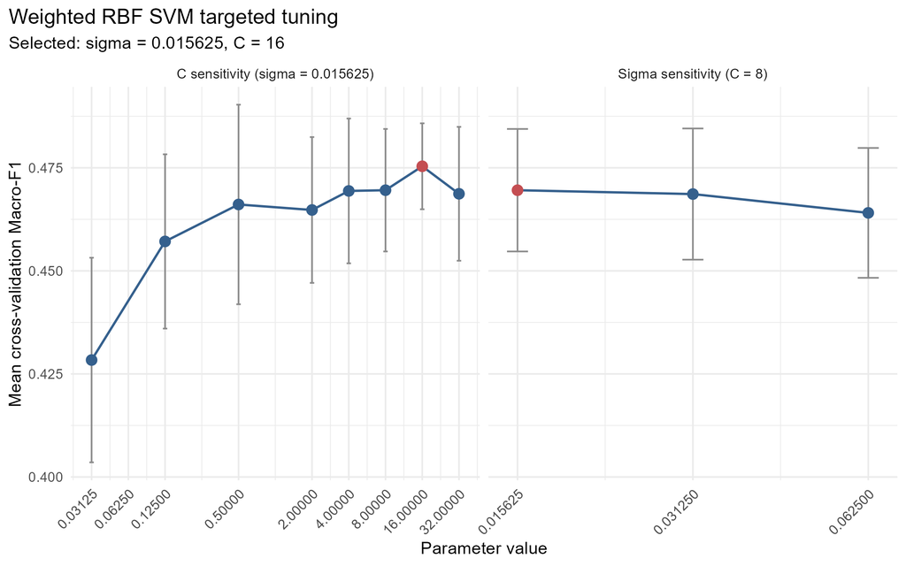

Weighted RBF SVM targeted tuning.

Compared with the weighted Linear SVM, the weighted RBF SVM increased mean cross-validation Macro-F1 from 0.4398 to 0.4754 and improved Below NQS recall from 0.0428 to 0.1369. Accuracy and Above NQS recall decreased slightly, while Below NQS remained the most difficult class to identify. All SVM results were based on provider-grouped cross-validation, and the held-out test set was not used during tuning.

```r
# -------------------------------------------------------------------
# Final selected RBF out-of-fold diagnostics
# -------------------------------------------------------------------

svm_rbf_selected_predictions <- selected_rbf_model$pred
outcome_levels <- levels(training_model_data$rating_tier)

predictions_per_row <- table(
  svm_rbf_selected_predictions$rowIndex
)

stopifnot(
  nrow(svm_rbf_selected_predictions) ==
    nrow(training_model_data),
  setequal(
    svm_rbf_selected_predictions$rowIndex,
    seq_len(nrow(training_model_data))
  ),
  all(predictions_per_row == 1L),
  !anyNA(
    svm_rbf_selected_predictions[
      ,
      c("pred", "obs", "rowIndex", "Resample", "sigma", "C")
    ]
  ),
  all(svm_rbf_selected_predictions$C == selected_rbf_C),
  all(
    svm_rbf_selected_predictions$sigma ==
      selected_rbf_sigma
  )
)

svm_rbf_confusion_matrix <- table(
  Observed = factor(
    svm_rbf_selected_predictions$obs,
    levels = outcome_levels
  ),
  Predicted = factor(
    svm_rbf_selected_predictions$pred,
    levels = outcome_levels
  )
)

rbf_true_positive <- diag(svm_rbf_confusion_matrix)

rbf_precision <- ifelse(
  colSums(svm_rbf_confusion_matrix) == 0,
  0,
  rbf_true_positive /
    colSums(svm_rbf_confusion_matrix)
)

rbf_recall <- ifelse(
  rowSums(svm_rbf_confusion_matrix) == 0,
  0,
  rbf_true_positive /
    rowSums(svm_rbf_confusion_matrix)
)

rbf_class_F1 <- ifelse(
  rbf_precision + rbf_recall == 0,
  0,
  2 * rbf_precision * rbf_recall /
    (rbf_precision + rbf_recall)
)

svm_rbf_class_metrics <- data.frame(
  rating_tier = outcome_levels,
  support = as.integer(
    rowSums(svm_rbf_confusion_matrix)
  ),
  precision = as.numeric(rbf_precision),
  recall = as.numeric(rbf_recall),
  F1 = as.numeric(rbf_class_F1),
  row.names = NULL
)

svm_rbf_pooled_metrics <- data.frame(
  metric = c(
    "Pooled_OOF_Macro_F1",
    "Pooled_OOF_Accuracy",
    "Mean_Fold_Macro_F1",
    "Mean_Fold_Accuracy"
  ),
  value = c(
    mean(rbf_class_F1),
    sum(rbf_true_positive) /
      sum(svm_rbf_confusion_matrix),
    rbf_selected_result$Macro_F1,
    rbf_selected_result$Accuracy
  )
)

cat("\nFinal RBF out-of-fold confusion matrix:\n")
print(svm_rbf_confusion_matrix)

cat("\nFinal RBF out-of-fold class metrics:\n")
print(svm_rbf_class_metrics)

cat("\nFinal RBF overall metrics:\n")
print(svm_rbf_pooled_metrics)

# -------------------------------------------------------------------
# Final Linear and RBF specification comparison
# -------------------------------------------------------------------

svm_kernel_comparison <- svm_model_comparison
svm_kernel_comparison$sigma <- NA_real_

svm_kernel_comparison <- svm_kernel_comparison[
  ,
  c(
    "specification",
    "C",
    "sigma",
    setdiff(
      names(svm_kernel_comparison),
      c("specification", "C", "sigma")
    )
  )
]

rbf_comparison_row <- svm_kernel_comparison[1, ]
rbf_comparison_row[1, ] <- NA

rbf_comparison_row$specification <-
  "Weighted RBF SVM (targeted)"
rbf_comparison_row$C <- selected_rbf_C
rbf_comparison_row$sigma <- selected_rbf_sigma
rbf_comparison_row$weighting <-
  "Square-root inverse frequency"
rbf_comparison_row$Macro_F1 <-
  rbf_selected_result$Macro_F1
rbf_comparison_row$Accuracy <-
  rbf_selected_result$Accuracy
rbf_comparison_row$Recall_Below_NQS <-
  rbf_selected_result$Recall_Below.NQS
rbf_comparison_row$Recall_Meeting_NQS <-
  rbf_selected_result$Recall_Meeting.NQS
rbf_comparison_row$Recall_Above_NQS <-
  rbf_selected_result$Recall_Above.NQS

baseline_comparison_row <-
  svm_kernel_comparison[
    svm_kernel_comparison$specification ==
      "Majority-class baseline",
  ]

rbf_comparison_row$Macro_F1_change_vs_baseline <-
  rbf_comparison_row$Macro_F1 -
  baseline_comparison_row$Macro_F1

rbf_comparison_row$Accuracy_change_vs_baseline <-
  rbf_comparison_row$Accuracy -
  baseline_comparison_row$Accuracy

svm_kernel_comparison <- rbind(
  svm_kernel_comparison,
  rbf_comparison_row
)

rownames(svm_kernel_comparison) <- NULL

cat("\nFinal Linear and RBF SVM comparison:\n")
print(svm_kernel_comparison)


# -------------------------------------------------------------------
# Phase 11: save final RBF outputs
# -------------------------------------------------------------------

dir.create(
  "outputs/models/svm",
  recursive = TRUE,
  showWarnings = FALSE
)

dir.create(
  "figures/models",
  recursive = TRUE,
  showWarnings = FALSE
)

# Selected parameters

svm_rbf_best_parameters <- data.frame(
  method = "svmRadial",
  kernel = "RBF",
  C = selected_rbf_C,
  sigma = selected_rbf_sigma,
  weighting = "Square-root inverse frequency",
  selection_metric = "Macro_F1",
  tuning_strategy =
    "Targeted two-parameter sensitivity analysis",
  cross_validation =
    "5-fold provider-grouped cross-validation"
)

# Selected fold-level results

svm_rbf_selected_resamples <- selected_rbf_model$resample
svm_rbf_selected_resamples$C <- selected_rbf_C
svm_rbf_selected_resamples$sigma <- selected_rbf_sigma

# Confusion matrix in long-form CSV format

svm_rbf_confusion_output <- as.data.frame(
  svm_rbf_confusion_matrix
)

names(svm_rbf_confusion_output) <- c(
  "Observed",
  "Predicted",
  "n"
)

# Training-time summary

rbf_C_candidate_times <- list(
  svm_rbf_C_003125_time,
  svm_rbf_C_0125_time,
  svm_rbf_C_05_time,
  svm_rbf_C_2_time,
  svm_rbf_C_4_time,
  svm_rbf_C_8_time,
  svm_rbf_C_16_time,
  svm_rbf_C_32_time
)

other_sigma_indices <- which(
  rbf_sigma_candidate_values != selected_rbf_sigma
)

rbf_timing_objects <- c(
  rbf_C_candidate_times,
  rbf_sigma_candidate_times[other_sigma_indices]
)

svm_rbf_timing <- data.frame(
  sigma = c(
    rep(selected_rbf_sigma, length(rbf_C_candidate_values)),
    rbf_sigma_candidate_values[other_sigma_indices]
  ),
  C = c(
    rbf_C_candidate_values,
    rep(rbf_pilot_C, length(other_sigma_indices))
  ),
  user_seconds = vapply(
    rbf_timing_objects,
    function(x) unname(x["user.self"]),
    numeric(1)
  ),
  system_seconds = vapply(
    rbf_timing_objects,
    function(x) unname(x["sys.self"]),
    numeric(1)
  ),
  elapsed_seconds = vapply(
    rbf_timing_objects,
    function(x) unname(x["elapsed"]),
    numeric(1)
  )
)

# Save CSV outputs

write.csv(
  svm_rbf_targeted_results,
  "outputs/models/svm/svm_rbf_targeted_tuning_results.csv",
  row.names = FALSE
)

write.csv(
  svm_rbf_selected_resamples,
  "outputs/models/svm/svm_rbf_selected_resample_results.csv",
  row.names = FALSE
)

write.csv(
  svm_rbf_best_parameters,
  "outputs/models/svm/svm_rbf_best_parameters.csv",
  row.names = FALSE
)

write.csv(
  svm_rbf_class_metrics,
  "outputs/models/svm/svm_rbf_class_metrics.csv",
  row.names = FALSE
)

write.csv(
  svm_rbf_confusion_output,
  "outputs/models/svm/svm_rbf_confusion_matrix.csv",
  row.names = FALSE
)

write.csv(
  svm_rbf_pooled_metrics,
  "outputs/models/svm/svm_rbf_overall_metrics.csv",
  row.names = FALSE
)

write.csv(
  svm_kernel_comparison,
  "outputs/models/svm/svm_kernel_model_comparison.csv",
  row.names = FALSE
)

write.csv(
  svm_rbf_timing,
  "outputs/models/svm/svm_rbf_timing.csv",
  row.names = FALSE
)

# Prepare two-panel tuning plot data

rbf_C_plot_data <- svm_rbf_targeted_results[
  svm_rbf_targeted_results$sigma ==
    selected_rbf_sigma,
]

rbf_C_plot_data$panel <-
  paste0("C sensitivity (sigma = ", selected_rbf_sigma, ")")

rbf_C_plot_data$parameter_value <-
  rbf_C_plot_data$C

rbf_C_plot_data$selected <-
  rbf_C_plot_data$C == selected_rbf_C

rbf_sigma_plot_data <- svm_rbf_targeted_results[
  svm_rbf_targeted_results$C == rbf_pilot_C,
]

rbf_sigma_plot_data$panel <-
  paste0("Sigma sensitivity (C = ", rbf_pilot_C, ")")

rbf_sigma_plot_data$parameter_value <-
  rbf_sigma_plot_data$sigma

rbf_sigma_plot_data$selected <-
  rbf_sigma_plot_data$sigma == selected_rbf_sigma

rbf_tuning_plot_data <- rbind(
  rbf_C_plot_data,
  rbf_sigma_plot_data
)

svm_rbf_tuning_plot <- ggplot(
  rbf_tuning_plot_data,
  aes(
    x = log2(parameter_value),
    y = Macro_F1,
    group = 1
  )
) +
  geom_errorbar(
    aes(
      ymin = Macro_F1 - Macro_F1SD,
      ymax = Macro_F1 + Macro_F1SD
    ),
    width = 0.12,
    colour = "grey55"
  ) +
  geom_line(
    colour = "#35608D",
    linewidth = 0.7
  ) +
  geom_point(
    aes(colour = selected),
    size = 2.8
  ) +
  facet_wrap(
    ~panel,
    scales = "free_x"
  ) +
  scale_colour_manual(
    values = c(
      "FALSE" = "#35608D",
      "TRUE" = "#C44E52"
    ),
    guide = "none"
  ) +
  scale_x_continuous(
    breaks = sort(
      unique(log2(rbf_tuning_plot_data$parameter_value))
    ),
    labels = function(x) format(2^x, trim = TRUE)
  ) +
  labs(
    x = "Parameter value",
    y = "Mean cross-validated Macro-F1",
    title = "Weighted RBF SVM targeted sensitivity analysis",
    subtitle = "Error bars show +/- 1 fold-level standard deviation"
  ) +
  theme_minimal(base_size = 11) +
  theme(
    panel.grid.minor = element_blank(),
    strip.text = element_text(face = "bold"),
    axis.text.x = element_text(angle = 45, hjust = 1)
  )

ggsave(
  filename = "figures/models/svm_rbf_targeted_tuning.png",
  plot = svm_rbf_tuning_plot,
  width = 9,
  height = 4.8,
  dpi = 300,
  bg = "white"
)

# Verify saved outputs

svm_rbf_output_files <- c(
  "outputs/models/svm/svm_rbf_targeted_tuning_results.csv",
  "outputs/models/svm/svm_rbf_selected_resample_results.csv",
  "outputs/models/svm/svm_rbf_best_parameters.csv",
  "outputs/models/svm/svm_rbf_class_metrics.csv",
  "outputs/models/svm/svm_rbf_confusion_matrix.csv",
  "outputs/models/svm/svm_rbf_overall_metrics.csv",
  "outputs/models/svm/svm_kernel_model_comparison.csv",
  "outputs/models/svm/svm_rbf_timing.csv",
  "figures/models/svm_rbf_targeted_tuning.png"
)

svm_rbf_output_check <- data.frame(
  file = svm_rbf_output_files,
  exists = file.exists(svm_rbf_output_files)
)

cat("\nSaved RBF outputs:\n")
print(svm_rbf_output_check)

stopifnot(all(svm_rbf_output_check$exists))
```

# Model Evaluation & Selection

## Selection of the final model

The following table summarises the mean five-fold cross-validation performance of each candidate model on the training set:

Provider-grouped five-fold CV comparison of each candidate’s selected configuration (training set only; not held-out test results).

| Model | Selected configuration | Mean macro-F1 | Fold SD | Mean accuracy | Recall: Below | Recall: Meeting | Recall: Above |
| --- | --- | --- | --- | --- | --- | --- | --- |
| LDA | Equal priors, 2 discriminants | 0.4364 | 0.0189 | 0.5106 | 0.525 | 0.483 | 0.601 |
| kNN | k = 5, equal voting | 0.4246 | 0.0247 | 0.7224 | 0.044 | 0.897 | 0.310 |
| MLR (selected) | Ridge, λ = 0.001, sqrt-inverse weights | 0.4871 | 0.0180 | 0.7255 | — | — | — |
| Random Forest | mtry = 5, min node = 20, balanced weights | 0.4825 | 0.0265 | 0.6302 | 0.290 | 0.674 | 0.605 |
| SVM (RBF) | C = 16, σ = 0.0156, sqrt-inverse weights | 0.4754 | 0.0104 | 0.7049 | 0.137 | 0.829 | 0.440 |
| Majority-class baseline | Always predict Meeting NQS | 0.2829 | 0.0029 | 0.7372 | 0.000 | 1.000 | 0.000 |

*Notes:* All macro-F1, SD and accuracy values come from the same five shared provider-grouped folds. kNN and Random Forest recalls are pooled out-of-fold values, whereas the others are fold means. The same folds were used for tuning and reporting, so these estimates are subject to selection optimism. MLR per-class CV recall was not saved for the shared-split run.

Following comparison of the candidate models, the group selected the tuned ridge MLR as its final model. On the five shared provider-grouped folds it had the highest mean CV macro-F1 (0.4871, SD 0.0180; mean accuracy 72.55%), narrowly ahead of Random Forest (0.4825) and the RBF SVM (0.4754). These gaps are smaller than the fold-to-fold variation, so the ranking is descriptive rather than a statistical win. The selection criterion was the highest mean CV macro-F1, and the MLR also provides the interpretable coefficients used in the next section. Random Forest detected more Below NQS services in CV but at much lower accuracy (63.02% against 72.55% for the MLR). The choice was made from training-set cross-validation before test scores were computed; the caveat about earlier use of the test partition is given in the next subsection.

### Selected model and test evaluation

Before final evaluation, the original MLR functions and tuning grid were rerun with the shared split and five shared folds, because the original MLR split differed from the group’s split. The corrected ridge multinomial model used alpha = 0, lambda = 0.001 and square-root inverse-frequency class weights. Its preprocessing and class weights were learned from the training data only, and it was refitted on all 13,497 training services. Model choice and parameters were fixed before test scores were computed, and the corrected model was not tuned on the test partition. However, the project’s test partition had been exposed in earlier model work, so the results below are not a pristine independent confirmation and should be read as descriptive estimates.

```r
test_table <- data.frame(
  Model = c("Selected ridge MLR", "Majority-class baseline"),
  `Macro-F1` = f4(c(mlr_test$macro_f1, base_test$macro_f1)),
  Accuracy = pct2(c(mlr_test$accuracy, base_test$accuracy)),
  check.names = FALSE
)
knitr::kable(
  test_table,
  align = c("l", "r", "r"),
  caption = paste0("Performance on the ", format(mlr_test$n_test, big.mark = ","),
                   "-service held-out test partition (not cross-validation).")
)
```

Performance on the 3,663-service held-out test partition (not cross-validation).

| Model | Macro-F1 | Accuracy |
| --- | --- | --- |
| Selected ridge MLR | 0.4542 | 73.25% |
| Majority-class baseline | 0.2885 | 76.28% |

On the test partition, the selected MLR reached macro-F1 **0.4542** (mean CV macro-F1 0.4871), compared with 0.2885 for the majority-class baseline. Its accuracy was lower (73.25% against 76.28%). This reflects the imbalance of the outcome: predicting Meeting NQS for every test service already gives 76.28% accuracy. Higher accuracy alone would therefore not demonstrate useful performance across all tiers.

```r
test_cm <- selected_csv("outputs/selected_model/test_confusion_matrix.csv")
tiers <- c("Below NQS", "Meeting NQS", "Above NQS")
test_cm$Observed  <- factor(test_cm$Observed,  levels = tiers)
test_cm$Predicted <- factor(test_cm$Predicted, levels = tiers)
cm_table <- xtabs(Count ~ Observed + Predicted, data = test_cm)
knitr::kable(as.matrix(cm_table),
  caption = "MLR test-set confusion matrix: rows are actual tiers; columns are predicted tiers.")
```

MLR test-set confusion matrix: rows are actual tiers; columns are predicted tiers.

|  | Below NQS | Meeting NQS | Above NQS |
| --- | --- | --- | --- |
| Below NQS | 20 | 209 | 19 |
| Meeting NQS | 82 | 2418 | 294 |
| Above NQS | 9 | 367 | 245 |

Only **20 of 248 Below NQS services (8.1%)** were detected; 209 were predicted as Meeting NQS and 19 as Above NQS. Recall was 86.5% for Meeting NQS and 39.5% for Above NQS. Consequently, this model may inform exploratory review but should not be used alone to identify below-standard services or determine regulatory action.

The folded code below is the actual split-correction, training-only tuning and fixed-model test-evaluation scripts. It is displayed rather than rerun during rendering; the tables read its saved outputs.

```r
# Run from the repository root. Reuses the original MLR method and grid,
# but creates separate manifests from the group's actual shared workflow.
source("R/06_model_setup.R")
source("mlr/preprocessing.R")
source("mlr/tuning.R")
source("mlr/interpretation.R")
stopifnot(requireNamespace("glmnet", quietly = TRUE))
out <- "outputs/mlr_shared"
dir.create(out, recursive = TRUE, showWarnings = FALSE)
df <- as.data.frame(model_data_raw)
manifest <- data.frame(service_id = df$service_id, provider_id = df$provider_id,
                       rating_tier = df$rating_tier,
                       partition = ifelse(df$service_id %in% training_data$service_id,
                                          "train", "test"))
fold <- rep(NA_character_, nrow(training_data))
for (f in names(cv_index_out)) fold[cv_index_out[[f]]] <- f
stopifnot(!anyNA(fold))
fold_manifest <- data.frame(service_id = training_data$service_id,
                            provider_id = training_data$provider_id, fold = fold)
write.csv(manifest, file.path(out, "split_manifest.csv"), row.names = FALSE)
write.csv(fold_manifest, file.path(out, "cv_fold_manifest.csv"), row.names = FALSE)
m <- mlr_load_manifests(df, out)
stopifnot(identical(as.character(df$service_id[m$train_rows]),
                    as.character(training_data$service_id)), identical(m$fold, fold))
old <- read.csv("outputs/mlr/split_manifest.csv")
audit <- data.frame(
  check = c("shared_training_rows", "shared_test_rows", "shared_provider_overlap",
            "corrected_training_rows_in_shared_test", "original_mlr_training_rows_in_shared_test"),
  value = c(nrow(training_data), nrow(test_data),
            length(intersect(training_data$provider_id, test_data$provider_id)),
            sum(df$service_id[m$train_rows] %in% test_data$service_id),
            sum(old$service_id[old$partition == "train"] %in% test_data$service_id)))
write.csv(audit, file.path(out, "split_audit.csv"), row.names = FALSE)
set.seed(5003)
mlr_run_tuning(df, manifest_dir = out, out_dir = out)
mlr_fit_selected_train(df, manifest_dir = out, out_dir = out)
capture.output(sessionInfo(), file = file.path(out, "session_info.txt"))
inputs <- c("R/06_model_setup.R", "mlr/preprocessing.R", "mlr/tuning.R",
            "mlr/interpretation.R", "data/processed/acecqa_analysis.csv")
write.csv(data.frame(path = inputs, md5 = unname(tools::md5sum(inputs))),
          file.path(out, "input_hashes.csv"), row.names = FALSE)
```

```r
# Run after R/11_mlr_shared_split.R, from the repository root.
# Freeze the CV choice before computing any test metrics. Never tune on test scores.
source("R/06_model_setup.R")
source("mlr/preprocessing.R")
source("mlr/tuning.R")
library(glmnet)
out <- "outputs/selected_model"
dir.create(out, recursive = TRUE, showWarnings = FALSE)
dir.create("figures/selected_model", recursive = TRUE, showWarnings = FALSE)
read <- function(path) read.csv(path, check.names = FALSE)
save_csv <- function(x, name) write.csv(x, file.path(out, name), row.names = FALSE)
cfg <- read("outputs/mlr_shared/mlr_selected_config.csv")
mlr <- read("outputs/mlr_shared/mlr_tuning_fold_metrics.csv")
mlr <- mlr[mlr$weights == cfg$weights & abs(mlr$lambda - cfg$lambda) < 1e-12, ]
rf_cfg <- read("outputs/random_forest/cv_summary.csv")[1, ]
rf <- read("outputs/random_forest/cv_fold_metrics.csv")
rf <- rf[rf$candidate == rf_cfg$candidate, ]
knn_cfg <- read(file.path(out, "reference/knn_best_parameters.csv"))
knn <- read(file.path(out, "reference/knn_cv_fold_metrics.csv"))
knn <- knn[knn$k == knn_cfg$k & knn$kernel == knn_cfg$kernel, ]
lda <- read(file.path(out, "reference/lda_cv_fold_metrics.csv"))
svm <- read("outputs/models/svm/svm_rbf_selected_resample_results.csv")
base <- read("outputs/random_forest/baseline_cv.csv")
harmonise <- function(model, fold, f1, accuracy) {
  stopifnot(length(fold) == 5L, setequal(fold, paste0("Fold", 1:5)),
            !anyDuplicated(fold), all(is.finite(f1)), all(is.finite(accuracy)))
  data.frame(model = model, fold = fold, macro_f1 = f1, accuracy = accuracy)
}
folds <- rbind(
  harmonise("MLR (shared split)", mlr$fold, mlr$macro_f1, mlr$accuracy),
  harmonise("Random Forest", rf$fold, rf$Macro_F1, rf$Accuracy),
  harmonise("SVM (RBF)", svm$Resample, svm$Macro_F1, svm$Accuracy),
  harmonise("LDA", lda$Resample, lda$Macro_F1, lda$Accuracy),
  harmonise("KNN", knn$fold, knn$Macro_F1, knn$Accuracy),
  harmonise("Majority baseline", base$fold, base$Macro_F1, base$Accuracy))
ranking <- do.call(rbind, lapply(split(folds, folds$model), function(z) {
  data.frame(model = z$model[1], mean_macro_f1 = mean(z$macro_f1),
             sd_macro_f1 = sd(z$macro_f1), mean_accuracy = mean(z$accuracy))
}))
ranking <- ranking[order(-ranking$mean_macro_f1), ]
rownames(ranking) <- NULL
stopifnot(ranking$model[1] == "MLR (shared split)")
save_csv(folds, "comparison_fold_metrics.csv")
save_csv(ranking, "comparison_summary.csv")
print(ranking)

df <- as.data.frame(model_data_raw)
manifest <- mlr_load_manifests(df, "outputs/mlr_shared")
stopifnot(identical(as.character(df$service_id[manifest$train_rows]),
                    as.character(training_data$service_id)))
for (f in names(cv_index_out)) stopifnot(all(manifest$fold[cv_index_out[[f]]] == f))
train <- mlr_model_data(training_data)
test <- mlr_model_data(test_data)
fit <- readRDS("outputs/mlr_shared/mlr_selected_train_model.rds")
stopifnot(fit$selected_config$lambda == cfg$lambda,
          fit$selected_config$weights == cfg$weights,
          nrow(fit$recipe$template) == nrow(train),
          length(intersect(training_data$provider_id, test_data$provider_id)) == 0)
# Re-prepping verifies that the saved preprocessing was learned on these training rows.
check_recipe <- recipes::prep(make_mlr_recipe(train), training = train, retain = TRUE)
x_train <- as.matrix(recipes::bake(fit$recipe, new_data = train, recipes::all_predictors()))
x_check <- as.matrix(recipes::bake(check_recipe, new_data = train, recipes::all_predictors()))
stopifnot(isTRUE(all.equal(x_train, x_check, tolerance = 1e-12)))
x_test <- as.matrix(recipes::bake(fit$recipe, new_data = test, recipes::all_predictors()))
storage.mode(x_test) <- "double"
stopifnot(identical(colnames(x_test), fit$model_feature_columns), !anyNA(x_test))
inputs <- c("outputs/mlr_shared/mlr_selected_train_model.rds",
            "outputs/mlr_shared/split_manifest.csv", "outputs/mlr_shared/cv_fold_manifest.csv",
            "outputs/mlr_shared/mlr_selected_config.csv", "data/processed/acecqa_analysis.csv")
save_csv(data.frame(path = inputs, md5 = unname(tools::md5sum(inputs))), "input_hashes.csv")
save_csv(data.frame(model = ranking$model[1], lambda = cfg$lambda, weights = cfg$weights,
                    criterion = "highest mean training CV Macro-F1",
                    selected_before_test_scoring = TRUE), "selection.csv")

pred <- as.character(predict(fit$model, newx = x_test, s = cfg$lambda, type = "class"))
score <- mlr_fold_scores(test$rating_tier, pred)
majority <- names(which.max(table(train$rating_tier)))
baseline <- mlr_fold_scores(test$rating_tier, rep(majority, nrow(test)))
metrics <- data.frame(model = c("MLR (shared split)", "Majority baseline"),
                       macro_f1 = c(score$macro_f1, baseline$macro_f1),
                       accuracy = c(score$accuracy, baseline$accuracy),
                       n_test = nrow(test))
save_csv(metrics, "test_metrics.csv")
save_csv(score$per_class, "test_class_metrics.csv")
cm <- as.data.frame(score$confusion)
names(cm) <- c("Observed", "Predicted", "Count")
save_csv(cm, "test_confusion_matrix.csv")
save_csv(data.frame(service_id = test_data$service_id, provider_id = test_data$provider_id,
                    observed = test$rating_tier, predicted = pred), "test_predictions.csv")
save_csv(data.frame(check = c("training_rows", "test_rows", "training_providers", "test_providers",
                              "overlapping_providers", "preprocessing_matches_training_only"),
                    value = c(nrow(train), nrow(test), length(unique(training_data$provider_id)),
                              length(unique(test_data$provider_id)), 0, 1)), "evaluation_audit.csv")
p <- ggplot(cm, aes(Predicted, Observed, fill = Count)) +
  geom_tile() + geom_text(aes(label = Count), size = 5) +
  scale_fill_gradient(low = "white", high = "#71a499") +
  scale_y_discrete(limits = rev(mlr_class_levels)) +
  labs(x = "Predicted tier", y = "Actual tier") + theme_minimal(base_size = 14) +
  theme(panel.grid = element_blank(), legend.position = "none")
ggsave("figures/selected_model/mlr_test_confusion.png", p, width = 7, height = 4.8, dpi = 180)
capture.output(sessionInfo(), file = file.path(out, "session_info.txt"))
print(metrics)
print(score$per_class)
cat("This corrected model excludes the shared test set from fitting and tuning.\n",
    "The project's test partition was previously exposed in other model work;\n",
    "these results are NOT a pristine independent final confirmation.\n")
```

## Interpretation and Stakeholder Insights

### Interpretation of the selected MLR

We inspected coefficients from the selected ridge MLR (shared split, $\lambda = 0.001$) refitted using the **training partition only**. In the multinomial `glmnet` parameterisation (Friedman et al., 2010), a coefficient for one class is **not** by itself an odds ratio against Meeting NQS. For a predictor $x_j$, the log-odds contrast between two classes depends on the difference between the corresponding class coefficients, $\beta_{j,A}-\beta_{j,B}$. The signs below therefore refer to **Above versus Meeting NQS** or **Below versus Meeting NQS**, holding other encoded predictors fixed.

For **Above NQS compared with Meeting NQS**, the largest coefficient differences among non-state predictors were positive for standalone preschool status (**+0.362**) and provider approval age (**+0.320**), and negative for after-school-care status (**−0.618**). The state indicators produced the largest negative differences (NSW **−0.602**, QLD **−0.578**, WA **−0.539**, VIC **−0.449** and NT **−0.328**), meaning that services in these states had lower modelled log-odds of Above versus Meeting NQS than services in the reference state category. For **Below NQS compared with Meeting NQS**, recorded service approval conditions had a positive coefficient difference (**+0.244**), whereas provider service count had a negative difference (**−0.298**); Victoria showed the largest state contrast (**−0.515**). Approval age is a proxy based on administrative dates, not necessarily operating experience. These findings describe conditional associations learned by the fitted model, **not causal effects** or a ranking of determinants of quality. Numeric features and dummy-coded indicators were processed and standardised, so the coefficients should not be interpreted as effects of a one-year increase or a raw 0-to-1 switch without accounting for the relevant scaling.

### Stakeholder implications and cautions

For **regulators**, administrative predictors may support exploratory monitoring and help identify questions for further quality-review planning. However, the selected MLR detected only **8.1% of Below NQS services on the held-out test partition** (20 of 248), and its cross-validation recall for this tier was similarly low (10.2% on the original MLR split). This means that most services in this tier were not identified; it is therefore **unsuitable as a stand-alone screening or compliance decision tool**. For **service providers**, the associations can stimulate quality-improvement discussions but do not show that changing a particular administrative characteristic would raise an NQS rating. For **policy researchers**, this model offers a transparent benchmark for studying associations and testing whether richer information improves minority-class identification.

Any practical use would require expert oversight, assessment of subgroup performance (including across states and service types), and validation beyond this register snapshot. Predictions should supplement, not replace, formal NQS assessment.

# Final Results & Conclusion

The research question asked how well administrative service and provider characteristics can classify an Australian education and care service’s recorded NQS rating tier. The answer from this analysis is: **better than a majority-class guess on balanced performance, but not reliably enough for tier-level decisions**. Across the five candidate models, the best mean CV macro-F1 was close to 0.4871, and the top three models (MLR, Random Forest and RBF SVM) were within about 0.01 of each other, compared with 0.2829 for the majority-class baseline. The selected ridge MLR scored a macro-F1 of **0.4542** on the 3,663-service held-out test partition, against **0.2885** for the baseline. Its test accuracy (**73.25%**) was lower than the baseline’s (**76.28%**) because the baseline predicts the dominant Meeting NQS tier every time. The test macro-F1 was lower than the mean CV macro-F1 of 0.4871, which is consistent with cross-validation estimates being somewhat optimistic after tuning and selection on the same folds, although a single test split cannot confirm this.

Performance differed sharply by tier. On the test partition the MLR identified **86.5%** of Meeting NQS services and **39.5%** of Above NQS services, but only **8.1%** (20 of 248) of Below NQS services. Models that detected more Below NQS services in cross-validation did so at a cost in overall accuracy: Random Forest identified 29.0% of them at 63.0% accuracy, and LDA with equal priors identified 52.5% at 51.1% accuracy. The MLR coefficients suggest that state, after-school-care status, standalone preschool status, provider approval age and provider service count are associated with tier differences, but these are conditional associations in one register snapshot, not causal effects.

The model may therefore support exploratory monitoring and questions for quality-review planning, but it should not be used alone to screen services or to determine regulatory action. Several limitations apply. The outcome is highly imbalanced and treated as nominal, so the tiers’ ordering is not used. The same folds were used for tuning and reporting, which can inflate cross-validation estimates. The test partition had been exposed in earlier model work, so the test results are descriptive estimates rather than a pristine independent confirmation. Future work could add richer predictors, use ordinal or cost-sensitive methods aimed at Below NQS recall, check subgroup performance across states and service types, and validate on a later register snapshot.

# References

Australian Children's Education & Care Quality Authority. (n.d.-a). *Assessment and rating process*. https://www.acecqa.gov.au/assessment/assessment-and-rating-process

Australian Children's Education & Care Quality Authority. (n.d.-b). *National registers*. https://www.acecqa.gov.au/resources/national-registers

Friedman, J. H., Hastie, T., & Tibshirani, R. (2010). Regularization paths for generalized linear models via coordinate descent. *Journal of Statistical Software, 33*(1), 1–22. https://doi.org/10.18637/jss.v033.i01

Karatzoglou, A., Smola, A., Hornik, K., & Zeileis, A. (2004). kernlab: An S4 package for kernel methods in R. *Journal of Statistical Software, 11*(9), 1–20. https://doi.org/10.18637/jss.v011.i09

Kuhn, M., Wickham, H., & Hvitfeldt, E. (2026). *recipes: Preprocessing and feature engineering steps for modeling* (Version 1.4.0) [Computer software]. https://doi.org/10.32614/CRAN.package.recipes

Schliep, K., & Hechenbichler, K. (2025). *kknn: Weighted k-nearest neighbors* (Version 1.4.1) [Computer software]. https://doi.org/10.32614/CRAN.package.kknn

# AI Use Statement

I, Zixuan Zhao (SID: 550497901), acknowledge the use of OpenAI Codex as a supporting tool during the preparation of the KNN section of the final report, including checking text grammar and improving clarity, integrating R Markdown code, and checking reported results against existing model outputs. I carefully reviewed the related content for accuracy and take responsibility for the submitted work.

I, Khoa Tran (SID: 550339069), acknowledge the use of Claude’s Sonnet as a supporting tool during the validation of LDA model, cross-validation comparison, and conclusion sections of the final report, including checking grammar, improving readability and formatting. I carefully reviewed the related content for accuracy and take responsibility for the submitted work.

I, Yuzhi Shao (SID: 550139687), acknowledge the use of OpenAI Codex as a supporting tool during the preparation of the SVM section of the final report, including checking text grammar and shortening text, integrating R Markdown code, and checking reported results against existing model outputs. I carefully reviewed the related content for accuracy and take responsibility for the submitted work.

I, Jian Zhang (SID: 541018333), acknowledge the use of ChatGPT as a supporting tool during the preparation of the MLR section of the final report, including checking the correctness of the report grammar and debugging. I carefully reviewed the related content for accuracy and take responsibility for the submitted work.

I, Wenchen Zhong (SID: 550245221), acknowledge the use of OpenAI Codex to assist with writing and checking R code, drafting and revising the Random Forest and selected-model evaluation sections, checking results, and improving grammar and report formatting.

# Appendix

## Appendix A: Preprocessing Checks

These checks execute the shared setup without fitting SVM candidates. Only training-fold data are used to estimate the recipe parameters. The held-out test data are used here only to check split membership and dimensions.

```r
report_root <- normalizePath('..', winslash='/')
preprocessing_env <- new.env()
local({
  previous_directory <- getwd()
  on.exit(setwd(previous_directory))
  setwd(report_root)
  sys.source('R/06_model_setup.R', envir=preprocessing_env)
})
preprocessing_checks <- with(preprocessing_env, data.frame(
  Check = c('Training services', 'Test services', 'Training providers',
            'Test providers', 'Predictors', 'CV folds',
            'Train-test provider overlap', 'Maximum within-fold provider overlap'),
  Value = c(nrow(training_data), nrow(test_data),
            length(unique(training_data$provider_id)),
            length(unique(test_data$provider_id)), length(predictor_names),
            length(cv_index),
            length(intersect(training_data$provider_id, test_data$provider_id)),
            max(vapply(names(cv_index), function(fold) {
              length(intersect(training_data$provider_id[cv_index[[fold]]],
                               training_data$provider_id[cv_index_out[[fold]]]))
            }, integer(1))))
))
```

```r
knitr::kable(preprocessing_checks, caption='Shared preprocessing and split checks.')
```

Shared preprocessing and split checks.

| Check | Value |
| --- | --- |
| Training services | 13497 |
| Test services | 3663 |
| Training providers | 5509 |
| Test providers | 1376 |
| Predictors | 28 |
| CV folds | 5 |
| Train-test provider overlap | 0 |
| Maximum within-fold provider overlap | 0 |

**Fold distributions and preprocessing validation**

```r
knitr::kable(preprocessing_env$cv_fold_summary,
             caption='Fixed validation-fold class distributions.')
```

Fixed validation-fold class distributions.

| fold | rating_tier | n_services | percentage |
| --- | --- | --- | --- |
| Fold1 | Below NQS | 199 | 6.5 |
| Fold1 | Meeting NQS | 2261 | 73.4 |
| Fold1 | Above NQS | 622 | 20.2 |
| Fold2 | Below NQS | 187 | 7.5 |
| Fold2 | Meeting NQS | 1846 | 73.7 |
| Fold2 | Above NQS | 473 | 18.9 |
| Fold3 | Below NQS | 187 | 7.4 |
| Fold3 | Meeting NQS | 1844 | 72.7 |
| Fold3 | Above NQS | 505 | 19.9 |
| Fold4 | Below NQS | 253 | 9.0 |
| Fold4 | Meeting NQS | 2142 | 76.0 |
| Fold4 | Above NQS | 424 | 15.0 |
| Fold5 | Below NQS | 190 | 7.4 |
| Fold5 | Meeting NQS | 1861 | 72.9 |
| Fold5 | Above NQS | 503 | 19.7 |

```r
knitr::kable(data.frame(
  Recipe = c('Scaled', 'Tree'),
  Validation_rows = c(nrow(preprocessing_env$scaled_validation_check),
                      nrow(preprocessing_env$tree_validation_check)),
  Output_columns = c(ncol(preprocessing_env$scaled_validation_check),
                     ncol(preprocessing_env$tree_validation_check)),
  Missing_values = c(sum(is.na(preprocessing_env$scaled_validation_check)),
                     sum(is.na(preprocessing_env$tree_validation_check)))
), caption='Fold 1 recipe validation; output columns include the outcome.')
```

Fold 1 recipe validation; output columns include the outcome.

| Recipe | Validation_rows | Output_columns | Missing_values |
| --- | --- | --- | --- |
| Scaled | 3082 | 33 | 0 |
| Tree | 3082 | 33 | 0 |

## Appendix B: SVM Run Results

The following supplementary results are read from the saved CV outputs, with no held-out test evaluation. Macro-F1 and recall in the main-text comparison table are fold means; class metrics and confusion matrices below pool the OOF predictions.

**Complete saved SVM tuning, timing and diagnostic tables**

```r
svm_output_files <- c(
  'svm_linear_tuning_results.csv', 'svm_rbf_targeted_tuning_results.csv',
  'svm_linear_best_parameters.csv', 'svm_rbf_best_parameters.csv',
  'svm_linear_resample_results.csv', 'svm_rbf_selected_resample_results.csv',
  'svm_linear_class_metrics.csv', 'svm_rbf_class_metrics.csv',
  'svm_linear_confusion_matrix.csv', 'svm_rbf_confusion_matrix.csv',
  'svm_linear_overall_metrics.csv', 'svm_rbf_overall_metrics.csv',
  'svm_linear_timing.csv', 'svm_rbf_timing.csv',
  'svm_linear_package_versions.csv'
)
for (output_file in svm_output_files) {
  saved_results <- read.csv(file.path('../outputs/models/svm', output_file),
                            check.names=FALSE)
  cat('\n\n')
  print(knitr::kable(saved_results, digits=4, caption=output_file, format='html'))
  cat('\n\n')
}
```

svm_linear_tuning_results.csv

| specification | C | Macro_F1 | Macro_F1SD | Accuracy | AccuracySD | Recall_Below.NQS | Recall_Meeting.NQS | Recall_Above.NQS |
| --- | --- | --- | --- | --- | --- | --- | --- | --- |
| Unweighted | 0.0078 | 0.2829 | 0.0029 | 0.7372 | 0.0132 | 0.0000 | 1.0000 | 0.0000 |
| Unweighted | 0.0312 | 0.2829 | 0.0029 | 0.7372 | 0.0132 | 0.0000 | 1.0000 | 0.0000 |
| Unweighted | 0.0625 | 0.2829 | 0.0029 | 0.7372 | 0.0132 | 0.0000 | 1.0000 | 0.0000 |
| Unweighted | 0.1250 | 0.2829 | 0.0029 | 0.7372 | 0.0132 | 0.0000 | 1.0000 | 0.0000 |
| Unweighted | 0.2500 | 0.2829 | 0.0029 | 0.7372 | 0.0132 | 0.0000 | 1.0000 | 0.0000 |
| Unweighted | 0.5000 | 0.2829 | 0.0029 | 0.7372 | 0.0132 | 0.0000 | 1.0000 | 0.0000 |
| Unweighted | 2.0000 | 0.2829 | 0.0029 | 0.7372 | 0.0132 | 0.0000 | 1.0000 | 0.0000 |
| Unweighted | 8.0000 | 0.2829 | 0.0029 | 0.7372 | 0.0132 | 0.0000 | 1.0000 | 0.0000 |
| Weighted | 0.0078 | 0.4344 | 0.0438 | 0.7074 | 0.0249 | 0.0393 | 0.8349 | 0.4712 |
| Weighted | 0.0312 | 0.4338 | 0.0436 | 0.7062 | 0.0286 | 0.0408 | 0.8337 | 0.4693 |
| Weighted | 0.0625 | 0.4355 | 0.0411 | 0.7072 | 0.0290 | 0.0418 | 0.8347 | 0.4702 |
| Weighted | 0.1250 | 0.4355 | 0.0412 | 0.7064 | 0.0282 | 0.0428 | 0.8331 | 0.4719 |
| Weighted | 0.2500 | 0.4351 | 0.0412 | 0.7059 | 0.0281 | 0.0428 | 0.8324 | 0.4715 |
| Weighted | 0.5000 | 0.4356 | 0.0409 | 0.7079 | 0.0288 | 0.0418 | 0.8354 | 0.4715 |
| Weighted | 2.0000 | 0.4363 | 0.0404 | 0.7075 | 0.0285 | 0.0428 | 0.8344 | 0.4727 |
| Weighted | 8.0000 | 0.4398 | 0.0358 | 0.7094 | 0.0298 | 0.0428 | 0.8351 | 0.4793 |

svm_rbf_targeted_tuning_results.csv

| sigma | C | Macro_F1 | Macro_F1SD | Accuracy | AccuracySD | Recall_Below.NQS | Recall_Meeting.NQS | Recall_Above.NQS | search_role |
| --- | --- | --- | --- | --- | --- | --- | --- | --- | --- |
| 0.0156 | 0.0312 | 0.4284 | 0.0248 | 0.7356 | 0.0238 | 0.0010 | 0.8874 | 0.4292 | C sensitivity |
| 0.0156 | 0.1250 | 0.4571 | 0.0211 | 0.7309 | 0.0288 | 0.0581 | 0.8771 | 0.4218 | C sensitivity |
| 0.0156 | 0.5000 | 0.4661 | 0.0242 | 0.7305 | 0.0228 | 0.0836 | 0.8795 | 0.4020 | C sensitivity |
| 0.0156 | 2.0000 | 0.4648 | 0.0177 | 0.7262 | 0.0220 | 0.0917 | 0.8764 | 0.3905 | C sensitivity |
| 0.0156 | 4.0000 | 0.4694 | 0.0176 | 0.7164 | 0.0197 | 0.1153 | 0.8575 | 0.4027 | C sensitivity |
| 0.0156 | 8.0000 | 0.4696 | 0.0149 | 0.7095 | 0.0190 | 0.1304 | 0.8461 | 0.4041 | Shared reference |
| 0.0156 | 16.0000 | 0.4754 | 0.0104 | 0.7049 | 0.0208 | 0.1369 | 0.8293 | 0.4403 | C sensitivity |
| 0.0156 | 32.0000 | 0.4687 | 0.0162 | 0.6931 | 0.0238 | 0.1381 | 0.8120 | 0.4440 | C sensitivity |
| 0.0312 | 8.0000 | 0.4686 | 0.0159 | 0.6963 | 0.0202 | 0.1355 | 0.8188 | 0.4363 | Sigma sensitivity |
| 0.0625 | 8.0000 | 0.4641 | 0.0158 | 0.6893 | 0.0207 | 0.1359 | 0.8093 | 0.4382 | Sigma sensitivity |

svm_linear_best_parameters.csv

| kernel | C | weighting | weight_Below_NQS | weight_Meeting_NQS | weight_Above_NQS | primary_metric |
| --- | --- | --- | --- | --- | --- | --- |
| Linear | 8 | Square-root inverse frequency | 3.1301 | 1 | 1.9847 | Macro_F1 |

svm_rbf_best_parameters.csv

| method | kernel | C | sigma | weighting | selection_metric | tuning_strategy | cross_validation |
| --- | --- | --- | --- | --- | --- | --- | --- |
| svmRadial | RBF | 16 | 0.0156 | Square-root inverse frequency | Macro_F1 | Targeted two-parameter sensitivity analysis | 5-fold provider-grouped cross-validation |

svm_linear_resample_results.csv

| C | Macro_F1 | Accuracy | Recall_Below.NQS | Recall_Meeting.NQS | Recall_Above.NQS | Resample |
| --- | --- | --- | --- | --- | --- | --- |
| 0.0078 | 0.5020 | 0.6966 | 0.1658 | 0.7656 | 0.6158 | Fold1 |
| 0.0078 | 0.4293 | 0.7163 | 0.0053 | 0.8516 | 0.4693 | Fold2 |
| 0.0078 | 0.4215 | 0.6759 | 0.0053 | 0.7711 | 0.5762 | Fold3 |
| 0.0078 | 0.4385 | 0.7432 | 0.0198 | 0.8917 | 0.4245 | Fold4 |
| 0.0078 | 0.3807 | 0.7052 | 0.0000 | 0.8947 | 0.2704 | Fold5 |
| 0.0312 | 0.5020 | 0.6953 | 0.1759 | 0.7656 | 0.6061 | Fold1 |
| 0.0312 | 0.4285 | 0.7219 | 0.0000 | 0.8597 | 0.4693 | Fold2 |
| 0.0312 | 0.4241 | 0.6664 | 0.0160 | 0.7570 | 0.5762 | Fold3 |
| 0.0312 | 0.4334 | 0.7425 | 0.0119 | 0.8917 | 0.4245 | Fold4 |
| 0.0312 | 0.3808 | 0.7052 | 0.0000 | 0.8947 | 0.2704 | Fold5 |
| 0.0625 | 0.5005 | 0.6944 | 0.1759 | 0.7656 | 0.6013 | Fold1 |
| 0.0625 | 0.4336 | 0.7251 | 0.0053 | 0.8646 | 0.4651 | Fold2 |
| 0.0625 | 0.4240 | 0.6664 | 0.0160 | 0.7570 | 0.5762 | Fold3 |
| 0.0625 | 0.4325 | 0.7421 | 0.0119 | 0.8917 | 0.4222 | Fold4 |
| 0.0625 | 0.3866 | 0.7083 | 0.0000 | 0.8947 | 0.2863 | Fold5 |
| 0.1250 | 0.5021 | 0.6947 | 0.1809 | 0.7656 | 0.6013 | Fold1 |
| 0.1250 | 0.4299 | 0.7187 | 0.0053 | 0.8548 | 0.4693 | Fold2 |
| 0.1250 | 0.4242 | 0.6664 | 0.0160 | 0.7570 | 0.5762 | Fold3 |
| 0.1250 | 0.4325 | 0.7421 | 0.0119 | 0.8917 | 0.4222 | Fold4 |
| 0.1250 | 0.3886 | 0.7103 | 0.0000 | 0.8963 | 0.2903 | Fold5 |
| 0.2500 | 0.5015 | 0.6944 | 0.1809 | 0.7656 | 0.5997 | Fold1 |
| 0.2500 | 0.4297 | 0.7175 | 0.0053 | 0.8532 | 0.4693 | Fold2 |
| 0.2500 | 0.4241 | 0.6664 | 0.0160 | 0.7570 | 0.5762 | Fold3 |
| 0.2500 | 0.4325 | 0.7421 | 0.0119 | 0.8917 | 0.4222 | Fold4 |
| 0.2500 | 0.3878 | 0.7091 | 0.0000 | 0.8947 | 0.2903 | Fold5 |
| 0.5000 | 0.5020 | 0.6947 | 0.1809 | 0.7656 | 0.6013 | Fold1 |
| 0.5000 | 0.4292 | 0.7223 | 0.0000 | 0.8602 | 0.4693 | Fold2 |
| 0.5000 | 0.4242 | 0.6664 | 0.0160 | 0.7570 | 0.5762 | Fold3 |
| 0.5000 | 0.4325 | 0.7421 | 0.0119 | 0.8917 | 0.4222 | Fold4 |
| 0.5000 | 0.3900 | 0.7142 | 0.0000 | 0.9022 | 0.2883 | Fold5 |
| 2.0000 | 0.5020 | 0.6947 | 0.1809 | 0.7656 | 0.6013 | Fold1 |
| 2.0000 | 0.4311 | 0.7203 | 0.0053 | 0.8570 | 0.4693 | Fold2 |
| 2.0000 | 0.4242 | 0.6664 | 0.0160 | 0.7570 | 0.5762 | Fold3 |
| 2.0000 | 0.4327 | 0.7421 | 0.0119 | 0.8917 | 0.4222 | Fold4 |
| 2.0000 | 0.3915 | 0.7142 | 0.0000 | 0.9006 | 0.2942 | Fold5 |
| 8.0000 | 0.5020 | 0.6947 | 0.1809 | 0.7656 | 0.6013 | Fold1 |
| 8.0000 | 0.4300 | 0.7294 | 0.0053 | 0.8808 | 0.4249 | Fold2 |
| 8.0000 | 0.4243 | 0.6664 | 0.0160 | 0.7570 | 0.5762 | Fold3 |
| 8.0000 | 0.4327 | 0.7421 | 0.0119 | 0.8917 | 0.4222 | Fold4 |
| 8.0000 | 0.4102 | 0.7146 | 0.0000 | 0.8802 | 0.3718 | Fold5 |

svm_rbf_selected_resample_results.csv

| Macro_F1 | Accuracy | Recall_Below.NQS | Recall_Meeting.NQS | Recall_Above.NQS | Resample | C | sigma |
| --- | --- | --- | --- | --- | --- | --- | --- |
| 0.4684 | 0.7103 | 0.1407 | 0.8487 | 0.3891 | Fold1 | 16 | 0.0156 |
| 0.4873 | 0.7111 | 0.1497 | 0.8348 | 0.4503 | Fold2 | 16 | 0.0156 |
| 0.4695 | 0.6861 | 0.1070 | 0.7907 | 0.5188 | Fold3 | 16 | 0.0156 |
| 0.4861 | 0.7339 | 0.1502 | 0.8697 | 0.3962 | Fold4 | 16 | 0.0156 |
| 0.4656 | 0.6832 | 0.1368 | 0.8028 | 0.4473 | Fold5 | 16 | 0.0156 |

svm_linear_class_metrics.csv

| rating_tier | support | precision | recall | F1 |
| --- | --- | --- | --- | --- |
| Below NQS | 1016 | 0.1541 | 0.0423 | 0.0664 |
| Meeting NQS | 9954 | 0.7941 | 0.8339 | 0.8135 |
| Above NQS | 2527 | 0.4456 | 0.4875 | 0.4656 |

svm_rbf_class_metrics.csv

| rating_tier | support | precision | recall | F1 |
| --- | --- | --- | --- | --- |
| Below NQS | 1016 | 0.1864 | 0.1378 | 0.1585 |
| Meeting NQS | 9954 | 0.7936 | 0.8313 | 0.8120 |
| Above NQS | 2527 | 0.4787 | 0.4393 | 0.4581 |

svm_linear_confusion_matrix.csv

| Observed | Below NQS | Meeting NQS | Above NQS |
| --- | --- | --- | --- |
| Below NQS | 43 | 898 | 75 |
| Meeting NQS | 195 | 8301 | 1458 |
| Above NQS | 41 | 1254 | 1232 |

svm_rbf_confusion_matrix.csv

| Observed | Predicted | n |
| --- | --- | --- |
| Below NQS | Below NQS | 140 |
| Meeting NQS | Below NQS | 523 |
| Above NQS | Below NQS | 88 |
| Below NQS | Meeting NQS | 823 |
| Meeting NQS | Meeting NQS | 8275 |
| Above NQS | Meeting NQS | 1329 |
| Below NQS | Above NQS | 53 |
| Meeting NQS | Above NQS | 1156 |
| Above NQS | Above NQS | 1110 |

svm_linear_overall_metrics.csv

| metric | value |
| --- | --- |
| Pooled_OOF_Macro_F1 | 0.4485 |
| Pooled_OOF_Accuracy | 0.7095 |
| Mean_Fold_Macro_F1 | 0.4398 |
| Mean_Fold_Accuracy | 0.7094 |

svm_rbf_overall_metrics.csv

| metric | value |
| --- | --- |
| Pooled_OOF_Macro_F1 | 0.4762 |
| Pooled_OOF_Accuracy | 0.7057 |
| Mean_Fold_Macro_F1 | 0.4754 |
| Mean_Fold_Accuracy | 0.7049 |

svm_linear_timing.csv

| specification | C | elapsed_seconds |
| --- | --- | --- |
| Unweighted pilot | 1.0000 | 32.61 |
| Unweighted | 0.0078 | 19.46 |
| Unweighted | 0.0312 | 19.87 |
| Unweighted | 0.0625 | 21.59 |
| Unweighted | 0.1250 | 22.54 |
| Unweighted | 0.2500 | 23.17 |
| Unweighted | 0.5000 | 99.07 |
| Unweighted | 2.0000 | 175.02 |
| Unweighted | 8.0000 | 397.12 |
| Weighted | 0.0078 | 26.88 |
| Weighted | 0.0312 | 28.03 |
| Weighted | 0.0625 | 28.28 |
| Weighted | 0.1250 | 95.66 |
| Weighted | 0.2500 | 34.39 |
| Weighted | 0.5000 | 211.30 |
| Weighted | 2.0000 | 89.97 |
| Weighted | 8.0000 | 3012.19 |

svm_rbf_timing.csv

| sigma | C | user_seconds | system_seconds | elapsed_seconds |
| --- | --- | --- | --- | --- |
| 0.0156 | 0.0312 | 110.09 | 4.08 | 115.68 |
| 0.0156 | 0.1250 | 484.69 | 17.98 | 521.99 |
| 0.0156 | 0.5000 | 108.17 | 2.71 | 112.06 |
| 0.0156 | 2.0000 | 507.55 | 20.67 | 550.39 |
| 0.0156 | 4.0000 | 595.25 | 19.31 | 645.01 |
| 0.0156 | 8.0000 | 548.20 | 14.22 | 589.66 |
| 0.0156 | 16.0000 | 664.99 | 21.13 | 720.16 |
| 0.0156 | 32.0000 | 330.79 | 8.88 | 353.80 |
| 0.0312 | 8.0000 | 125.42 | 2.98 | 131.51 |
| 0.0625 | 8.0000 | 140.08 | 2.95 | 146.51 |

svm_linear_package_versions.csv

| package | version |
| --- | --- |
| R | 4.5.3 |
| caret | 7.0.1 |
| recipes | 1.4.0 |
| kernlab | 0.9.33 |
| ggplot2 | 4.0.3 |

**Linear SVM tuning figure**

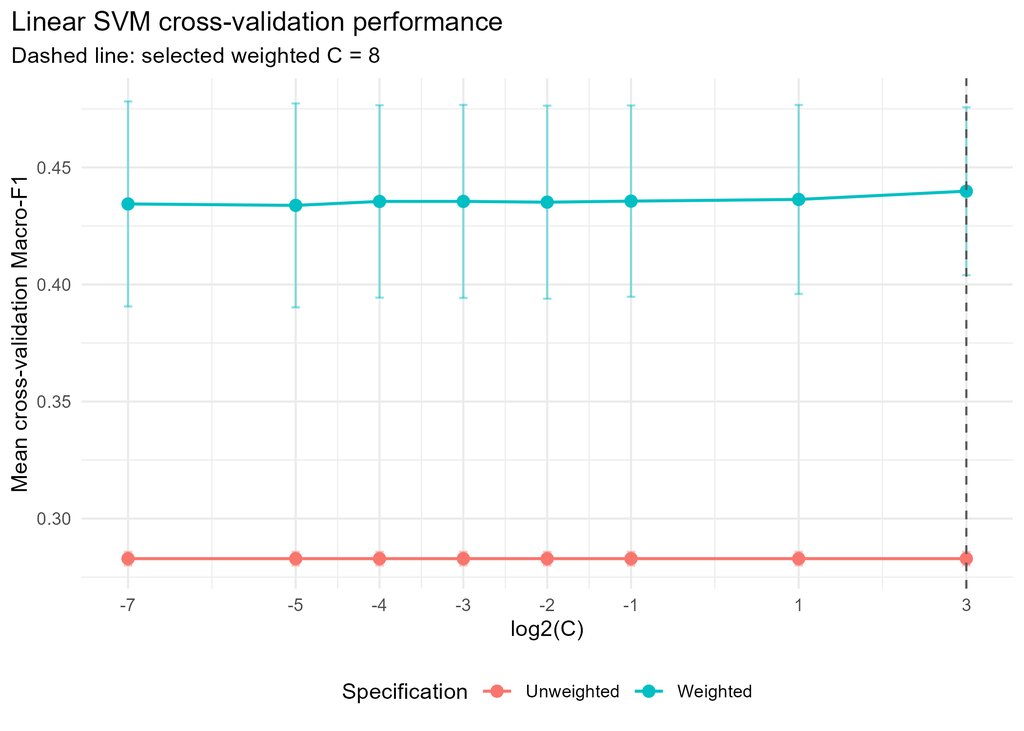

Linear SVM tuning on the common C grid.

```r
knitr::include_graphics('../figures/models/svm_linear_tuning.png')
```